# All Assignment Problems for Cohort 1 (11th Grade)

# Problem 83-2

*Supplemental problems; 30% of assignment grade; 60 minutes estimate*

### PART 1

*Location*: `assignment-problems`

Skim the following section of http://learnyouahaskell.com/syntax-in-functions.

> Hello recursion

> Maximum awesome

Pay attention to the following example, especially:

```
maximum' :: (Ord a) => [a] -> a
maximum' [] = error "maximum of empty list"
maximum' [x] = x
maximum' (x:xs)
    | x > maxTail = x
    | otherwise = maxTail
    where maxTail = maximum' xs
```

Create a **Haskell** file `SmallestPositive.hs` and write a function `findSmallestPositive` that takes a list and returns the smallest positive number in the list.

The format will be similar to that shown in the `maximum'` example above.

To check your function, print `findSmallestPositive [8, 3, -1, 2, -5, 7]`. You should get a result of `2`.

**Important:** In your function `findSmallestPositve`, you will need to compare `x` to `0`, which means we must assume that not only can items `x` be ordered (`Ord`), they are also numbers (`Num`). So, you will need to have `findSmallestPositive :: (Num a, Ord a) => [a] -> a`.

**Note:** It is not necessary to put a "prime" at the end of your function name, like is shown in the example.

### PART 2

Complete these C++/Shell/SQL coding challenges and submit screenshots.

- For C++/Shell, each screenshot should include your username, the problem title, and the "Status: Accepted" indicator.
- For SQL, each screenshot should include the problem number, the successful smiley face, and your query.

**C++**

> https://www.hackerrank.com/challenges/c-tutorial-class/problem
- You can read more about C++ classes here: https://www.programiz.com/cpp-programming/object-class
- If you get stuck for more than 20 minutes, post on Slack to get help

**Shell**

> https://www.hackerrank.com/challenges/text-processing-tail-1/problem

> https://www.hackerrank.com/challenges/text-processing-tail-2/problem

> https://www.hackerrank.com/challenges/text-processing-in-linux---the-middle-of-a-text-file/problem
- Helpful templates:

  ```
  tail -n 11 # Last 11 lines
  tail -c 20 # Last 20 characters
  head -n 10 | tail -n 5 # Get the first 10 lines, and then
                         get the last 5 lines of those
                         10 lines (so the final result is
                         lines 6-10)
  ```

- These problems are all one-liners. If you find yourself spending more than a couple minutes on these, be sure to ask for help.

**SQL**

> https://sqlzoo.net/wiki/The_JOIN_operation (queries 4,5,6)

# Problem 83-3

*Review; 10% of assignment grade; 15 minutes estimate*

Commit your code to GitHub. When you submit your assignment, include a link to your commit(s). **If you don't do this, your assignment will receive a grade of $0$ until you resubmit with links to your commits.**

Additionally, do the following:

- Make **2 GitHub issues** on your assigned classmate's repository (but NOT `assignment-problems`). See eurisko.us/resources/#code-reviews to determine your assigned classmate. When you submit your assignment, include the links to the issues you created.

### SUBMISSION TEMPLATE

For your submission, copy and paste your links into the following template:

```
Link to Overleaf doc: _____

Repl.it link to Haskell code: _____
Link to C++/Shell/SQL screenshots (Overleaf or Google Doc): _____

Commit link for space-empires repo: _____
Commit link for machine-learning repo: _____
Commit link for assignment-problems repo: _____

Issue 1: _____
Issue 2: _____
```

# Problem 83-4

There will be a 45-minute quiz on Friday from 8:30-9:15. It will mainly be a review of the ML algorithms we've implemented so far, and their use for modeling purposes. Know how to do the following things:

- Answer questions about similarities and differences between linear regression, logistic regression, k nearest neighbors, naive bayes, and Gini decision trees.
- Answer questions about overfitting, underfitting, training datasets, testing datasets, train-test splits.

# Problem 82-1

*Primary problems; 60% of assignment grade; 90 minutes estimate*

**a.** Schedule pair coding sessions to finish game refactoring. Once you've gotten someone else's strategy integrated, update the "Current Completion" portion of the progress sheet: https://docs.google.com/spreadsheets/d/1zUqn5OvF3_U3XJ_d25vtBiFkRB3RgSQSXNv6wga8aeI/edit?usp=sharing

- Saturday:
  - Group 1: Riley, Colby, Elijah
  - Group 2: George, David
- Sunday:
  - Group 1: Colby, David, Elijah
  - Group 2: Riley, George

**b.** Create a class `WeightedGraph` where each edge has an edge weight. Include two methods `calc_shortest_path` and `calc_distance` that accomplish the same goals as in your `Graph` class. But since this is a weighted graph, the actual algorithms for accomplishing those goals are a bit different.

[figure not shown]

```
>>> weights = {
    (0,1): 3,
    (1,7): 4,
    (7,2): 2,
    (2,5): 1,
    (5,6): 8,
    (0,3): 2,
    (3,2): 6,
    (3,4): 1,
    (4,8): 8,
    (8,0): 4
}
>>> vertex_values = ['a', 'b', 'c', 'd', 'e', 'f', 'g', 'h', 'i']
>>> weighted_graph = WeightedGraph(weights, vertex_values)

>>> weighted_graph.calc_distance(8,4)
7

>>> [weighted_graph.calc_distance(8,n) for n in range(9)]
[4, 7, 12, 6, 7, 13, 21, 11, 0]
```

# Problem 82-2

*Supplemental problems; 30% of assignment grade; 60 minutes estimate*

### PART 1

*Location*: `assignment-problems`

Skim the following section of http://learnyouahaskell.com/syntax-in-functions.

> Let it be

Pay attention to the following example, especially:

```
calcBmis :: (RealFloat a) => [(a, a)] -> [a]
calcBmis xs = [bmi | (w, h) <- xs, let bmi = w / h ^ 2, bmi >= 25.0]
```

Create a **Haskell** file `ProcessPoints.hs` and write a function `smallestDistances` that takes a list of 3-dimensional points and returns the distances of any points that are within 10 units from the origin.

### PART 2

Complete these C++/Shell/SQL coding challenges and submit screenshots.

- For C++/Shell, each screenshot should include your username, the problem title, and the "Status: Accepted" indicator.
- For SQL, each screenshot should include the problem number, the successful smiley face, and your query.

**C++**

> https://www.hackerrank.com/challenges/c-tutorial-struct/problem
- You can read more about structs here: https://www.educative.io/edpresso/what-is-a-cpp-struct
- If you get stuck for more than 10 minutes, post on Slack to get help

**Shell**

> https://www.hackerrank.com/challenges/text-processing-cut-7/problem

> https://www.hackerrank.com/challenges/text-processing-cut-8/problem

> https://www.hackerrank.com/challenges/text-processing-cut-9/problem

> https://www.hackerrank.com/challenges/text-processing-head-1/problem

> https://www.hackerrank.com/challenges/text-processing-head-2/tutorial
- Remember to check out the tutorial tabs.
- Note that if you want to start at the index `2` and then go until the end of a line, you can just omit the ending index. For example, `cut -c2-` means print characters $2$ and onwards for each line in the file.
- Also remember the template `cut -d',' -f2-4`, which means print fields $2$ through $4$ for each line the file, where the fields are separated by the delimiter `','`.
- You can also look at this resource for some examples: https://www.folkstalk.com/2012/02/cut-command-in-unix-linux-examples.html
- These problems are all one-liners. If you find yourself spending more than a couple minutes on these, be sure to ask for help.

**SQL**

> https://sqlzoo.net/wiki/SUM_and_COUNT (queries 6,7,8)

> https://sqlzoo.net/wiki/The_JOIN_operation (queries 1,2,3)

# Problem 82-3

*Review; 10% of assignment grade; 15 minutes estimate*

Commit your code to GitHub. When you submit your assignment, include a link to your commit(s). **If you don't do this, your assignment will receive a grade of $0$ until you resubmit with links to your commits.**

Additionally, do the following:

1. Make **2 GitHub issues** on your assigned classmate's repository (but NOT `assignment-problems`). See eurisko.us/resources/#code-reviews to determine your assigned classmate. When you submit your assignment, include the links to the issues you created.
2. ~Resolve an issue that has been made on your own GitHub repository. When you submit your assignment, include a link to the issue you resolved. (If you don't have any issues on any of your repositories, then you don't have to do anything, but state that this is the case when you turn in your assignment.)~ **Let's actually hold off on this bit for the next couple weeks, so that we can build up an inventory of issues on our repositories. Then, once we have an inventory of 5-10 issues to choose from each time, we can start resolving them.**

### SUBMISSION TEMPLATE

For your submission, copy and paste your links into the following template:

```
Repl.it link to WeightedGraph tests: _____
Repl.it link to Haskell code: _____
Link to C++/Shell/SQL screenshots (Overleaf or Google Doc): _____

Commit link for space-empires repo: _____
Commit link for graph repo: _____
Commit link for assignment-problems repo: _____

Issue 1: _____
Issue 2: _____
```

# Problem 81-1

*Primary problems; 60% of assignment grade; 90 minutes estimate*

**a.** If your game doesn't already do this, make it so that if a player commits an invalid move (such as moving off the grid), the game stops.

**b.** Now that we've solved a bunch of issues in our games, it's time to slow down, and focus on 1 strategy at a time.

- Schedule a pair coding session with your partner(s) below, sometime today or tomorrow. Let me know when you've scheduled it. During your session, make sure that your DumbStrategy passes their tests, and that their DumbStrategy passes your tests.
  - Riley & David
  - Elijah, Colby, & George
- Refactoring will go a lot faster if we do it synchronously in small groups, instead of doing asynchronous refactoring with the entire group. By doing small-group synchronous refactoring, it'll be easier to keep a stream of communication going until the DumbStrategy works.
- In case you need it: Probem 80-1 has templates of the game_state and the Strategy class.

**c.** Make the following adjustment to your random forest:

- In your random decision tree, create a `max_depth` parameter that stops splitting any nodes beyond the `max_depth`. For example, if `max_depth = 2`, then you would stop splitting a node once it is 2 units away from the root of the tree.
- A consequence of this is that the terminal nodes might not be pure. If a terminal node is impure, then it represents the majority class. (If there are equal amounts of each class, just choose randomly.) When you initialize the random forest, pass a max_depth parameter that, in turn, gets passed to the random decision trees.
- We've got a couple more adjustments to make, but I figured we should break up this task over multiple assignments since it's a bit of work and we've also got to keep making progress on the game refactoring.

# Problem 81-2

*Supplemental problems; 30% of assignment grade; 60 minutes estimate*

### PART 1

*Location*: `assignment-problems`

Observe the following example:

```
bmiTell :: (RealFloat a) => a -> a -> String
bmiTell weight height
    | bmi <= underweightThreshold = "The patient may be underweight. If this is the case, the patient should be recommended a higher-calorie diet."
    | bmi <= normalThreshold = "The patient may be at a normal weight."
    | otherwise = "The patient may be overweight. If this is the case, the patient should be recommended exercise and a lower-calorie diet."
    where bmi = weight / height ^ 2
          underweightThreshold = 18.5
          normalThreshold = 25.0
```

Create a **Haskell** file `RecommendClothing.hs` and write a function `recommendClothing` that takes the input `degreesCelsius`, converts it to `degreesFahrenheit` (multiply by $\dfrac{9}{5}$ and add $32$), and makes the following recommendations:

- If the temperature is $ \geq 80 \, ^\circ \textrm{F},$ then recommend to wear a shortsleeve shirt.
- If the temperature is $ > 65 \, ^\circ \textrm{F}$ but $ < 80 \, ^\circ \textrm{F},$ then recommend to wear a longsleeve shirt.
- If the temperature is $ > 50 \, ^\circ \textrm{F}$ but $ < 65 \, ^\circ \textrm{F},$ then recommend to wear a sweater.
- If the temperature is $ \leq 50 \, ^\circ \textrm{F},$ then recommend to wear a jacket.

### PART 2

Complete these C++/Shell/SQL coding challenges and submit screenshots.

- For C++/Shell, each screenshot should include your username, the problem title, and the "Status: Accepted" indicator.
- For SQL, each screenshot should include the problem number, the successful smiley face, and your query.

**C++**

> https://www.hackerrank.com/challenges/c-tutorial-strings/problem
- Note that you can slice strings like this:

  ```
  myString.substr(1, 3)
  ```

**Shell**

> https://www.hackerrank.com/challenges/text-processing-cut-2/problem

> https://www.hackerrank.com/challenges/text-processing-cut-3/problem

> https://www.hackerrank.com/challenges/text-processing-cut-4/problem

> https://www.hackerrank.com/challenges/text-processing-cut-5/problem

> https://www.hackerrank.com/challenges/text-processing-cut-6/problem
- Here are some useful templates:
  - `cut -c2-4` means print characters $2$ through $4$ for each line in the file.
  - `cut -d',' -f2-4` means print fields $2$ through $4$ for each line the file, where the fields are separated by the delimiter `','`.
- You can also look at this resource for some examples: https://www.folkstalk.com/2012/02/cut-command-in-unix-linux-examples.html
- These problems are all one-liners. If you find yourself spending more than a couple minutes on these, be sure to ask for help.

**SQL**

> https://sqlzoo.net/wiki/SUM_and_COUNT (queries 1,2,3,4,5)

# Problem 81-3

*Review; 10% of assignment grade; 15 minutes estimate*

Commit your code to GitHub. When you submit your assignment, include a link to your commit(s). **If you don't do this, your assignment will receive a grade of $0$ until you resubmit with links to your commits.**

Additionally, do the following:

1. Make **2 GitHub issues** on your assigned classmate's repository (but NOT `assignment-problems`). See eurisko.us/resources/#code-reviews to determine your assigned classmate. When you submit your assignment, include the links to the issues you created.
2. ~Resolve an issue that has been made on your own GitHub repository. When you submit your assignment, include a link to the issue you resolved. (If you don't have any issues on any of your repositories, then you don't have to do anything, but state that this is the case when you turn in your assignment.)~ **Let's actually hold off on this bit for the next couple weeks, so that we can build up an inventory of issues on our repositories. Then, once we have an inventory of 5-10 issues to choose from each time, we can start resolving them.**

### SUBMISSION TEMPLATE

For your submission, copy and paste your links into the following template:

```
Repl.it link to Haskell code: _____
Link to C++/Shell/SQL screenshots (Overleaf or Google Doc): _____

Commit link for machine-learning repo: _____
Commit link for assignment-problems repo: _____

Issue 1: _____
Issue 2: _____
```

# Problem 80-1

*Primary problems; 50% of assignment grade; 60 minutes estimate*

**a.**

**(i)** In your game state, make the following updates:

- Change `"hits"` to `"hits_left"`
- Change `"Homeworld"` to `"Colony"`
- Put another key in your game state: `game_state["players"]["home_coords"]`
- Make sure there are no strings with spaces in them -- instead, we'll use underlines
- Attack and defense tech starts at 0; movement, ship size, and shipyard tech all start at 1
- Colony ships are not affected by technology in general
- Add `"ship_size_needed"` to the `"unit_data"` key in the game state. Otherwise, the player doesn't know what ship size technology it needs before it can buy a ship.
- Change the output of `decide_purchases` to specify locations at which to build the ships, like this:

  ```
  {
    'units': [{'type': 'Scout', 'coords': (2,1)},
              {'type': 'Scout', 'coords': (2,1)},
              {'type': 'Destroyer', 'coords': (2,1)},
    'technology': ['defense', 'attack', 'attack']
  }
  ```

The updated game state is shown below:

```
game_state = {
    'turn': 4,
    'phase': 'Combat', # Can be 'Movement', 'Economic', or 'Combat'
    'round': None, # if the phase is movement, then round is 1, 2, or 3
    'player_whose_turn': 0, # index of player whose turn it is (or whose ship is attacking during battle),
    'winner': None,
    'players': [
        {'cp': 9,
        'home_coords': (6,3),
        'units': [
            {'coords': (5,10),
            'type': 'Scout',
            'hits_left': 1,
            'technology': {
                'attack': 1,
                'defense': 0,
                'movement': 3
            }},
            {'coords': (1,2),
            'type': 'Destroyer',
            'hits_left': 1,
            'technology': {
                'attack': 0,
                'defense': 0,
                'movement': 2
            }},
            {'coords': (6,0),
            'type': 'Homeworld',
            'hits_left': 2,
            'turn_created': 0
            },
            {'coords': (5,3),
            'type': 'Colony',
            'hits_left': 1,
            'turn created': 2
            }],
        'technology': {'attack': 1, 'defense': 0, 'movement': 3, 'shipsize': 1}
        },
        {'cp': 15,
        'home_coords': (0,3),
        'units': [
            {'coords': (1,2),
            'type': 'Battlecruiser',
            'hits_left': 1,
            'technology': {
                'attack': 0,
                'defense': 0,
                'movement': 1
            }},
            {'coords': (1,2),
            'type': 'Scout',
            'hits_left': 1,
            'technology': {
                'attack': 1,
                'defense': 0,
                'movement': 1
            }},
            {'coords': (5,10),
            'type': 'Scout',
            'hits_left': 1,
            'technology': {
                'attack': 1,
                'defense': 0,
                'movement': 1
            }},
            {'coords': (6,12),
            'type': 'Homeworld',
            'hits_left': 3,
            'turn_created': 0
            },
            {'coords': (5,10),
            'type': 'Colony',
            'hits_left': 3
            'turn_created': 1
            }],
        'technology': {'attack': 1, 'defense': 0, 'movement': 1, 'shipsize': 1}
    }],
    'planets': [(5,3), (5,10), (1,2), (4,8), (9,1)],
    'unit_data': {
        'Battleship': {'cp_cost': 20, 'hullsize': 3, 'shipsize_needed': 5, 'tactics': 5, 'attack': 5, 'defense': 2, 'maintenance': 3},
        'Battlecruiser': {'cp_cost': 15, 'hullsize': 2, 'shipsize_needed': 4, 'tactics': 4, 'attack': 5, 'defense': 1, 'maintenance': 2},
        'Cruiser': {'cp_cost': 12, 'hullsize': 2, 'shipsize_needed': 3, 'tactics': 3, 'attack': 4, 'defense': 1, 'maintenance': 2},
        'Destroyer': {'cp_cost': 9, 'hullsize': 1, 'shipsize_needed': 2, 'tactics': 2, 'attack': 4, 'defense': 0, 'maintenance': 1},
        'Dreadnaught': {'cp_cost': 24, 'hullsize': 3, 'shipsize_needed': 6, 'tactics': 5, 'attack': 6, 'defense': 3, 'maintenance': 3},
        'Scout': {'cp_cost': 6, 'hullsize': 1, 'shipsize_needed': 1, 'tactics': 1, 'attack': 3, 'defense': 0, 'maintenance': 1},
        'Shipyard': {'cp_cost': 3, 'hullsize': 1, 'shipsize_needed': 1, 'tactics': 3, 'attack': 3, 'defense': 0,, 'maintenance': 0},
        'Decoy': {'cp_cost': 1, 'hullsize': 0, 'shipsize_needed': 1, 'tactics': 0, 'attack': 0, 'defense': 0, 'maintenance': 0},
        'Colonyship': {'cp_cost': 8, 'hullsize': 1, 'shipsize_needed': 1, 'tactics': 0, 'attack': 0, 'defense': 0, 'maintenance': 0},
        'Base': {'cp_cost': 12, 'hullsize': 3, 'shipsize_needed': 2, 'tactics': 5, 'attack': 7, 'defense': 2, 'maintenance': 0},
    },
    'technology_data': {
        # lists containing price to purchase the next level level
        'shipsize': [0, 10, 15, 20, 25, 30],
        'attack': [20, 30, 40],
        'defense': [20, 30, 40],
        'movement': [0, 20, 30, 40, 40, 40],
        'shipyard': [0, 20, 30]
    }
}
```

The `Strategy` template is shown below:

```
class CombatStrategy:

    def __init__(self, player_index):
        self.player_index = player_index

    def will_colonize_planet(self, coordinates, game_state):
        ...
        return either True or False

    def decide_ship_movement(self, unit_index, game_state):
        ...
        return a "translation" which is a tuple representing
        the direction in which the ship moves.

        # For example, if a unit located at (1,2) wanted to
        # move to (1,1), then the translation would be (0,-1).

    def decide_purchases(self, game_state):
        ...
        return {
            'units': list of unit objects you want to buy,
            'technology': list of technology attributes you want to upgrade
        }

        # for example, if you wanted to buy 2 Scouts, 1 Destroyer,
        # upgrade defense technology once, and upgrade attack
        # technology twice, you'd return
        # {
        #    'units': [{'type': 'Scout', 'coords': (2,1)},
        #            {'type': 'Scout', 'coords': (2,1)},
        #            {'type': 'Destroyer', 'coords': (2,1)},
        #    'technology': ['defense', 'attack', 'attack']
        # }

    def decide_removal(self, game_state):
        ...
        return the unit index of the ship that you want to remove.

        for example, if you want to remove the unit at index 2,
        return 2

    def decide_which_unit_to_attack(self, combat_state, coords, attacker_index)

        # combat_state is a dictionary in the form coordinates : combat_order
        # {
        #    (1,2): [{'player': 1, 'unit': 0},
        #            {'player': 0, 'unit': 1},
        #            {'player': 1, 'unit': 1},
        #            {'player': 1, 'unit': 2}],
        #    (2,2): [{'player': 2, 'unit': 0},
        #            {'player': 3, 'unit': 1},
        #            {'player': 2, 'unit': 1},
        #            {'player': 2, 'unit': 2}]
        # }

        # attacker_index is the index of your unit, whose turn it is
        # to attack.

        ...

        return the index of the ship you want to attack in the
        combat order.

        # in the above example, if you want to attack player 1's unit 1,
        # then you'd return 2 because it corresponds to
        # combat_state['order'][2]

    def decide_which_units_to_screen(self, combat_state, coords):

        # again, the combat_state is the combat_state for the
        # particular battle

        ...

        return the indices of the ships you want to screen
        in the combat order

        # in the above example, if you are player 1 and you want
        # to screen units 1 and 2, you'd return [2,3] because
        # the ships you want to screen are
        # combat_state['order'][2] and combat_state['order'][3]

        # NOTE: FOR COMBATSTRATEGY AND DUMBSTRATEGY,
        # YOU CAN JUST RETURN AN EMPTY ARRAY
```

**(ii)** Once your game state / strategies are ready to be tested, post on #machine-learning to let your classmates know.

**(iii)** Run your classmates' strategies after they post that the strategies are ready. If there are any issues with their strategy, post on #machine-learning to let them know. I'm hoping that, possibly with a little back-and-forth fixing, we can have all the strategies working in everyone's games by the end of the long weekend.

**b.**

Create a `steepest_descent_optimizer(n)` optimizer for the 8 queens problem, which starts with the best of 100 random locations arrays, and on each iteration, repeatedly compares all possible next location arrays that result from moving one queen by one space, and chooses the one that results in the minimum cost. The algorithm will run for `n` iterations.

Some clarifications:

- By "starts with the best of 100 random locations arrays", I mean that you should start by generating 100 random locations arrays and selecting the lowest-cost array to be your initial locations array.
- There are $8$ queens, and each queen can move in one of $8$ directions (up, down, left, right, or in a diagonal direction) unless one of those directions is blocked by another queen or invalid due to being off the board.
- So, the number of possible "next location arrays" resulting from moving one queen by one space will be around $8 \times 8 = 64,$ though probably a little bit less. This means that on each iteration, you'll have to check about $64$ possible next location arrays and choose the one that minimies the cost function.
- If multiple configurations minimize the cost, randomly select one of them. If every next configuration increases the cost, then terminate the algorithm and return the current locations.

**Important:** We didn't discuss this in class, so be sure to post on Slack if you get confused on any part of this problem.

Your function should again return the following dictionary:

```
{
    'locations': array that resulted in the lowest cost,
    'cost': the actual value of that lowest cost
}
```

Print out the cost of your `steepest_descent_optimizer` for `n=10,50,100,500,1000`. Once you have those printouts, post it on Slack in the #results channel.

# Problem 80-2

*Supplemental problems; 40% of assignment grade; 60 minutes estimate*

### PART 1

*Location:* `assignment-problems/refactor_string_processing.py`

The following code is supposed to turn a string into an array. Currently, it's messy, and there's some subtle issues with the code. Clean up the code and get it to work.

Some particular things to fix are:

- Putting whitespace where appropriate
- Naming variables clearly
- Deleting any pieces of code that aren't necessary

```
string = '"alpha","beta","gamma","delta"\n1,2,3,4\n5.0,6.0,7.0,8.0'
strings = [x.split(',') for x in string.split('\n')]
length_of_string = len(string)
arr = []
for string in strings:
    newstring = []
    if len(string) > 0:
        for char in string:
            if char[0]=='"' and char[-1]=='"':
                char = char[1:]
            elif '.' in char:
                char = int(char)
            else:
                char = float(char)
            newstring.append(char)
        arr.append(newstring)
print(arr)

---

What it should print:
[['alpha', 'beta', 'gamma', 'delta'], [1, 2, 3, 4], [5.0, 6.0, 7.0, 8.0]]

What actually happens:
Traceback (most recent call last):
  File "datasets/myfile.py", line 10, in <module>
    char = int(char)
ValueError: invalid literal for int() with base 10: '5.0'
```

### PART 2

*Location*: `assignment-problems`

Skim the following section of http://learnyouahaskell.com/syntax-in-functions.

> Pattern matching

Create **Haskell** file `Fibonacci.hs` and write a function `nthFibonacciNumber` that computes the `n`th Fibonacci number, **starting with $n=0$**. Remember that the Fibonacci sequence is $0,1,1,2,3,5,8,\ldots$ where each number comes from adding the previous two.

To check your function, print `nthFibonacciNumber 20`. You should get a result of `6765`.

**Note:** This part of the section will be very useful, since it talks about how to write a recursive function.

```
factorial :: (Integral a) => a -> a
factorial 0 = 1
factorial n = n * factorial (n - 1)
```

### PART 3

Complete these C++/Shell/SQL coding challenges and submit screenshots.

- For C++/Shell, each screenshot should include your username, the problem title, and the "Status: Accepted" indicator.
- For SQL, each screenshot should include the problem number, the successful smiley face, and your query.

**C++**

> https://www.hackerrank.com/challenges/arrays-introduction/problem
- Note that when the input is in the form of numbers separated by a space, you can read it into an array:

  ```
  for (int i=0; i<n; i++) {
        cin >> a[i];
    }
  ```

  You can read the array out in a similar way.

**Shell**

> https://www.hackerrank.com/challenges/text-processing-cut-1/problem
- Tip: for the this problem, you can read input lines from a file using the following syntax:

  ```
  while read line
  do
    (your code here)
  done
  ```

  Again, be sure to check out the top-right "Tutorial" tab.

**SQL**

> https://sqlzoo.net/wiki/SELECT_within_SELECT_Tutorial (queries 9,10)

# Problem 80-3

*Review; 10% of assignment grade; 15 minutes estimate*

Commit your code to GitHub. When you submit your assignment, include a link to your commit(s). **If you don't do this, your assignment will receive a grade of $0$ until you resubmit with links to your commits.**

Additionally, do the following:

1. Make **2 GitHub issues** on your assigned classmate's repository (but NOT `assignment-problems`). See eurisko.us/resources/#code-reviews to determine your assigned classmate. When you submit your assignment, include the links to the issues you created.
2. ~Resolve an issue that has been made on your own GitHub repository. When you submit your assignment, include a link to the issue you resolved. (If you don't have any issues on any of your repositories, then you don't have to do anything, but state that this is the case when you turn in your assignment.)~ **Let's actually hold off on this bit for the next couple weeks, so that we can build up an inventory of issues on our repositories. Then, once we have an inventory of 5-10 issues to choose from each time, we can start resolving them.**

### SUBMISSION TEMPLATE

For your submission, copy and paste your links into the following template:

```
Repl.it link to Haskell code: _____
Link to C++/Shell/SQL screenshots (Overleaf or Google Doc): _____

Commit link for machine-learning repo: ____
Commit link for space-empires repo: ____

Issue 1: _____
Issue 2: _____
```

# Problem 79-1

*Primary problems; 45% of assignment grade; 90 minutes estimate*

### PART 1

Adjustments to the game...

- If you have `grid_size`, rename to `board_size`. It should be a tuple `(x,y)` instead of just 1 integer
- Updates to combat strategy:
  - `decide_purchases`, the units should be strings (not objects)
- Updates to game state:
  - Change `"location"` to `"coords"`
  - Unit types should be strings
  - Add a dictionaries `unit_data` and `technology_data`
- Person-specific corrections (if you haven't addressed these already):
  - **Colby**
    - The conventions for his shipyard/colonyship class naming are incorrect: He has an underscore, he uses something called 'movement_round' in the gamestate.
    - There are a ton of other really small naming differences in the gamestate, like a player's units vs ships Board_size vs grid_size
  - **Riley**
    - Board_size vs grid_size
    - decide_which_ship_to_attack arguments are reversed
    - combat_state is in a different format
  - **George**
    - His unit folder is called "units" (plural)
    - Shipyard and colonyship filenames don't have underscores
    - Shipyard vs ShipYard
    - coords vs pos in ship state
    - name vs type in ship state
  - **David**
    - It looks like he passes in some datastruct instead of a dictionary and accesses properties using a dot instead of square brackets.
    - He used some non-python syntax (++ increment) in his CombatStrategy
    - In decide_ship_movement he has the ship index as the attribute, which is correct, but then he uses ship.coordinates as if he is handling the object.

```
game_state = {
    'turn': 4,
    'phase': 'Combat', # Can be 'Movement', 'Economic', or 'Combat'
    'round': None, # if the phase is movement, then round is 1, 2, or 3
    'player_whose_turn': 0, # index of player whose turn it is (or whose ship is attacking during battle),
    'winner': None,
    'players': [
        {'cp': 9
        'units': [
            {'coords': (5,10),
            'type': 'Scout',
            'hits': 0,
            'technology': {
                'attack': 1,
                'defense': 0,
                'movement': 3
            }},
            {'coords': (1,2),
            'type': 'Destroyer',
            'hits': 0,
            'technology': {
                'attack': 0,
                'defense': 0,
                'movement': 2
            }},
            {'coords': (6,0),
            'type': 'Homeworld',
            'hits': 0,
            'turn_created': 0
            },
            {'coords': (5,3),
            'type': 'Colony',
            'hits': 0,
            'turn created': 2
            }],
        'technology': {'attack': 1, 'defense': 0, 'movement': 3, 'shipsize': 0}
    },
    {'cp': 15
        'units': [
        {'coords': (1,2),
        'type': 'Battlecruiser',
        'hits': 1,
        'technology': {
            'attack': 0,
            'defense': 0,
            'movement': 1
        }},
        {'coords': (1,2),
        'type': 'Scout',
        'hits': 0,
        'technology': {
            'attack': 1,
            'defense': 0,
            'movement': 1
        }},
        {'coords': (5,10),
        'type': 'Scout',
        'hits': 0,
        'technology': {
            'attack': 1,
            'defense': 0,
            'movement': 1
        }},
        {'coords': (6,12),
        'type': 'Homeworld',
        'hits': 0,
        'turn_created': 0
        },
        {'coords': (5,10),
        'type': 'Colony',
        'turn_created': 1
        }],
        'technology': {'attack': 1, 'defense': 0, 'movement': 1, 'shipsize': 1}
    }],
    'planets': [(5,3), (5,10), (1,2), (4,8), (9,1)],
    'unit_data': {
        'Battleship': {'cp_cost': 20, 'hullsize': 3, 'shipsize_needed': 5},
        'Battlecruiser': {'cp_cost': 15, 'hullsize': 2, 'shipsize_needed': 4},
        'Cruiser': {'cp_cost': 12, 'hullsize': 2, 'shipsize_needed': 3},
        'Destroyer': {'cp_cost': 9, 'hullsize': 1, 'shipsize_needed': 2},
        'Dreadnaught': {'cp_cost': 24, 'hullsize': 3, 'shipsize_needed': 6},
        'Scout': {'cp_cost': 6, 'hullsize': 1, 'shipsize_needed': 1},
        'Shipyard': {'cp_cost': 3, 'hullsize': 1, 'shipsize_needed': 1},
        'Decoy': {'cp_cost': 1, 'hullsize': 0, 'shipsize_needed': 1},
        'Colonyship': {'cp_cost': 8, 'hullsize': 1, 'shipsize_needed': 1},
        'Base': {'cp_cost': 12, 'hullsize': 3, 'shipsize_needed': 2},
    },
    'technology_data': {
        # lists containing price to purchase the next level level
        'shipsize': [10, 15, 20, 25, 30],
        'attack': [20, 30, 40],
        'defense': [20, 30, 40],
        'movement': [20, 30, 40, 40, 40],
        'shipyard': [20, 30]
    }
}
```

```
class CombatStrategy:

    def __init__(self, player_index):
        self.player_index = player_index

    def will_colonize_planet(self, coordinates, game_state):
        ...
        return either True or False

    def decide_ship_movement(self, unit_index, game_state):
        ...
        return a "translation" which is a tuple representing
        the direction in which the ship moves.

        # For example, if a unit located at (1,2) wanted to
        # move to (1,1), then the translation would be (0,-1).

    def decide_purchases(self, game_state):
        ...
        return {
            'units': list of unit objects you want to buy,
            'technology': list of technology attributes you want to upgrade
        }

        # for example, if you wanted to buy 2 Scouts, 1 Destroyer,
        # upgrade defense technology once, and upgrade attack
        # technology twice, you'd return
        # {
        #     'units': ['Scout', 'Scout', 'Destroyer'],
        #     'technology': ['defense', 'attack', 'attack']
        # }

    def decide_removal(self, game_state):
        ...
        return the unit index of the ship that you want to remove.

        for example, if you want to remove the unit at index 2,
        return 2

    def decide_which_unit_to_attack(self, combat_state, coords, attacker_index)

        # combat_state is a dictionary in the form coordinates : combat_order
        # {
        #    (1,2): [{'player': 1, 'unit': 0},
        #            {'player': 0, 'unit': 1},
        #            {'player': 1, 'unit': 1},
        #            {'player': 1, 'unit': 2}],
        #    (2,2): [{'player': 2, 'unit': 0},
        #            {'player': 3, 'unit': 1},
        #            {'player': 2, 'unit': 1},
        #            {'player': 2, 'unit': 2}]
        # }

        # attacker_index is the index of your unit, whose turn it is
        # to attack.

        ...

        return the index of the ship you want to attack in the
        combat order.

        # in the above example, if you want to attack player 1's unit 1,
        # then you'd return 2 because it corresponds to
        # combat_state['order'][2]

    def decide_which_units_to_screen(self, combat_state):

        # again, the combat_state is the combat_state for the
        # particular battle

        ...

        return the indices of the ships you want to screen
        in the combat order

        # in the above example, if you are player 1 and you want
        # to screen units 1 and 2, you'd return [2,3] because
        # the ships you want to screen are
        # combat_state['order'][2] and combat_state['order'][3]

        # NOTE: FOR COMBATSTRATEGY AND DUMBSTRATEGY,
        # YOU CAN JUST RETURN AN EMPTY ARRAY
```

### PART 2

*Location:* `machine-learning/analysis/8_queens.py`

We're going to be exploring approaches to solving the 8-queens problem on the next couple assignments.

The 8-queens problem is a challenge to place 8 queens on a chess board in a way that none can attack each other. Remember that in chess, queens can attack any piece that is on the same row, column, or diagonal. So, the 8-queens problem is to place 8 queens on a chess board so that none of them are on the same row, column, or diagonal.

**a.** Write a function `show_board(locations)` that takes a list of locations of 8 queens and prints out the corresponding board by placing periods in empty spaces and the index of the location in any space occupied by a queen.

```
>>> locations = [(0,0), (6,1), (2,2), (5,3), (4,4), (7,5), (1,6), (2,6)]
>>> show_board(locations)
0  .  .  .  .  .  .  .
.  .  .  .  .  .  6  .
.  .  2  .  .  .  7  .
.  .  .  .  .  .  .  .
.  .  .  .  4  .  .  .
.  .  .  3  .  .  .  .
.  1  .  .  .  .  .  .
.  .  .  .  .  5  .  .
```

**Tip:** To print out a row, you can first construct it as an array and then print the corresponding string, which consists of the array entries separated by two spaces:

```
>>> row_array = ['0', '.', '.', '.', '.', '.', '.', '.']
>>> row_string = '  '.join(row_array) # note that '  ' is TWO spaces
>>> print(row_string)
0  .  .  .  .  .  .  .
```

**b.** Write a function that `calc_cost(locations)` computes the "cost", i.e. the number of pairs of queens that are on the same row, column, or diagonal.

For example, in the board above, the cost is 10:

1. Queen 2 and queen 7 are on the same row
2. Queen 6 and queen 7 are on the same column
3. Queen 0 and queen 2 are on the same diagonal
4. Queen 0 and queen 4 are on the same diagonal
5. Queen 2 and queen 4 are on the same diagonal
6. Queen 3 and queen 4 are on the same diagonal
7. Queen 4 and queen 7 are on the same diagonal
8. Queen 3 and queen 7 are on the same diagonal
9. Queen 1 and queen 6 are on the same diagonal
10. Queen 3 and queen 5 are on the same diagonal

Verify that the cost of the above configuration is 10:

```
>>> calc_cost(locations)
10
```

**Tip 1:** It will be easier to debug your code if you write several helper functions -- one which takes two coordinate pairs and determines whether they're on the same row, another which determines whether they're on the same column, another which determines if they're on the same diagonal.

**Tip 2:** To check if two locations are on the same diagonal, you can compute the slope between those two points and check if the slope comes out to $1$ or $-1.$

**c.** Write a function `random_optimizer(n)` that generates `n` random `locations` arrays for the 8 queens, and returns the following dictionary:

```
{
    'locations': array that resulted in the lowest cost,
    'cost': the actual value of that lowest cost
}
```

Then, print out the cost of your `random_optimizer` for `n=10,50,100,500,1000`. Once you have those printouts, post it on Slack in the #results channel.

# Problem 79-2

*Supplemental problems; 45% of assignment grade; 60 minutes estimate*

### PART 1

*Location:* `assignment-problems/refactor_linear_regressor.py`

The following code is taken from a `LinearRegressor` class. While most of the code will technically work, there may be a couple subtle issues, and the code is difficult to read.

Refactor this code so that it is more readable. It should be easy to glance at and understand what's going on. Some particular things to fix are:

- Putting whitespace where appropriate
- Naming variables clearly
- Expanding out complicated one-liners
- Deleting any pieces of code that aren't necessary

**Important:**

- You don't have to actually run the code. This is just an exercise in improving code readability. You just need to copy and paste the code below into a file and clean it up.
- **Don't spend more than 20 min on this problem.** You should fix the things that jump out at you as messy, but don't worry about trying to make it absolutely perfect.

```
  def calculate_coefficients(self):
    final_dict = {}
    mat = [[1 for x in list(self.df.data_dict.values())[0][0]]]
    mat_dict = {}
    for key in self.df.data_dict:
      if key != self.dependent_variable:
        mat_dict[key] = self.df.data_dict[key]
    for row in range(len(mat_dict)):
      mat.append(list(self.df.data_dict.values())[row][0])
    mat = Matrix(mat)
    mat = mat.transpose()
    mat_t = mat.transpose()
    mat_mult = mat_t.matrix_multiply(mat)
    mat_inv = mat_mult.inverse()
    mat_pseudoinv = mat_inv.matrix_multiply(mat_t)
    multiplier = [[num] for num in list(self.df.data_dict.values())[1][0]]
    multiplier_mat = mat_pseudoinv.matrix_multiply(Matrix(multiplier))
    for num in range(len(multiplier_mat.elements)):
      if num == 0:
        key = 'constant'
      else:
        key = list(self.df.data_dict.keys())[num-1]
      final_dict[key] = [row[0] for row in multiplier_mat.elements][num]
    return final_dict
```

### PART 2

*Location*: `assignment-problems`

Skim the following section of http://learnyouahaskell.com/syntax-in-functions.

> Pattern matching

Create **Haskell** file `CrossProduct.hs` and write a function `crossProduct` in that takes an two input 3-dimensional tuples, `(x1,x2,x3)` and `(y1,y2,y3)` and computes the cross product.

To check your function, print `crossProduct (1,2,3) (3,2,1)`. You should get a result of `(-4,8,-4)`.

**Note:** This part of the section will be very useful:

```
addVectors :: (Num a) => (a, a) -> (a, a) -> (a, a)
addVectors (x1, y1) (x2, y2) = (x1 + x2, y1 + y2)
```

Note that the top line just states the "type" of `addVectors`. This line says that `addVectors` works with `Num`bers `a`, and it takes two inputs of the form `(a, a)` and `(a, a)` and gives an output of the form `(a, a)`. Here, `a` just stands for the type, `Num`ber.

### PART 3

Complete these C++/Shell/SQL coding challenges and submit screenshots.

- For C++/Shell, each screenshot should include your username, the problem title, and the "Status: Accepted" indicator.
- For SQL, each screenshot should include the problem number, the successful smiley face, and your query.

**C++**

> https://www.hackerrank.com/challenges/c-tutorial-pointer/problem
- Don't overthink this one. The solution is very, very short. Be sure to ask if you have trouble.

**Shell**

> https://www.hackerrank.com/challenges/bash-tutorials---arithmetic-operations/problem
- Be sure to check out the top-right "Tutorial" tab to read about the commands necessary to solve this problem.

**SQL**

> https://sqlzoo.net/wiki/SELECT_within_SELECT_Tutorial (queries 7,8)

# Problem 79-3

*Review; 10% of assignment grade; 15 minutes estimate*

Commit your code to GitHub. When you submit your assignment, include a link to your commit(s). **If you don't do this, your assignment will receive a grade of $0$ until you resubmit with links to your commits.**

Additionally, do the following:

1. Make **2 GitHub issues** on your assigned classmate's repository (but NOT `assignment-problems`). See eurisko.us/resources/#code-reviews to determine your assigned classmate. When you submit your assignment, include the links to the issues you created.
2. ~Resolve an issue that has been made on your own GitHub repository. When you submit your assignment, include a link to the issue you resolved. (If you don't have any issues on any of your repositories, then you don't have to do anything, but state that this is the case when you turn in your assignment.)~ **Let's actually hold off on this bit for the next couple weeks, so that we can build up an inventory of issues on our repositories. Then, once we have an inventory of 5-10 issues to choose from each time, we can start resolving them.**

### SUBMISSION TEMPLATE

For your submission, copy and paste your links into the following template:

```
PART 1
repl.it link for space-empires refactoring: ____
repl.it link for 8 queens: ____

PART 2
refactor_linear_regressor repl.it link: _____
Repl.it link to Haskell code: _____
Link to C++/Shell/SQL screenshots (Overleaf or Google Doc): _____

PART 3
Issue 1: _____
Issue 2: _____
```

# Problem 78-1

*Primary problems; 45% of assignment grade; 30-75 minutes estimate*

### Part 1

Make sure that Problem 77-1-a is done so that we can discuss the results next class. If you've already finished this, you can submit the same link that you did for Problem 77.

**Note: your table should have only 5 entries, exactly 1 entry for each model. For each model, you should count all the correct predictions (over all train-test splits) and divide by the total number of predictions (over all train-test splits).**

Also note that, all together, it will probably take 5 minutes to train the models on all the splits. This is because we've implemented the simplest version of a random forest that could possibly be concieved, and it's really inefficient. We will make it more efficient next time.

### Part 2

For each classmate, make a list of specific things (if any) that they have to fix in their strategies in order for them to seamlessly integrate into our game.

Next time, we will aggregate and discuss all these fixes and hopefully our strategies will integrate seamlessly after that.

# Problem 78-2

*Supplemental problems; 60% of assignment grade; 75 minutes estimate*

### PART 1

Recall the standard normal distribution:

$$ p(x) = \dfrac{1}{\sqrt{2\pi}} e^{-x^2/2} $$

Previously, you wrote a function `calc_standard_normal_probability(a,b)` using a Riemann sum with step size `0.001`.

Now, you will generalize the function:

- use an arbitrary number of `n` subintervals (the step size will be `(b-a)/n`
- allow 5 different rules for computing the sum (`"left endpoint"`, `"right endpoint"`, `"midpoint"`, `"trapezoidal"`, `"simpson"`)

The resulting function will be `calc_standard_normal_probability(a,b,n,rule)`.

**Note:** The rules are from AP Calc BC. They are summarized below for a partition $\{ x_0, x_1, \ldots, x_n \}$ and step size $\Delta x.$

$$ \begin{align*} \textrm{Left endpoint rule} &= \Delta x \left[ f(x_0) + f(x_1) + \ldots + f(x_{n-1}) \right] \\[7pt] \textrm{Right endpoint rule} &= \Delta x \left[ f(x_1) + f(x_2) + \ldots + f(x_{n}) \right] \\[7pt] \textrm{Midpoint rule} &= \Delta x \left[ f \left( \dfrac{x_0+x_1}{2} \right) + f \left( \dfrac{x_1+x_2}{2} \right) + \ldots + f\left( \dfrac{x_{n-1}+x_{n}}{2} \right) \right] \\[7pt] \textrm{Trapezoidal rule} &= \Delta x \left[ 0.5f(x_0) + f(x_1) + f(x_2) + \ldots + f(x_{n-1}) + 0.5f(x_{n}) \right] \\[7pt] \textrm{Simpson's rule} &= \dfrac{\Delta x}{3} \left[ f(x_0) + 4f(x_1) + 2f(x_2) + 4f(x_3) + 2f(x_4) + \ldots + 4f(x_{n-1}) + f(x_{n}) \right] \\[7pt] \end{align*} $$

**For each rule, estimate $P(0 \leq x \leq 1)$ by making a plot of the estimate versus the number of subintervals for the** even **numbers $n \in \{ 2, 4, 6, \ldots, 100 \}.$ The resulting graph should look something like this. Post your plot on #computation-and-modeling once you've got it.**

[figure not shown]

### PART 2

*Location*: `assignment-problems`

Skim the following section of http://learnyouahaskell.com/starting-out.

> Texas ranges I'm a list comprehension

Create Haskell file `ComplicatedList.hs` and write a function `calcList` in that takes an input number `n` and counts the number of ordered pairs `[x,y]` that satisfy $-n \leq x,y \leq n$ and $x-y \leq \dfrac{xy}{2} \leq x+y$ and $x,y \notin \{ -2, -1, 0, 1, 2 \}.$ **This function should generate a list comprehension and then count the length of that list.**

To check your function, print `calcList 50`. You should get a result of $16.$

### PART 3

Complete these C++/Shell/SQL coding challenges and submit screenshots.

> https://www.hackerrank.com/challenges/c-tutorial-for-loop/problem

> https://www.hackerrank.com/challenges/c-tutorial-functions/problem

> https://www.hackerrank.com/challenges/bash-tutorials---comparing-numbers/problem

> https://www.hackerrank.com/challenges/bash-tutorials---more-on-conditionals/problem

> https://sqlzoo.net/wiki/SELECT_within_SELECT_Tutorial (queries 4,5,6)
- For C++/Shell, each screenshot should include your username, the problem title, and the "Status: Accepted" indicator.
- For SQL, each screenshot should include the problem number, the successful smiley face, and your query.
- Here's a helpful example of some bash syntax. (*The spaces on the inside of the brackets are really important! It won't work if you remove the spaces, i.e. `[$n -gt 100]`*)

  ```
  read n
  if [ $n -gt 100 ] || [ $n -lt -100 ]
  then
    echo What a large number.
  else
    echo The number is smol.
    if [ $n -eq 13 ]
    then
        echo And it\'s unlucky!!!
    fi
  fi
  ```

### PART 4

**a.**

[figure not shown]

**b.**

[figure not shown]

- Remember that for a probability distribution $f(x),$ the cumulative distribution function (CDF) is $F(x) = P(X \leq x) = \displaystyle \int_{-\infty}^x f(x) \, \textrm dx.$
- Remember that $EX$ means $\textrm E[X].$

# Problem 78-3

*Review; 10% of assignment grade; 15 minutes estimate*

Commit your code to GitHub. When you submit your assignment, include a link to your commit(s). **If you don't do this, your assignment will receive a grade of $0$ until you resubmit with links to your commits.**

Additionally, do the following:

1. Make **2 GitHub issues** on your assigned classmate's repository (but NOT `assignment-problems`). See eurisko.us/resources/#code-reviews to determine your assigned classmate. When you submit your assignment, include the links to the issues you created.
2. ~Resolve an issue that has been made on your own GitHub repository. When you submit your assignment, include a link to the issue you resolved. (If you don't have any issues on any of your repositories, then you don't have to do anything, but state that this is the case when you turn in your assignment.)~ **Let's actually hold off on this bit for the next couple weeks, so that we can build up an inventory of issues on our repositories. Then, once we have an inventory of 5-10 issues to choose from each time, we can start resolving them.**

### SUBMISSION TEMPLATE

For your submission, copy and paste your links into the following template:

```
Commit link to machine-learning repo (if any changes were required): _____

Repl.it link to Haskell code: _____
Commit link for assignment-problems repo: _____

Link to C++/SQL screenshots (Overleaf or Google Doc): _____
Link to probability solutions (on Overleaf):

Issue 1: _____
Issue 2: _____
```

# Problem 77-1

*Primary problems; 45% of assignment grade; 75 minutes estimate*

**a.** **You'll need to do part 1 of the supplemental problem before you do this problem.**

**(i)** Download the `freshman_lbs.csv` dataset from https://people.sc.fsu.edu/~jburkardt/data/csv/csv.html, read it into a `DataFrame`, and create 5 test-train splits:

1. Testing data = first 20% of the records, training data = remaining 80%
2. Testing data = second 20% of the records, training data = remaining 80%
3. Testing data = third 20% of the records, training data = remaining 80%
4. Testing data = fourth 20% of the records, training data = remaining 80%
5. Testing data = fifth 20% of the records, training data = remaining 80%

Note that you'll need to convert the appropriate entries to numbers (instead of strings) in the dataset. There are 2 options for doing this:

- **Option 1:** don't worry about fixing the format within the `read_csv` method. Just do something like `df = df.apply('weight', lambda x: int(x))` afterwards, before you pass the dataframe into your model.
- **Option 2:** when you read in the csv, after you do the

  ```
  lines = file.read().split('\n')
  entries = [line.split(',') for line in lines]
  ```

  thing, you can loop through the entries, and if `entry[0]+entry[-1] == '""'`, then you can set `entry = entry[1:-1]` to remove the quotes. Otherwise, if `entry[0]+entry[-1] != '""'`, then you can try to do `entry = float(entry[1:-1])`.

**(ii)** For each test-train split, fit each of the following models on the training data and use it to predict the sexes on the testing data. (You are predicting sex as a function of weight and BMI, and you can just use columns corresponding to September data.)

- Decision tree using Gini split criterion
- A single random decision tree
- Random forest with 10 trees
- Random forest with 100 trees
- Random forest with 1000 trees

**(iii)** For each model, compute the accuracy (count the total number of *correct* classifications and divide by the total number of classifications). Put these results in a table in an Overleaf document.

Note that the total number of classifications should be equal to the total number of records in the dataset (you did 5 train-test splits, and each train-test split involved testing on 20% of the data).

**(iv)** Below the table, analyze the results. Did you expect these results, or did they surprise you? Why do you think you got the results you did?

**b.** For each of your classmates, copy over their `DumbStrategy` and `CombatStrategy` and run your DumbPlayer/CombatPlayer tests using **your classmate's** strategy. Fill out the following information *for each classmate:*

- Name of classmate
- When you copied over their `DumbStrategy` and ran your DumbPlayer tests, did they pass? If not, then what's the issue? Is it a problem with your game, or with their strategy class?
- When you copied over their `CombatStrategy` and ran your CombatPlayer tests, did they pass? If not, then what's the issue? Is it a problem with your game, or with their strategy class?

# Problem 77-2

*Supplemental problems; 45% of assignment grade; 75 minutes estimate*

### PART 1

In your `machine-learning` repository, create a folder `machine-learning/datasets/`. Go to https://people.sc.fsu.edu/~jburkardt/data/csv/csv.html, download the file `airtravel.csv`, and put it in your `datasets/` folder.

In Python, you can read a csv as follows:

```
>>> path_to_datasets = '/home/runner/machine-learning/datasets/'
>>> filename = 'airtravel.csv'
>>> with open(path_to_datasets + filename, "r") as file:
   print(file.read())

"Month", "1958", "1959", "1960"
"JAN",  340,  360,  417
"FEB",  318,  342,  391
"MAR",  362,  406,  419
"APR",  348,  396,  461
"MAY",  363,  420,  472
"JUN",  435,  472,  535
"JUL",  491,  548,  622
"AUG",  505,  559,  606
"SEP",  404,  463,  508
"OCT",  359,  407,  461
"NOV",  310,  362,  390
"DEC",  337,  405,  432
```

Write a `@classmethod` called `DataFrame.from_csv(path_to_csv, header=True)` that constructs a `DataFrame` from a csv file (similar to how `DataFrame.from_array(arr)` constructs the `DataFrame` from an array).

Test your method as follows:

```
>>> path_to_datasets = '/home/runner/machine-learning/datasets/'
>>> filename = 'airtravel.csv'
>>> filepath = path_to_datasets + filename
>>> df = DataFrame.from_csv(filepath, header=True)

>>> df.to_array()
[['"Month"', '"1958"', '"1959"', '"1960"'],
['"JAN"',  '340',  '360',  '417'],
['"FEB"',  '318',  '342',  '391'],
['"MAR"',  '362',  '406',  '419'],
['"APR"',  '348',  '396',  '461'],
['"MAY"',  '363',  '420',  '472'],
['"JUN"',  '435',  '472',  '535'],
['"JUL"',  '491',  '548',  '622'],
['"AUG"',  '505',  '559',  '606'],
['"SEP"',  '404',  '463',  '508'],
['"OCT"',  '359',  '407',  '461'],
['"NOV"',  '310',  '362',  '390'],
['"DEC"',  '337',  '405',  '432']]
```

### PART 2

*Location*: `assignment-problems`

Skim the following section of http://learnyouahaskell.com/starting-out.

> An intro to lists

Create Haskell file `ListProcessing.hs` and write a function `prodFirstLast` in Haskell that takes an input list `arr` and computes the product of the first and last elements of the list. Then, apply this function to the input `[4,2,8,5]`.

*Tip: use the `!!` operator and the `length` function.*

Your file will look like this:

```
prodFirstLast arr = (your code here)
main = print (prodFirstLast [4,2,8,5])
```

**Note that, to print out an integer, we use `print` instead of `putStrLn`.**

(You can also use `print` for most strings. The difference is that `putStrLn` can show non-ASCII characters like "я" whereas `print` cannot.)

Run your function and make sure it gives the desired output (which is 20).

### PART 3

**a.** Complete these introductory C++ coding challenges and submit screenshots:

> https://www.hackerrank.com/challenges/c-tutorial-basic-data-types/problem

> https://www.hackerrank.com/challenges/c-tutorial-conditional-if-else/problem

**b.** Complete these Bash coding challenges and submit screenshots:

> https://www.hackerrank.com/challenges/bash-tutorials---a-personalized-echo/problem

> https://www.hackerrank.com/challenges/bash-tutorials---the-world-of-numbers/problem

(Each screenshot should include your username, the problem title, and the "Status: Accepted" indicator.)

**c.** Complete SQL queries 1-3 here and submit screenshots:

> https://sqlzoo.net/wiki/SELECT_within_SELECT_Tutorial

(Each screenshot should include the problem number, the successful smiley face, and your query.)

### PART 4

**a.** As we will see in the near future, the *standard normal distribution* comes up A LOT in the context of statistics. It is defined as

$$ p(x) = \dfrac{1}{\sqrt{2\pi}} e^{-x^2/2}. $$

The reason why we haven't encountered it until now is that it's difficult to integrate. In practice, it's common to use a pre-computed table of values to look up probabilities from this distribution.

*The actual problem:* Write a function `calc_standard_normal_probability(a,b)` to approximate $P(a \leq X \leq b)$ for the standard normal distribution, using a Riemann sum with step size 0.001.

To check your function, print out estimates of the following probabilities:

- $P(-1 \leq x \leq 1)$
- $P(-2 \leq x \leq 2)$
- $P(-3 \leq x \leq 3)$

Your estimates should come out close to 0.68, 0.955, 0.997 respectively. (https://en.wikipedia.org/wiki/68%E2%80%9395%E2%80%9399.7_rule)

**b.**

[figure not shown]

- "CDF" stands for Cumulative Distribution Function. The CDF of a probability distribution $f(x)$ is defined as $$ F(x) = P(X \leq x) = \int_{-\infty}^x f(x) \, \textrm dx. $$
- Your answer for the CDF will be a piecewise function (3 pieces).
- $EX$ means $E[X].$

**c.**

[figure not shown]

# Problem 77-3

*Review; 10% of assignment grade; 15 minutes estimate*

Commit your code to GitHub. When you submit your assignment, include a link to your commit(s). **If you don't do this, your assignment will receive a grade of $0$ until you resubmit with links to your commits.**

Additionally, do the following:

1. Make **2 GitHub issues** on your assigned classmate's repository (but NOT `assignment-problems`). See eurisko.us/resources/#code-reviews to determine your assigned classmate. When you submit your assignment, include the links to the issues you created.
2. ~Resolve an issue that has been made on your own GitHub repository. When you submit your assignment, include a link to the issue you resolved. (If you don't have any issues on any of your repositories, then you don't have to do anything, but state that this is the case when you turn in your assignment.)~ **Let's actually hold off on this bit for the next couple weeks, so that we can build up an inventory of issues on our repositories. Then, once we have an inventory of 5-10 issues to choose from each time, we can start resolving them.**

# Problem 76-1

*Primary problems; 40% of assignment grade; 60 minutes estimate*

**a.** Create a `RandomForest` class in `machine-learning/src/random-forest` that is initialized with a value `n` that represents the number of random decision trees to use.

The `RandomForest` should have a `fit()` method and a `predict()` method, just like the `DecisionTree`.

- The `fit()` method should fit all the random decision trees.
- The `predict()` method should get a prediction from each random decision tree, and then return the prediction that occurred most frequently. (If there are multiple predictions that occurred most frequently, then choose randomly among them.)

So it should work like this:

```
rf = RandomForest(10) # random forest consisting of 10 random trees
rf.fit(df) # fit all 10 of those trees to the dataframe
rf.predict(observation) # have each of the 10 trees make a prediction, and
                        # return the majority vote of the 10 trees
```

**b.** Refactor the `combat_state` in your game.

Previously, it looked like this:

```
[
    {'location': (1,2),
    'order': [{'player': 1, 'unit': 0,},
              {'player': 0, 'unit': 1},
              {'player': 1, 'unit': 1}]
    },
    {'location': (5,10),
    'order': [{'player': 0, 'unit': 0},
              {'player': 1, 'unit': 2},
              {'player': 1, 'unit': 4}]
    }
]
```

Now, we will refactor the above into this:

```
{
    (1,2): [{'player': 1, 'unit': 0},
            {'player': 0, 'unit': 1},
            {'player': 1, 'unit': 1},
            {'player': 1, 'unit': 2}]
    (2,2): [{'player': 2, 'unit': 0},
            {'player': 3, 'unit': 1},
            {'player': 2, 'unit': 1},
            {'player': 2, 'unit': 2}]
}
```

As a result, we will also have to update the inputs to `decide_which_unit_to_attack`. Originally, the inputs were as follows:

```
decide_which_unit_to_attack(self, combat_state, attacker_index)
```

Now, we will have to include an additional input `location` as follows:

```
decide_which_unit_to_attack(self, combat_state, location, attacker_index)
```

**c.** Refactor your `decide_removals` function into a function `decide_removal` (singular, not plural) that returns the index of a single ship to remove. So, it will return a single integer instead of an array.

Then, refactor your game so that it calls `decide_removal` repeatedly until no more removals are required. This will prevent a situation in which our game crashes because a player did not remove enough ships.

```
def decide_removal(self, game_state):
        ...
        return the unit index of the ship that you want to remove.

        for example, if you want to remove the unit at index 2,
        return 2
```

# Problem 76-2

*Supplemental problems; 50% of assignment grade; 75 minutes estimate*

**PART 1**

*Location*: `assignment-problems`

Write a function `random_draw(distribution)` that draws a random number from the probability distribution. Assume that the distribution is an array such that `distribution[i]` represents the probability of drawing `i`.

Here are some examples:

- `random_draw([0.5, 0.5])` will return `0` or `1` with equal probability
- `random_draw([0.25, 0.25, 0.5])` will return `0` a quarter of the time, `1` a quarter of the time, and `2` half of the time
- `random_draw([0.05, 0.2, 0.15, 0.3, 0.1, 0.2])` will return `0` 5% of the time, `1` 20% of the time, `2` 15% of the time, `3` 30% of the time, `4` 10% of the time, and `0.2` 20% of the time.

The way to implement this is to

1. turn the distribution into a cumulative distribution,
2. choose a random number between 0 and 1, and then
3. find the index of the first value in the cumulative distribution that is greater than the random number.

```
Distribution:
    [0.05, 0.2, 0.15, 0.3, 0.1, 0.2]

Cumulative distribution:
    [0.05, 0.25, 0.4, 0.7, 0.8, 1.0]

Choose a random number between 0 and 1:
    0.77431

The first value in the cumulative distribution that is
greater than 0.77431 is 0.8.

This corresponds to the index 4.

So, return 4.
```

To test your function, generate 1000 random numbers from each distribution and ensure that their average is close to the true expected value of the distribution.

In other words, for each of the following distributions, print out the true expected value, and then print out the average of 1000 random samples.

- `[0.5, 0.5]`
- `[0.25, 0.25, 0.5]`
- `[0.05, 0.2, 0.15, 0.3, 0.1, 0.2]`

**PART 2**

*Location*: `assignment-problems`

Skim the following sections of http://learnyouahaskell.com/starting-out.

- Ready, set, go!
- Baby's first functions

Create Haskell file `ClassifyNumber.hs` and write a function `classifyNumber` in Haskell that takes an input number `x` and returns

- `"negative"` if `x` is negative
- `"nonnegative"` if `x` is nonnegative.

Then, apply this function to the input `5`.

Your file will look like this:

```
classifyNumber x = (your code here)
main = putStrLn (classifyNumber 5)
```

Now, run your function by typing the following into the command line:

```
>>> ghc --make ClassifyNumber
>>> ./ClassifyNumber
```

`ghc` is a Haskell compiler. It will compile or "make" an executable object using your `.hs` file. The command `./ClassifyNumber`. actually runs your executable object.

**PART 3**

Complete this introductory C++ coding challenge: https://www.hackerrank.com/challenges/cpp-input-and-output/problem

Submit a screenshot that includes the name of the problem (top left), your username (top right), and Status: Accepted (bottom).

[figure not shown]

**PART 4**

Complete this introductory Shell coding challenge: https://www.hackerrank.com/challenges/bash-tutorials---looping-and-skipping/problem

The following example of a `for` loop will be helpful:

```
for i in {2..10}
do
    ((n = 5 * i))
    echo $n
done
```

*Note*: You can solve this problem with just a single for loop

Again, submit a screenshot that includes the name of the problem (top left), your username (top right), and Status: Accepted (bottom), just like in part 3.

**PART 5**

Complete queries 11-14 here: https://sqlzoo.net/wiki/SELECT_from_Nobel_Tutorial

As usual, include a screenshot for each problem that includes the problem number, the successful smiley face, and your query.

**PART 6**

*Location:* Overleaf

Complete the following probability problems:

**a.**

[figure not shown]

- Use conditional probability. In other words, compute the probability that C has exactly $4$ spaces, *given* that A and B have exactly 7 spaces (together).

**b.**

[figure not shown]

- Write your answer using sigma notation or "dot dot dot" notation.

# Problem 76-3

*Review; 10% of assignment grade; 15 minutes estimate*

Commit your code to GitHub. When you submit your assignment, include a link to your commit(s). **If you don't do this, your assignment will receive a grade of $0$ until you resubmit with links to your commits.**

Additionally, do the following:

1. Make a GitHub issue on your assigned classmate's repository (but NOT `assignment-problems`). See eurisko.us/resources/#code-reviews to determine your assigned classmate. When you submit your assignment, include a link to the issue you created.
2. Resolve an issue that has been made on your own GitHub repository. When you submit your assignment, include a link to the issue you resolved. (If you don't have any issues on any of your repositories, then you don't have to do anything, but state that this is the case when you turn in your assignment.)

# Problem 75-1

**Location:** `machine-learning/src/decision_tree.py`

**Grade Weighting:** 40%

Update your `DecisionTree` to have the option to build the tree via random splits. By "random splits", I mean that the tree should randomly choose from the possible splits, and it should keep splitting until each leaf node is pure.

```
>>> dt = DecisionTree(split_metric = 'gini')
>>> dt.fit(df)
Fits the decision tree using the Gini metric

>>> dt = DecisionTree(split_metric = 'random')
>>> dt.fit(df)
Fits the decision tree by randomly choosing splits
```

# Problem 75-2

**Estimated Time:** 60 minutes

**Grade Weighting:** 40%

Submit corrections to final (put your corrections in an overleaf doc). I made a final review video that goes through each problem, available here: https://vimeo.com/496684498

For each correction, explain

1. what misunderstanding you had, and
2. how you get to the correct result.

**Important:** The majority of the misunderstandings should NOT be "I ran out of time", and when you explainhow to get to the correct result, SHOW ALL WORK.

# Problem 75-3

**Grade Weighting:** 20%

Make sure that problem 73-1 is done. In the next assignment, you will run everyone else's strategies and they will run yours as well. We should all get the same results.

# Problem 75-4

**Estimated Time:** 20 minutes

Important! If you don't do the things below, your assignment will receive a grade of zero.

1. Commit your code to GitHub. When you submit your assignment, include a link to your commit(s).
2. Make a GitHub issue on your assigned classmate's repository (but NOT `assignment-problems`). See eurisko.us/resources/#code-reviews to determine your assigned classmate. When you submit your assignment, include a link to the issue you created.
3. Resolve an issue that has been made on your own GitHub repository. When you submit your assignment, include a link to the issue you resolved.

# Problem 74-1

Wrapping up the semester...

- Read the edited version of your blog post [here](https://www.overleaf.com/read/sywhpyfkspjg  
  ). If you'd like to see any changes, post on Slack by the end of the week. Otherwise, these are going up on the website!
- Turn in any missing assignments / resubmissions / reviews / test corrections by Sunday 1/3 at the *very latest*. Finish strong! I want to give out strong grades, but I can only do that if you're up to date with all your work and you've done it well.

# Problem 74-2

Study for the final!

**Probability/Statistics**

definitions of independent/disjoint, conditional probability, mean, variance, standard deviation, covariance, how variance/covariance are related to expectation identifying probability distributions, solving for an unknown constant so that a probability distribution is valid, discrete uniform, continuous uniform, exponential, poisson, using cumulative distributions i.e. P(a <= x < b) = P(x < b) - P(x < a), KL divergence, joint distributions, basic probability computations with joint distributions, likelihood distribution, posterior/prior distributions

**Machine Learning**

pseudoinverse, fitting a linear regression, fitting a logistic regression, end behaviors of linear and logistic regression, interaction terms, using linear regression to fit the coefficients of a nonlinear function, categorical variables, naive bayes, k-nearest neighbors, decision trees, leave-one-out cross validation, underfitting/overfitting, training/testing datasets (testing datasets are also known as validation datasets)

**Algorithms**

Intelligent search (backtracking), depth-first search, breadth-first search, shortest path in a graph using breadth-first search, quicksort, computing big-O notation given a recurrence, bisection search (also known as bisection search)

**Simulation**

euler estimation, SIR model, predator-prey model, hodgkin-huxley model, translating a description into a system of differential equations

**Review**

Basic string processing (something like separate_into_words and reverse_word_order from Quiz 1), Implementing a recursive sequence, unlisting, big-O notation, matrix multiplication, converting to reduced row echelon form, determinant using rref, determinant using cofactors, why determinant using rref is faster than determinant using cofactors, inverse via augmented matrix, tally sort, merge sort (also know how to merge two sorted lists), swap sort, Newton-Raphson (i.e. the “zero of tangent line” method), gradient descent, grid search (also know how to compute cartesian product), Linked list, tree, stack, queue, converting between binary and decimal

# Problem 73-1

**Estimated Time:** 2 hours

**Points:** 20

Refactor your game so that strategies adhere to this format **exactly**. Put the strategies as separate files in `src/strategies`.

**Note:** If you have any disagreements with the strategy template below, post on Slack, and we can discuss.

```
from units.base import Base
from units.battlecruiser import Battlecruiser
from units.battleship import Battleship
from units.colony import Colony
from units.cruiser import Cruiser
from units.destroyer import Destroyer
from units.dreadnaught import Dreadnaught
from units.scout import Scout
from units.shipyard import Shipyard

class CombatStrategy:

    def __init__(self, player_index):
        self.player_index = player_index

    def will_colonize_planet(self, coordinates, game_state):
        ...
        return either True or False

    def decide_ship_movement(self, unit_index, game_state):
        ...
        return a "translation" which is a tuple representing
        the direction in which the ship moves.

        # For example, if a unit located at (1,2) wanted to
        # move to (1,1), then the translation would be (0,-1).

    def decide_purchases(self, game_state):
        ...
        return {
            'units': list of unit objects you want to buy,
            'technology': list of technology attributes you want to upgrade
        }

        # for example, if you wanted to buy 2 Scouts, 1 Destroyer,
        # upgrade defense technology once, and upgrade attack
        # technology twice, you'd return
        # {
        #     'units': [Scout, Scout, Destroyer],
        #     'technology': ['defense', 'attack', 'attack']
        # }

    def decide_removals(self, game_state):
        ...
        return a list of unit indices of ships that you want to remove.

        # for example, if you want to remove your 0th and 3rd units, you'd
        # return [0, 3]

    def decide_which_unit_to_attack(self, combat_state, attacker_index):

        # combat_state is the combat_state for the particular battle
        # being considered. It will take the form
        # {'location': (1,2),
        #     'order': [{'player': 1, 'unit': 0},
        #               {'player': 0, 'unit': 1},
        #               {'player': 1, 'unit': 1},
        #               {'player': 1, 'unit': 2}],
        # }.

        # attacker_index is the index of your unit, whose turn it is
        # to attack.

        ...

        return the index of the ship you want to attack in the
        combat order.

        # in the above example, if you want to attack player 1's unit 1,
        # then you'd return 2 because it corresponds to
        # combat_state['order'][2]

    def decide_which_units_to_screen(self, combat_state):

        # again, the combat_state is the combat_state for the
        # particular battle

        ...

        return the indices of the ships you want to screen
        in the combat order

        # in the above example, if you are player 1 and you want
        # to screen units 1 and 2, you'd return [2,3] because
        # the ships you want to screen are
        # combat_state['order'][2] and combat_state['order'][3]

        # NOTE: FOR COMBATSTRATEGY AND DUMBSTRATEGY,
        # YOU CAN JUST RETURN AN EMPTY ARRAY
```

**Note:** for technology upgrades, you'll likely have to translate between strings of technology names and technology stored as `Player` attributes. The `setattr` and `getattr` functions may be helpful:

```
>>> class Cls:
        pass
>>> obj = Cls()
>>> setattr(obj, "foo", "bar")
>>> obj.foo
'bar'
>>> getattr(obj, "foo")
'bar'
```

# Problem 73-2

**Estimated Time:** 1 hour

**Points:** 15

We need to extend our `EulerEstimator` to allow for "time delay". To do this, we'll need to keep a cache of data for the necessary variables. However, it's going to be very hard to build this if we always have to refer to variables by their index in the point. So, in this problem, we're going to update our `EulerEstimator` so that we can refer to variables by their actual names.

Refactor your `EulerEstimator` so that `x` is a dictionary instead of an array. This way, we can reference components of `x` by their actual labels rather than having to always use indices.

For example, to run our SIR model, we originally did this:

```
derivatives = [
    (lambda t, x: -0.0003*x[0]*x[1]),
    (lambda t, x: 0.0003*x[0]*x[1] - 0.02*x[1]),
    (lambda t, x: 0.02*x[1])
]
starting_point = (0, (1000, 1, 0))

estimator = EulerEstimator(derivatives, starting_point)
```

Now, we need to refactor it into this:

```
derivatives = {
    'susceptible': (lambda t, x: -0.0003*x['susceptible']*x['infected']),
    'infected': (lambda t, x: 0.0003*x['susceptible']*x['infected'] - 0.02*x['infected']),
    'recovered': (lambda t, x: 0.02*x['infected'])
}
starting_point = (0, {'susceptible': 1000, 'infected': 1, 'recovered': 0})

estimator = EulerEstimator(derivatives, starting_point)
```

Update the code in `test_euler_estimator.py` and `3_neuron_network.py` to adhere to this new convention.

When I check your submission, I'm going to check that your `EulerEstimator` has been initialized with a dictionary in each of these files, and I'm going to run each of these files to make sure that they generate the same plots as before.

# Problem 72-1

**Estimated Time:** 15 minutes

**Location:**

> `machine-learning/analysis/scatter_plot.py`

**Points:** 5

Make a scatter plot of the following dataset consisting of the points `(x, y, class)`. When the class is `A`, color the dot red. When it is `B`, color the dot blue. Post your plot on slack once you've got it.

```
data = [[2,13,'B'],[2,13,'B'],[2,13,'B'],[2,13,'B'],[2,13,'B'],[2,13,'B'],
    [3,13,'B'],[3,13,'B'],[3,13,'B'],[3,13,'B'],[3,13,'B'],[3,13,'B'],
    [2,12,'B'],[2,12,'B'],
    [3,12,'A'],[3,12,'A'],
    [3,11,'A'],[3,11,'A'],
    [3,11.5,'A'],[3,11.5,'A'],
    [4,11,'A'],[4,11,'A'],
    [4,11.5,'A'],[4,11.5,'A'],
    [2,10.5,'A'],[2,10.5,'A'],
    [3,10.5,'B'],
    [4,10.5,'A']]
```

In the plot, make the dot size proportional to the number of points at that location.

For example, to plot a data set

```
[
 (1,1),
 (2,4), (2,4),
 (3,9), (3,9), (3,9), (3,9),
 (4,16), (4,16), (4,16), (4,16), (4,16), (4,16), (4,16), (4,16), (4,16)
 ]
```

you would use the following code:

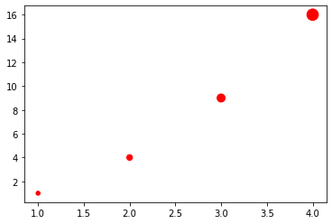

```python
import matplotlib.pyplot as plt
plt.scatter(x=[1, 2, 3, 4], y=[1, 4, 9, 16], s=[20, 40, 80, 160], c='red')
```

# Problem 72-2

**Estimated Time:** 10-60 minutes (depending on whether you've got bugs)

**Location:**

> `machine-learning/src/decision_tree.py`  
> `machine-learning/tests/test_decision_tree.py`

**Points:** 10

Refactor your `DecisionTree` so that the dataframe is passed in the `fit` method (not when the decision tree is initialized). Also, create a method to `classify` points.

**Note: Based on visually inspecting a plot of the data, I think these tests are correct, but if you get something different (that looks reasonable), post on Slack so I can check.**

```
df = DataFrame.from_array(data, columns = ['x', 'y', 'class'])

>>> dt = DecisionTree()
>>> dt.fit(df)

The tree should look like this:

                           (13A, 15B)
                            /      \
                  (y < 12.5)       (y >= 12.5)
                  (13A, 3B)        (12B)
                  /         \
          (x < 2.5)          (x >= 2.5)
          (2A, 2B)                (11A, 1B)
         /     \                  /        \
(y < 11.25)   (y >= 11.25)  (y < 10.75)     (y >= 10.75)
(2A)          (2B)          (1A, 1B)        (10A)
                            /      \
                   (x < 3.5)        (x >= 3.5)
                        (1B)        (1A)

>>> dt.root.best_split
('y', 12.5)
>>> dt.root.low.best_split
('x', 2.5)
>>> dt.root.low.low.best_split
('y', 11.25)
>>> dt.root.low.high.best_split
('y', 10.75)
>>> dt.root.low.high.low.best_split
('x', 3.5)

>>> dt.classify({'x': 2, 'y': 11.5})
'B'
>>> dt.classify({'x': 2.5, 'y': 13})
'B'
>>> dt.classify({'x': 4, 'y': 12})
'A'
>>> dt.classify({'x': 3.25, 'y': 10.5})
'B'
>>> dt.classify({'x': 3.75, 'y': 10.5})
'A'
```

# Problem 72-3

**Estimated time:** 45 minutes

**Location:** Overleaf

**Grading:** 5 points

**a.**

[figure not shown]

**b.**

[figure not shown]

- For part (a), you need to compute the probability of each "path" to the desired outcome:

$$\begin{align*} P( \geq \text{2 born in same month}) &= P( \geq \text{2 born in same month} \, | \, k=5) P(k=5) \\ &\quad + P(\geq \text{2 born in same month} \, | \, k=10) P(k=10) \\ &\quad + P(\geq \text{2 born in same month} \, | \, k=15) P(k=15) \end{align*}$$

- For part (b), start with $P(\text{k=10} \, | \, \text{2 born in same month} ),$ and use the following two equivalent statements of Bayes' theorem:

$$\begin{align*} P(A \, | \, B) &= \dfrac{P(A \textrm{ and } B)}{P(B)} \\ P(A \textrm{ and } B) &= P(B \, | \, A) P(A) \end{align*}$$

# Problem 72-4

**Estimated time:** 45 minutes

**Location:** Overleaf

**Grading:** 5 points

- Complete queries 1-10 in [SQL Zoo Module 3](https://napier.sqlzoo.net/). Take a screenshot of each successful query **(with the successful smiley face showing)** and put them in the overleaf doc.

# Problem 71-1

**Estimated Time:** 45 minutes

**Location:**

> `machine-learning/src/decision_tree.py`  
> `machine-learning/tests/test_decision_tree.py`

**Points:** 15

If you haven't already, create a `split()` method in your `DecisionTree` (not the same as the `split()` method in your `Node`!) that splits the tree at the node with highest impurity.

Then, create a `fit()` method in your `DecisionTree` that keeps on `split()`-ing until all terminal nodes are completely pure.

Assert that the following tests pass:

```
>>> df = DataFrame.from_array(
    [[1, 11, 'A'],
    [1, 12, 'A'],
    [2, 11, 'A'],
    [1, 13, 'B'],
    [2, 13, 'B'],
    [3, 13, 'B'],
    [3, 11, 'B']],
    columns = ['x', 'y', 'class']
)
>>> dt = DecisionTree(df)

# currently, the decision tree looks like this:

                      (3A, 4B)

>>> dt.split()
# now, the decision tree looks like this:

                      (3A, 4B)
                      /      \
            (y < 12.5)       (y >= 12.5)
            (3A, 1B)         (3B)

>>> dt.split()
# now, the decision tree looks like this:

                    (3A, 4B)
                    /      \
           (y < 12.5)       (y >= 12.5)
           (3A, 1B)         (3B)
         /         \
(x < 2.5)          (x >= 2.5)
(3A)               (1B)

>>> dt.root.high.row_indices
[3, 4, 5]
>>> dt.root.low.low.row_indices
[0, 1, 2]
>>> dt.root.low.high.row_indices
[6]

>>> dt = DecisionTree(df)

# currently, the decision tree looks like this:

                      (3A, 4B)

>>> dt.fit()
# now, the decision tree looks like this:

                    (3A, 4B)
                    /      \
           (y < 12.5)       (y >= 12.5)
           (3A, 1B)         (3B)
         /         \
(x < 2.5)          (x >= 2.5)
(3A)               (1B)

>>> dt.root.high.row_indices
[3, 4, 5]
>>> dt.root.low.low.row_indices
[0, 1, 2]
>>> dt.root.low.high.row_indices
[6]
```

# Problem 71-2

**Estimated time:** 45 minutes

**Location:** Overleaf

**Grading:** 10 points

- Complete queries 6-13 in [SQL Zoo Module 2](https://napier.sqlzoo.net/). Take a screenshot of each successful query **(with the successful smiley face showing)** and put them in the overleaf doc.

# Problem 71-3

**Estimated time:** 45 minutes

**Location:** Overleaf

**Grading:** 10 points

(Taken from *Introduction to Probability: Statistics and Random Processes* by Hossein Pishro-Nik)

**a.**

[figure not shown]

**b.**

[figure not shown]

**c.**

[figure not shown]

# Problem 70-1

**Estimated time:** 60 min

**Grading:** 10 points

**Locations:**

> `machine-learning/src/leave_one_out_cross_validator.py`  
> `machine-learning/tests/test_leave_one_out_cross_validator.py`

Write a class `LeaveOneOutCrossValidator` that computes `percent_accuracy` (also known as "leave-one-out cross validation") for any input classifier. For a refresher, see problem 58-1.

Assert that `LeaveOneOutCrossValidator` passes the following tests:

```
>>> df = the cookie dataset that's in test_k_nearest_neighbors_classifier.py
>>> knn = KNearestNeighborsClassifier(k=5)

>>> cv = LeaveOneOutCrossValidator(knn, df, prediction_column='Cookie Type')
    [ Note: under the hood, the LeaveOneOutCrossValidator should
      create a leave_one_out_df and do
      knn.fit(leave_one_out_df, prediction_column='Cookie Type') ]

>>> cv.accuracy()
0.7894736842105263 (Updated!)

Note: the following is included to help you debug.
Row 0 -- True Class is Shortbread; Predicted Class was Shortbread
Row 1 -- True Class is Shortbread; Predicted Class was Shortbread
Row 2 -- True Class is Shortbread; Predicted Class was Shortbread
Row 3 -- True Class is Shortbread; Predicted Class was Shortbread
Row 4 -- True Class is Sugar; Predicted Class was Sugar
Row 5 -- True Class is Sugar; Predicted Class was Sugar
Row 6 -- True Class is Sugar; Predicted Class was Sugar
Row 7 -- True Class is Sugar; Predicted Class was Shortbread
Row 8 -- True Class is Sugar; Predicted Class was Shortbread
Row 9 -- True Class is Sugar; Predicted Class was Sugar
Row 10 -- True Class is Fortune; Predicted Class was Fortune (Updated!)
Row 11 -- True Class is Fortune; Predicted Class was Fortune
Row 12 -- True Class is Fortune; Predicted Class was Fortune
Row 13 -- True Class is Fortune; Predicted Class was Shortbread
Row 14 -- True Class is Fortune; Predicted Class was Fortune (Updated!)
Row 15 -- True Class is Shortbread; Predicted Class was Sugar
Row 16 -- True Class is Shortbread; Predicted Class was Shortbread
Row 17 -- True Class is Shortbread; Predicted Class was Shortbread
Row 18 -- True Class is Shortbread; Predicted Class was Shortbread

>>> accuracies = []
>>> for k in range(1, len(data)-1):
>>>    knn = KNearestNeighborsClassifier(k)
>>>    cv = LeaveOneOutCrossValidator(knn, df, prediction_column='Cookie Type')
>>>    accuracies.append(cv.accuracy())

>>> accuracies
 [0.5789473684210527,
 0.5789473684210527, #(Updated!)
 0.5789473684210527,
 0.5789473684210527,
 0.7894736842105263, #(Updated!)
 0.6842105263157895,
 0.5789473684210527,
 0.5789473684210527, #(Updated!)
 0.6842105263157895, #(Updated!)
 0.5263157894736842,
 0.47368421052631576, #(Updated!)
 0.42105263157894735,
 0.42105263157894735, #(Updated!)
 0.3684210526315789, #(Updated!)
 0.3684210526315789, #(Updated!)
 0.3684210526315789, #(Updated!)
 0.42105263157894735]
```

# Problem 70-2

**Estimated time:** 45 minutes

**Grading:** 10 points

**Location:** Overleaf

Suppose you are a mission control analyst who is looking down at an enemy headquarters through a satellite view, and you want to get an estimate of how many tanks they have. Most of the headquarters is hidden, but you notice that near the entrance, there are four tanks visible, and these tanks are labeled with the numbers $52, 30, 68, 7.$ So, you assume that they have $N$ tanks that they have labeled with numbers from $1$ to $N.$

Your commander asks you for an estimate: **with $95\%$ certainty, what's the max number of tanks they have? Be sure to show your work.**

In this problem, you'll answer that question using the same process that you used in Problem 41-1. **[See here](https://eurisko.us/files/all_problems_iteration_2.html#Problem-35-1)** for some additional clarifications that were added to this problem when it was given to the Computation & Modeling class.

# Problem 70-3

**Estimated time:** 30 minutes

**Grading:** 5 points

**Location:** Overleaf

**a.**

[figure not shown]

**b.**

[figure not shown]

**c.**

[figure not shown]

# Problem 69-1

**Grading:** 10 points

**George & David,** this will be a catch-up problem for you guys. You guys are missing a handful of recent assignments, and there are some key problems that serve as foundations for future problems. These are the key problems: **67-1, 66-1, 62-1 (in that order of importance).**

- Your task for this assignment is to complete and submit those problems.

**Colby,** this is also a catch-up problem for you -- your task is to complete **68-1**.

**Eli & Riley** you'll get 10 points for this problem because you're up-to-date.

# Problem 69-2

**Grading:** extra credit (you can get 200% on this assignment)

**Location:** `assignment-problems/sudoku_solver.py`

Use "intelligent search" to solve the following mini sudoku puzzle. Fill in the grid so that every row, every column, and every 3x2 box contains the digits 1 through 6.

For a refresher on "intelligent search", see problem 44-1.

[figure not shown]

Format your output so that when your code prints out the result, it prints out the result in the shape of a sudoku puzzle:

```
-----------------
| . . 4 | . . . |
| . . . | 2 3 . |
-----------------
| 3 . . | . 6 . |
| . 6 . | . . 2 |
-----------------
| . 2 1 | . . . |
| . . . | 5 . . |
-----------------
```

# Problem 68-1

**Estimated Time:** 2-3 hours

**Location:**

> `machine-learning/src/decision_tree.py`  
> `machine-learning/tests/test_decision_tree.py`

**Points:** 15

In this problem, you will create the first iteration of a class `DecisionTree` that builds a decision tree by repeatedly looping through all possible splits and choosing the split with the highest "goodness of split".

We will use the following simple dataset:

[output not shown]

For this dataset, "all possible splits" mean all midpoints between distinct entries in sorted data columns.

- The sorted distinct entries of `x` are 1, 2, 3.
- The sorted distinct entries of `y` are 11, 12, 13.

So, "all possible splits" are `x=1.5, x=2.5, y=11.5, y=12.5.`

**Assert that the following tests pass. Note that you will need to create a `Node` class for the nodes in your decision tree.**

```
>>> df = DataFrame.from_array(
    [[1, 11, 'A'],
    [1, 12, 'A'],
    [2, 11, 'A'],
    [1, 13, 'B'],
    [2, 13, 'B'],
    [3, 13, 'B'],
    [3, 11, 'B']],
    columns = ['x', 'y', 'class']
)
>>> dt = DecisionTree(df)

>>> dt.root.row_indices
[0, 1, 2, 3, 4, 5, 6] # these are the indices of data points in the root node

>>> dt.root.class_counts
{
    'A': 3,
    'B': 4
}

>>> dt.root.impurity
0.490 # rounded to 3 decimal places

>>> dt.root.possible_splits.to_array()
# dt.possible_splits is a dataframe with columns
# ['feature', 'value', 'goodness of split']
# Note: below is rounded to 3 decimal places

[['x', 1.5,  0.085],
 ['x', 2.5,  0.147],
 ['y', 11.5, 0.085],
 ['y', 12.5, 0.276]]

>>> dt.root.best_split
('y', 12.5)

>>> dt.root.split()
# now, the decision tree looks like this:

                      (3A, 4B)
                      /      \
            (y < 12.5)       (y >= 12.5)
            (3A, 1B)         (3B)

# "low" refers to the "<" child node
# "high" refers to the ">=" child node
>>> dt.root.low.row_indices
[0, 1, 2, 6]
>>> dt.root.high.row_indices
[3, 4, 5]

>>> dt.root.low.impurity
0.375
>>> dt.root.high.impurity
0

>>> dt.root.low.possible_splits.to_array()

[['x', 1.5,  0.125],
 ['x', 2.5,  0.375],
 ['y', 11.5, 0.042]]

>>> dt.root.low.best_split
('x', 2.5)

>>> dt.root.low.split()
# now, the decision tree looks like this:

                    (3A, 4B)
                    /      \
           (y < 12.5)       (y >= 12.5)
           (3A, 1B)         (3B)
         /         \
(x < 2.5)          (x >= 2.5)
(3A)               (1B)

>>> dt.root.low.low.row_indices
[0, 1, 2]
>>> dt.root.low.high.row_indices
[6]

>>> dt.root.low.low.impurity
0
>>> dt.root.low.high.impurity
0
```

# Problem 67-1

**Estimated time:** 0-10 hours (?)

**Grading:** 1,000,000,000 points (okay, not actually that many, but this is IMPORTANT because we need to get our game working for the opportunity with Caltech)

Problem 59-2 was to refactor the `DumbPlayer` tests to use the game state, and make sure they pass. If you haven't completed this yet, you'll need to do that before starting on this problem.

This problem involves refactoring the way we structure players. Currently, we have a class `DumbPlayer` that does everything we'd expect from a dumb player. But really, the only reason why `DumbPlayer` is dumb is that it uses a dumb strategy.

So, we are going to replace `DumbPlayer` with a class `DumbStrategy`, and refactor `Player` so that we can initialize like this:

```
>>> dumb_player_1 = Player(strategy = DumbStrategy)
>>> dumb_player_2 = Player(strategy = DumbStrategy)
>>> game = Game(dumb_player_1, dumb_player_2)
```

**a.** Write a class `DumbStrategy` in the file `src/strategies/dumb_strategy.py` that contains the strategies for following methods:

- `will_colonize_planet(colony_ship, game_state)`: returns either `True` or `False`; will be called whenever a player's colony ship lands on an uncolonized planet
- `decide_ship_movement(ship, game_state)`: returns the coordinates to which the player wishes to move their ship.
- `decide_purchases(game_state)`: returns a list of ship and/or technology types that you want to purchase; will be called during each economic round.
- `decide_removals(game_state)`: returns a list of ships that you want to remove; will be called during any economic round when your total maintenance cost exceeds your CP.
- `decide_which_ship_to_attack(attacking_ship, game_state)`: looks at the ships in the combat order and decides which to attack; will be called whenever it's your turn to attack

**b.** Refactor your class `Player` so that you can initialize a dumb player like this:

```
>>> dumb_player_1 = Player(strategy = DumbStrategy)
>>> dumb_player_2 = Player(strategy = DumbStrategy)
>>> game = Game(dumb_player_1, dumb_player_2)
```

**c.** Make sure that all your tests in `tests/test_game_state_dumb_player.py` still pass.

**d.** Write a class `CombatStrategy` in the file `src/strategies/combat_strategy.py` that contains the strategies for the same methods as `DumbStrategy`. But this time, the strategies should be the same as those that are used in `CombatPlayer`.

```
>>> combat_player_1 = Player(strategy = CombatStrategy)
>>> combat_player_2 = Player(strategy = CombatStrategy)
>>> game = Game(combat_player_1, combat_player_2)
```

# Problem 67-2

Take a look at all your assignments so far in this course. If there are any assignments with low grades, that you haven't already resubmitted, then be sure to resubmit them.

Also, if you haven't already, submit quiz corrections for all of the quizzes we've had so far!

# Problem 66-1

**Estimated time:** 45 min

**Locations:**

> `machine-learning/src/k_nearest_neighbors_classifier.py`  
> `machine-learning/tests/test_k_nearest_neighbors_classifier.py`

**Grading:** 15 points

Update your `KNearestNeighborsClassifier` so that

- `k` is defined upon initialization,
- the model is fit by calling `fit`, and passing in the data & dependent variable, and
- when we classify an observation, all we need to pass in is the observation.

Update the tests, too, and make sure they still pass.

```
>>> df = the cookie dataset that's in test_k_nearest_neighbors_classifier.py
>>> knn = KNearestNeighborsClassifier(k=5)
>>> knn.fit(df, dependent_variable='Cookie Type') # dependent_variable is the new name for prediction_column
>>> df = the observation that's in test_k_nearest_neighbors_classifier.py
>>> knn.classify(observation) # we no longer pass in k
```

# Problem 66-2

**Estimated Time:** 45 min

**Location:** Overleaf

**Grading:** 15 points

(Taken from *Introduction to Probability: Statistics and Random Processes* by Hossein Pishro-Nik)

**a.**

[figure not shown]

**b.**

[figure not shown]

**c.**

[figure not shown]

# Problem 66-3

**Estimated time:** 30 min

**Location:** Overleaf

**Grading:** 10 points

- Complete queries 1-5 in [SQL Zoo Module 2](https://napier.sqlzoo.net/). Take a screenshot of each successful query **(with the successful smiley face showing)** and put them in the overleaf doc.
- Complete Module 8 of [Sololearn's C++ Course](https://www.sololearn.com/Course/CPlusPlus/). Take a screenshot of the completed module, with your user profile showing, and put it in the overleaf doc.

# Problem 65-1

**Estimated Time:** 30 min

**Location:** Overleaf

**Grading:** 15 points

(Taken from *Introduction to Probability: Statistics and Random Processes* by Hossein Pishro-Nik)

**a.**

[figure not shown]

- Tip: for (b), compute $1-P(\textrm{complement}).$ Here, the complement is the event that you get no aces.

**b.**

[figure not shown]

- Tip: again, compute $1-P(\textrm{complement}).$

**c.**

[figure not shown]

- Remember that PMF means "probability mass function". This is just the function $P(Z=z).$
- Tip: Find the possible values of $Z,$ and then find the probabilities of those values of $Z$ occurring. Your answer will be a piecewise function: $$ P(z) = \begin{cases} \_\_\_, \, z=\_\_\_ \\ \_\_\_, \, z=\_\_\_ \\ \ldots \end{cases} $$

# Problem 65-2

**Estimated time:** 30 min

**Location:** Overleaf

**Grading:** 5 points

- Complete queries 11-15 in the [SQL Zoo](https://napier.sqlzoo.net/wiki/SELECT_names). Take a screenshot of each successful query **(with the successful smiley face showing)** and put them in the overleaf doc.
- Complete Module 7 of [Sololearn's C++ Course](https://www.sololearn.com/Course/CPlusPlus/). Take a screenshot of the completed module, with your user profile showing, and put it in the overleaf doc.

# Problem 64-1

**Estimated time:** 60 min

**Location:** `assignment-problems/quicksort.py`

**Grading:** 10 points

Previously, you wrote a variant of quicksort that involved splitting the list into two parts (one part $\leq$ the pivot, and another part $>$ the pivot), and then recursively calling quicksort on those parts.

However, this algorithm can be made more efficient by keeping everything in the same list (rather than creating two new lists). You can do this by *swapping* elements rather than breaking them out into new lists.

**Your task is to write a quicksort algorithm that uses only one list, and uses swaps to re-order elements within that list, per the quicksort algorithm. [Here is an example of how to do that.](https://www.youtube.com/watch?v=cnzIChso3cc)**

Make sure your algorithm passes the same test as the quicksort without swaps (that you did on the previous assignment).

# Problem 64-2

**Estimated time:** 30 min

**Location:** Overleaf

**Grading:** 10 points

Complete queries 1-10 in the [SQL Zoo](https://napier.sqlzoo.net/wiki/SELECT_names). [Here's a reference](https://www.w3schools.com/sql/sql_like.asp) for the LIKE operator, which will come in handy.

Take a screenshot of each successful query and put them in an overleaf doc. When a query is successful, you'll see a smiley face appear. Your screenshots should look like this:

[figure not shown]

# Problem 64-3

**Estimated Time:** 60 min

**Location:** Overleaf

**Grading:** 10 points

(Taken from *Introduction to Probability: Statistics and Random Processes* by Hossein Pishro-Nik)

**a.**

[figure not shown]

- The PMF tells you the probabilities of values of $X.$ For example, from the PMF, we have $P(X=0) = 0.2.$ You just need to plug in these values of $X$ into the function $Y=X(X-1)(X-2)$ and sum up any probabilities for which the same value of $Y$ is obtained.

**b.**

[figure not shown]

- Remember Bayes' rule: $P(A \, | \, B) = \dfrac{P(A \cap B)}{P(B)}$

**c.**

[figure not shown]

- If two events $X$ and $Y$ are "independent", then $P(X \cap Y) = P(X) P(Y).$
- If two events $X$ and $Y$ are "disjoint", then $P(X \cap Y) = 0.$

**d.**

[figure not shown]

- Try setting up a system of equations.

# Problem 64-4

**Estimated Time:** 15 min

**Location:** Overleaf

**Grading:** 5 points

(Taken from *Introduction to Statistical Learning*)

This problem is VERY similar to the test/train analysis you did in the previous assignment. But this time, you don't have to actually code up anything. You just have to use the concepts of overfitting and underfitting to justify your answers.

[figure not shown]

# Problem 63-1

**Grading:** 20 points

(Taken from *Introduction to Probability: Statistics and Random Processes* by Hossein Pishro-Nik)

**a.**

[figure not shown]

**b.**

[figure not shown]

- This problem involves summing up probabilities over all possible paths that lead to a desired outcome. An easy way to do this is to use a [tree diagram](https://www.mathsisfun.com/data/probability-tree-diagrams.html).

**c.**

[figure not shown]

**d.**

[figure not shown]

- Note: "with replacement" means that each time a ball is drawn, it is put back in for the next draw. So, it would be possible to draw the same ball more than once.

**e.**

[figure not shown]

- Note: "without replacement" means that each time a ball is drawn, it is NOT put back in for the next draw. So, it would NOT be possible to draw the same ball more than once.

**f.**

[figure not shown]

- Note: CDF stands for "Cumulative Distribution Function" and is defined as $\textrm{CDF}(x) = P(X \leq x).$

**g.**

[figure not shown]

# Problem 63-2

**Grading:** 5 points

- Complete Module 6 of [Sololearn's C++ Course](https://www.sololearn.com/Course/CPlusPlus/). Take a screenshot of the completed module, with your user profile showing, and submit it along with the assignment.
- Complete Module 4 of [Sololearn's SQL Course](https://www.sololearn.com/Course/sql/). Take a screenshot of the completed module, with your user profile showing, and submit it along with the assignment.

# Problem 63-3

**Grading:** 5 points

Resolve the suggestions/comments on your blog post. Copy and paste everything back into Overleaf, and take a final proofread. *Read it through to make sure everything is grammatically correct and makes sense.* Submit your shareable Overleaf link along with the assignment.

# Problem 62-1

**Grading:** 10 points

Create a class `NaiveBayesClassifier` withing `machine-learning/src/naive_bayes_classifier.py` that passes the following tests. These tests should be written in `tests/test_naive_bayes_classifier.py` using assert statements.

```
>>> df = DataFrame.from_array(
    [
        [False, False, False],
        [True, True, True],
        [True, True, True],
        [False, False, False],
        [False, True, False],
        [True, True, True],
        [True, False, False],
        [False, True, False],
        [True, False, True],
        [False, True, False]
    ]
    columns = ['errors', 'links', 'scam']
)
>>> naive_bayes = NaiveBayesClassifier(df, dependent_variable='scam')

>>> naive_bayes.probability('scam', True)
0.4
>>> naive_bayes.probability('scam', False)
0.6

>>> naive_bayes.conditional_probability(('errors',True), given=('scam',True))
1.0
>>> naive_bayes.conditional_probability(('links',False), given=('scam',True))
0.25

>>> naive_bayes.conditional_probability(('errors',True), given=('scam',False))
0.16666666666666666
>>> naive_bayes.conditional_probability(('links',False), given=('scam',False))
0.5

>>> observed_features = {
    'errors': True,
    'links': False
}
>>> naive_bayes.likelihood(('scam',True), observed_features)
0.1
>>> naive_bayes.likelihood(('scam',False), observed_features)
0.05

>>> naive_bayes.classify('scam', observed_features)
True

Note: in the event of a tie, choose the dependent variable that occurred most frequently in the dataset.
```

# Problem 62-2

**Grading:** 10 points

**Location:** `assignment-problems/quicksort_without_swaps.py`

Implement a function `quicksort` that implements the variant of quicksort described here: https://www.youtube.com/watch?v=XE4VP_8Y0BU

- Note: this variant of `quicksort` is very similar to `mergesort`.

Use your function to sort the list `[5,8,-1,9,10,3.14,2,0,7,6]` (write a test with an assert statement). Choose the pivot as the rightmost entry.

# Problem 62-3

**Grading:** 10 points

**Location:** Writeup in Overleaf; code in `machine-learning/analysis/assignment_62.py`

**Watch this video FIRST:** https://youtu.be/EuBBz3bI-aA?t=29

**a.** Create a dataset as follows:

$$ \left\{ (x, y) \, \Bigg| \, \begin{matrix} x=0.1, 0.2, \ldots, 10 \\ y=3+0.5x^2 + \epsilon, \, \epsilon \sim \mathcal{U}(-5, 5) \end{matrix} \right\} $$

Split the dataset into two subsets:

- a *training* dataset consisting of 80% of the data points, and
- a *testing* dataset consisting of 20% of the data points.

To do this, you can randomly remove 20% of the data points from the dataset.

**b.** Fit 5 models to the data: a linear regressor, a quadratic regressor, a cubic regressor, a quartic regressor, and a quintic regressor. Compute the [residual sum of squares (RSS)](https://en.wikipedia.org/wiki/Residual_sum_of_squares) for each model on the training data. Which model is most accurate on the training data? Explain why.

**c.** Compute the RSS for each model on the *testing* data. Which model is most accurate on the testing data? Explain why.

**d.** Based on your findings, which model is the best model for the data? Justify your choice.

# Problem 61-1

**Location:** Overleaf

**Grading:** 10 points

Construct a decision tree model for the following data. Include the Gini impurity and goodness of split at each node. **You should choose the splits so as to maximize the goodness of split each time.** Also, draw a picture of the decision boundary on the graph.

[figure not shown]

# Problem 61-2

**Location:** `simulation/analysis/3-neuron-network.py`

**Grading:** 5 points

There are a couple things we need to update in our `BiologicalNeuron` and `BiologicalNeuralNetwork`, to make the model more realistic.

The first thing is that the synapse only releases neurotransmitters when a neuron has "fired". So, the voltage due to synapse inputs should not be a sum of all the raw voltages of the corresponding neurons. Instead, we should only sum the voltages that are over some threshold, say, $50 \, \textrm{mV}.$

So, our model becomes

$$\dfrac{\textrm dV}{\textrm dt} = \underbrace{\dfrac{1}{C} \left[ s(t) - I_{\text{Na}}(t) - I_{\text K}(t) - I_{\text L}(t) \right]}_\text{neuron in isolation} + \underbrace{\dfrac{1}{C} \left( \sum\limits_{\begin{matrix} \textrm{synapses from} \\ \textrm{other neurons} \\ \textrm{with } V(t) > 50 \end{matrix}} V_{\text{other neuron}}(t) \right)}_\text{interactions with other neurons}.$$

Update your `BiologicalNeuralNetwork` using the above model. The resulting graph should stay mostly the same (but this update to the model will be important when we're simulating many neurons).

# Problem 61-3

**Grading:** 5 points

Make suggestions on your assigned classmate's blog post. If anything is unclear, uninteresting, or awkwardly phrased, make a suggestion to improve it. You should the "suggesting" feature of Google Docs and type in how you would rephrase or rewrite the particular portions.

Be sure to look for and correct any grammar mistakes as well. This is the second round of review, so I'm expecting there to be **NO** grammar mistakes whatsoever after you're done reviewing.

- Riley: review [Colby](https://docs.google.com/document/d/1ZCgmAeP3gLiKEXkz34678WTNI1OODbYgYdc1U0n-VO4/edit?usp=sharing)'s
- Elijah: review [David](https://docs.google.com/document/d/1qfYpVkRc9SicJT15BGraOB0tih9WZyU_d0wqJRANhsU/edit?usp=sharing)'s
- George: review [Elijah](https://docs.google.com/document/d/17F_j-8rVYDJDWSApa-yq0EDh7xjaul7RiQXw66UHgJc/edit?usp=sharing)'s
- Colby: review [Riley](https://docs.google.com/document/d/1q8rrOdbsFLKCCPW-z4GlSKjRmx-iJdUYRoj76alWvN4/edit?usp=sharing)'s
- David: review [George](https://docs.google.com/document/d/1eqWhCZx_DIzHTk1ewnWNggPlgSUfjkOlwQ_FRRu8sdg/edit?usp=sharing)'s

# Problem 61-4

**Location:** Overleaf

**Grading:** 5 points

(Taken from *Introduction to Probability: Statistics and Random Processes* by Hossein Pishro-Nik)

**a.**

[figure not shown]

**b.**

[figure not shown]

# Problem 61-5

**Grading:** 5 points

Complete Module 3 of [Sololearn's SQL Course](https://www.sololearn.com/Course/SQL/). Take a screenshot of the completed module, with your user profile showing, and submit it along with the assignment.

# Problem 60-1

**Location:** Overleaf

**Grading:** 5 points

For two positive functions $f(n)$ and $g(n),$ we say that $f = O(g)$ if

$$ \lim\limits_{n \to \infty} \dfrac{f(n)}{g(n)} < \infty, $$

or equivalently, there exists a constant $c$ such that

$$ f(n) < c \cdot g(n) $$

for all $n.$

Using the definition above, prove the following:

**a.** $3n^2 + 2n + 1 = O(n^2).$

**b.** If $O(f + g) = O(\max(f,g)).$

- Note: in your proof, you should show that if $h = O(f+g),$ then $h = O(\max(f,g)).$

**c.** $O(f) \cdot O(g) = O(f \cdot g).$

- Note: in your proof, you should show that if $x = O(f)$ and $y=O(g)$ and $h = O(f \cdot g),$ then $x \cdot y = O(h)$

**d.** If $f = O(g)$ and $g = O(h)$ then $f = O(h).$

# Problem 60-2

**Location:** Overleaf

**Grading:** 5 points

(Taken from *Introduction to Probability: Statistics and Random Processes* by Hossein Pishro-Nik)

**a.**

[figure not shown]

**b.**

[figure not shown]

- **Check:** you should get a result of $0.1813.$ If you get stuck, then [here's a link](https://math.stackexchange.com/questions/193099/conditional-probabilities-involving-the-exponential-distribution/193130) to a similar example, worked out.

**c.**

[figure not shown]

- **Check:** you should get a result of $1/4.$ Remember the [triangle inequality](https://en.wikipedia.org/wiki/Triangle_inequality)! And remember that you can visualize this problem geometrically:

[figure not shown]

# Problem 60-3

**Location:** Overleaf

**Grading:** 5 points

(Taken from *Introduction to Statistical Learning*)

**IMPORTANT:**

- For part (a), write out the model for salary of a male in this dataset, and the model for salary of a female in this dataset, and use these models to justify your answer.
- Perhaps counterintuitively, question (c) is false. I want you to provide a thorough explanation of why this is by coming up with a situation in which there would be a significant interaction, but the interaction term is small.

[figure not shown]

# Problem 60-4

**Grading:** 5 points

- Complete Module 5 of [Sololearn's C++ Course](https://www.sololearn.com/Course/CPlusPlus/). Take a screenshot of the completed module, with your user profile showing, and submit it along with the assignment.
- Complete Module 2 of [Sololearn's SQL Course](https://www.sololearn.com/Course/SQL/). Take a screenshot of the completed module, with your user profile showing, and submit it along with the assignment.

# Problem 60-5

**Grading:** 5 points (if you've completed these things already, then you get 5 points free)

- Resolve any comments/suggestions in your blog post Google Doc
- Catch up on any problems you haven't fully completed: `BiologicalNeuralNetwork`, `DumbPlayer` tests, `percent_correct` with `KNearestNeighborsClassifier`

# Problem 59-1

**Location:** Overleaf

**Grading:** 10 points

Construct a decision tree model for the following data, using the splits shown.

[figure not shown]

Remember that the formula for Gini impurity for a group with class distribution $\vec p$ is

$$ G(\vec p) = \sum_i p_i (1-p_i) $$

and that the "goodness-of-split" is quantified as

$$ \text{goodness} = G(\vec p_\text{pre-split}) - \sum_\text{post-split groups} \dfrac{N_\text{group}}{N_\text{pre-split}} G(\vec p_\text{group}). $$

See the updated [Eurisko Assignment Template](https://www.overleaf.com/read/wjmgkxpccvpj) for an example of constructing a decision tree in latex for a graph with given splits.

- Be sure to include the class counts, impurity, and goodness of split at each node
- Be sure to label each edge with the corresponding decision criterion.

[This resource may also be helpful for reference.](https://w3.cs.jmu.edu/spragunr/CS444/activities/trees_bagging/decision_trees.pdf)

# Problem 59-2

**Grading:** 10 points (5 points for writing tests, 5 points for passing tests)

Revise `tests/test_dumb_player.py`, so that it uses the actual game state. You can refer to Problem 23-3 for the tests.

For example, the first test is as follows:

```
At the end of Turn 1 Movement Phase:
    Player 0 has 3 scouts at (4,0)
    Player 1 has 3 scouts at (4,4)
```

Phrased in terms of the game state, we could write the test as

```
game_state = game.generate_state()
player_0_scout_locations = [u.location for u in game_state.players[0].units if unit.type == Scout]
player_1_scout_locations = [u.location for u in game_state.players[1].units if unit.type == Scout]
assert set(player_0_scout_locations) == set([(4,0), (4,0), (4,0)])
assert set(player_1_scout_locations) == set([(4,4), (4,4), (4,4)])
```

Given the refactoring that we've been doing, your tests might not run successfully the first time. **But don't spend all your time on this problem only. If your tests don't pass, then make sure to complete all the other problems in this assignment before you start debugging your game.**

# Problem 59-3

**Grading:** 10 points

Make suggestions on your assigned classmate's blog post. If anything is unclear, uninteresting, or awkwardly phrased, make a suggestion to improve it. You should the "suggesting" feature of Google Docs and type in how you would rephrase or rewrite the particular portions.

Be sure to look for and correct any grammar mistakes as well. You'll be graded on how thorough your suggestions are. Everyone should be making plenty of suggestions (there's definitely at least 10 suggestions to be made on everyone's drafts).

- Elijah: review [Colby](https://docs.google.com/document/d/1ZCgmAeP3gLiKEXkz34678WTNI1OODbYgYdc1U0n-VO4/edit?usp=sharing)'s
- Riley: review David's
- George: review [Riley](https://docs.google.com/document/d/1q8rrOdbsFLKCCPW-z4GlSKjRmx-iJdUYRoj76alWvN4/edit?usp=sharing)'s
- David: review [George](https://docs.google.com/document/d/1eqWhCZx_DIzHTk1ewnWNggPlgSUfjkOlwQ_FRRu8sdg/edit?usp=sharing)'s
- Colby: review [Elijah](https://docs.google.com/document/d/1F0xGxBa7DUq3X9SFutmtrryRjx4ddxNFCM8hS9UrGBs/edit?usp=sharing)'s

# Problem 59-4

**Grading:** 5 points

- Complete Module 4 of [Sololearn's C++ Course](https://www.sololearn.com/Course/CPlusPlus/). Take a screenshot of the completed module, with your user profile showing, and submit it along with the assignment.
- Complete Module 1 of [Sololearn's SQL Course](https://www.sololearn.com/Course/SQL/). Take a screenshot of the completed module, with your user profile showing, and submit it along with the assignment.

# Problem 58-1

**Grading:** 10 points

Recall the following cookie dataset (that has been augmented with some additional examples):

```
['Cookie Type' ,'Portion Eggs','Portion Butter','Portion Sugar','Portion Flour' ]
[['Shortbread'  ,     0.14     ,       0.14     ,      0.28     ,     0.44      ],
['Shortbread'  ,     0.10     ,       0.18     ,      0.28     ,     0.44      ],
['Shortbread'  ,     0.12     ,       0.10     ,      0.33     ,     0.45      ],
['Shortbread'  ,     0.10     ,       0.25     ,      0.25     ,     0.40      ],
['Sugar'       ,     0.00     ,       0.10     ,      0.40     ,     0.50      ],
['Sugar'       ,     0.00     ,       0.20     ,      0.40     ,     0.40      ],
['Sugar'       ,     0.02     ,       0.08     ,      0.45     ,     0.45      ],
['Sugar'       ,     0.10     ,       0.15     ,      0.35     ,     0.40      ],
['Sugar'       ,     0.10     ,       0.08     ,      0.35     ,     0.47      ],
['Sugar'       ,     0.00     ,       0.05     ,      0.30     ,     0.65      ],
['Fortune'     ,     0.20     ,       0.00     ,      0.40     ,     0.40      ],
['Fortune'     ,     0.25     ,       0.10     ,      0.30     ,     0.35      ],
['Fortune'     ,     0.22     ,       0.15     ,      0.50     ,     0.13      ],
['Fortune'     ,     0.15     ,       0.20     ,      0.35     ,     0.30      ],
['Fortune'     ,     0.22     ,       0.00     ,      0.40     ,     0.38      ],
['Shortbread'  ,     0.05     ,       0.12     ,      0.28     ,     0.55      ],
['Shortbread'  ,     0.14     ,       0.27     ,      0.31     ,     0.28      ],
['Shortbread'  ,     0.15     ,       0.23     ,      0.30     ,     0.32      ],
['Shortbread'  ,     0.20     ,       0.10     ,      0.30     ,     0.40      ]]
```

When fitting our k-nearest neighbors models, we have been using this dataset to predict the type of a cookie based on its ingredient portions. We've also seen that issues can arise when $k$ is too small or too large.

**So, what is a good value of $k?$**

**a.** To explore this question, plot the function $$ y= \text{percent_correct}(k), \qquad k=1,2,3, \ldots, 16, $$ where $\text{percent_correct}(k)$ is the percentage of points in the dataset that the $k$-nearest neighbors model would classify correctly.

```
for each data point:
    1. fit a kNN model to all the data EXCEPT that data point
    2. use the kNN model to classify the data point
    3. determine whether the kNN classification matches up
       with the actual class of the data point

percent_correct = num_correct_classifications / tot_num_data_points
```

You should get the following result:

[figure not shown]

**b.** Based on what you know about what happens when $k$ is too small or too large, does the shape of your plot makes sense?

**c.** What would be an appropriate value (or range of values) of $k$ for this modeling task? Justify your answer by referring to your plot.

# Problem 58-2

**Grading:** 10 points

Get your `BiologicalNeuralNetwork` fully working. Note that there's a particular issue with defining functions within for loops that Elijah pointed out on Slack:

> Consider the following code:

> ```
> funcs = []
> for i in range(10):
>     funcs.append(lambda x: x * i)
> for f in funcs:
>     print(f(5))
> ```

> ```
> funcs = []
> for i in range(10):
>     funcs.append(lambda x, i=i: x * i)
> for f in funcs:
>     print(f(5))
> ```

So, when you're getting your derivatives, you'll need to do the following:

```
network_derivatives = []
for each neuron:

    parent_indices = indices of neurons that send synapses to neuron i

    # x is [V0, n0, m0, h0,
    #       V1, n1, m1, h1,
    #       V2, n2, m2, h2, ...]

    network_derivatives += [
        (
            lambda t, x, i=i, neuron=neuron:
                neuron.dV(t, x[4*i : (i+1)*4])
                + 1/neuron.C * sum(x[p*4] for p in parent_indices)
        ),
        (
            lambda t, x, i=i, neuron=neuron:
                neuron.dn(t, x[4*i : (i+1)*4])
        ),
        (
            lambda t, x, i=i, neuron=neuron:
                neuron.dm(t, x[4*i : (i+1)*4])
        ),
        (
            lambda t, x, i=i, neuron=neuron:
                neuron.dh(t, x[4*i : (i+1)*4])
        )
    ]
```

# Problem 58-3

**Grading:** 10 points

For blog post draft #4, I want you to do the following:

**George: Linear and Logistic Regression, Part 1: Understanding the Models**

1. Make plots of the images you wanted to include, and insert them into your post. You can use character arguments in `plt.plot()`; here's [a reference](https://matplotlib.org/2.1.2/api/_as_gen/matplotlib.pyplot.plot.html)
2. You haven't really hit on *why* the logistic model takes a sigmoid shape. You should talk about the $e^{\beta x}$ term, where $\beta$ is negative. What happens when $x$ gets really negative? What happens when $x$ gets really positive?
3. For your linear regression, you should use coefficients $\beta_0, \beta_1, \ldots$ just like you did in the logistic regression. This will help drive the point home that logistic regression is just a transformation of linear regression.
4. We're ready to move onto the text editing phase! The next time you submit your blost, put it in a Google Doc and share it with me so that I can make "suggestions" on it.

**Colby: Linear and Logistic Regression, Part 2: Fitting the Models**

1. In your explanation of the pseudoinverse, make sure to state that in most modeling contexts, our matrix $X$ is taller than it is wide, because we have lots of data points. So our matrix $X$ is usually not invertible because it is a tall rectangular matrix.
2. In your explanation of the pseudoinverse, be more careful with your language: the pseudoinverse $(\mathbf{X}^T\mathbf{X})^{-1}$ is *not* equivalent to the standard inverse $\mathbf{X}^{-1}.$ The equation $\mathbf{X} \vec \beta = \vec y$ is usually not solvable, because the standard inverse $\mathbf{X}^{-1}$ usually *does not exist.* But the pseudoinverse $(\mathbf{X}^T\mathbf{X})^{-1}$ usually does exist, and the solution $\vec \beta = (\mathbf{X}^T\mathbf{X})^{-1} \mathbf{X}^T \vec y$ minimizes the sum of squared error between the desired output $\vec y$ and the actual output $\mathbf{X} \vec \beta.$
3. Decide between bracket matrices (`bmatrix`) and parenthesis matrices (`pmatrix`). You sometiemes use `bmatrix`, and other times `pmatrix`. Choose one convention and stick to it.
4. On page 2, show the following intermediate steps (fill in the dots): $$\begin{align*} \vec \beta &= \ldots \\ \vec \beta &= \begin{pmatrix} \cdot & \cdot & \cdot \\ \cdot & \cdot & \cdot \\ \cdot & \cdot & \cdot \end{pmatrix}^{-1} \begin{pmatrix} 1 & 1 & 1 & 1 \\ 0 & 1 & 0 & 4 \\ 0 & 0 & 2 & 5 \end{pmatrix} \begin{pmatrix} 0.1 \\ 0.2 \\ 0.5 \\ 0.6 \end{pmatrix} \\ \vec \beta &= \begin{pmatrix} \cdot & \cdot & \cdot & \cdot \\ \cdot & \cdot & \cdot & \cdot \\ \cdot & \cdot & \cdot & \cdot \\ \cdot & \cdot & \cdot & \cdot \end{pmatrix} \begin{pmatrix} 0.1 \\ 0.2 \\ 0.5 \\ 0.6 \end{pmatrix} \\ \vec \beta &= \ldots \end{align*}$$
5. Remove any parts of your code that are not relevant to the blog post (even if you used them for some part of an assignment). For example, you should remove the rounding part from `apply_coeffs`.
6. Make sure your code follows the same conventions everywhere. For example, you sometimes say `coefficients`, and other times just `coeffs`. For the purposes of this blog post, we want to be as clear as possible, so always use `coefficients` instead of `coeffs`.
7. Make your code tight so that there is zero redundancy. For example, in `__init__`, the argument `ratings` is redundant because these values are already in your dataframe, and you already have a variable `prediction_column` that indicates the relevant column in your dataframe. So eliminate `ratings` from your code.
8. After you do the steps above, we're ready to move onto the text editing phase! The next time you submit your blog post, put it in a Google Doc and share it with me so that I can make "suggestions" on it.

**Riley: Linear and Logistic Regression, Part 3: Categorical Variables, Interaction Terms, and Nonlinear Transformations of Variables**

1. In the statements of your models, you need a constant term, and you need to standardize your coefficient labels and your variable names. You use different conventions in a lot of places -- sometimes you call the coefficients $a,b,c,\ldots,$ other times $c_1, c_2, c_3,\ldots,$ and other times $\beta_1,\beta_2,\beta_3,\ldots.$ Likewise, you sometimes say "beef" and "pb", while other times you say "roast beef" and "peanut butter". You need to standardize these names. I think using $\beta$'s or $c$'s for coefficients and abbreviations for variable names is preferable. So, for example, one of your equations would turn into $y = \beta_0 + \beta_1(\textrm{beef}) + \beta_2(\textrm{pb}) + \beta_3(\textrm{mayo}) + \beta_4(\textrm{jelly})$ or $y = c_0 + c_1(\textrm{beef}) + c_2(\textrm{pb}) + c_3(\textrm{mayo}) + c_4(\textrm{jelly}).$
2. After you do the steps above, we're ready to move onto the text editing phase! The next time you submit your blog post, put it in a Google Doc and share it with me so that I can make "suggestions" on it.

**David: Predator-Prey Modeling with Euler Estimation**

1. Explain this more clearly:

   > Euler estimation works by adding the derivative of an equation to each given value over and over again. This is because the derivatives are the instantaneous rates of change so we add it at each point to accurately show the the equation. Adding each point up from an equation is also equivalent to an integral.
2. Clean up your code on page 3. It's hard to tell what's going on. Put these code snippets into a single clean function, and change up the naming/structure so that it's clear what's going on. The code doesn't have to be the same as what's actually in your Euler estimator.
3. After you do the steps above, we're ready to move onto the text editing phase! The next time you submit your blog post, put it in a Google Doc and share it with me so that I can make "suggestions" on it.

**Elijah: Solving Magic Squares using Backtracking**

1. In your nested for loops, you should be using `range(1,10)` because `0` is not considered as an element of the magic square.
2. In your code snippets, you should name everything very descriptively so that it's totally obvious what things represent. For example, instead of `s = int(len(arr)**0.5)`, you could say `side_length = int(len(arr)**0.5)`.
3. After you do the steps above, we're ready to move onto the text editing phase! The next time you submit your blog post, put it in a Google Doc and share it with me so that I can make "suggestions" on it.

# Problem 57-1

**Location:** `machine-learning/src/k_nearest_neighbors_classifier.py`

**Grading:** 10 points

Create a class `KNearestNeighborsClassifier` that works as follows. **Leverage existing methods in your DataFrame class to do the brunt of the processing.**

```
>>> df = DataFrame.from_array(
    [['Shortbread'  ,     0.14     ,       0.14     ,      0.28     ,     0.44      ],
    ['Shortbread'  ,     0.10     ,       0.18     ,      0.28     ,     0.44      ],
    ['Shortbread'  ,     0.12     ,       0.10     ,      0.33     ,     0.45      ],
    ['Shortbread'  ,     0.10     ,       0.25     ,      0.25     ,     0.40      ],
    ['Sugar'       ,     0.00     ,       0.10     ,      0.40     ,     0.50      ],
    ['Sugar'       ,     0.00     ,       0.20     ,      0.40     ,     0.40      ],
    ['Sugar'       ,     0.10     ,       0.08     ,      0.35     ,     0.47      ],
    ['Sugar'       ,     0.00     ,       0.05     ,      0.30     ,     0.65      ],
    ['Fortune'     ,     0.20     ,       0.00     ,      0.40     ,     0.40      ],
    ['Fortune'     ,     0.25     ,       0.10     ,      0.30     ,     0.35      ],
    ['Fortune'     ,     0.22     ,       0.15     ,      0.50     ,     0.13      ],
    ['Fortune'     ,     0.15     ,       0.20     ,      0.35     ,     0.30      ],
    ['Fortune'     ,     0.22     ,       0.00     ,      0.40     ,     0.38      ]],
    columns = ['Cookie Type' ,'Portion Eggs','Portion Butter','Portion Sugar','Portion Flour' ]
    )
>>> knn = KNearestNeighborsClassifier(df, prediction_column = 'Cookie Type')
>>> observation = {
    'Portion Eggs': 0.10,
    'Portion Butter': 0.15,
    'Portion Sugar': 0.30,
    'Portion Flour': 0.45
}

>>> knn.compute_distances(observation)
Returns a dataframe representation of the following array:

[[0.047, 'Shortbread'],
 [0.037, 'Shortbread'],
 [0.062, 'Shortbread'],
 [0.122, 'Shortbread'],
 [0.158, 'Sugar'],
 [0.158, 'Sugar'],
 [0.088, 'Sugar'],
 [0.245, 'Sugar'],
 [0.212, 'Fortune'],
 [0.187, 'Fortune'],
 [0.396, 'Fortune'],
 [0.173, 'Fortune'],
 [0.228, 'Fortune']]

Note: the above has been rounded to 3 decimal places for ease of viewing, but you should not round yourself.

>>> knn.nearest_neighbors(observation)
Returns a dataframe representation of the following array:

[[0.037, 'Shortbread'],
 [0.047, 'Shortbread'],
 [0.062, 'Shortbread'],
 [0.088, 'Sugar'],
 [0.122, 'Shortbread'],
 [0.158, 'Sugar'],
 [0.158, 'Sugar'],
 [0.173, 'Fortune'],
 [0.187, 'Fortune'],
 [0.212, 'Fortune'],
 [0.228, 'Fortune'],
 [0.245, 'Sugar'],
 [0.396, 'Fortune']]

Note: the above has been rounded to 3 decimal places for ease of viewing, but you should not round yourself.

>>> knn.compute_average_distances(observation)

{
    'Shortbread': 0.067,
    'Sugar': 0.162,
    'Fortune': 0.239
}

Note: the above has been rounded to 3 decimal places for ease of viewing, but you should not round yourself.

>>> knn.classify(observation, k=5)
'Shortbread'

(In the case of a tie, chose whichever class has a lower average distance. If that is still a tie, then pick randomly.)
```

# Problem 57-2

**Location:** `simulation/analysis/3-neuron-network.py`

**Grading:** 15 points

**IMPORTANT UPDATE:** I'm not going to take points off if your `BiologicalNeuralNetwork` isn't fully working. I'll expect to see at least the skeleton of it written, but there's this subtle thing with lambda functions that Elijah pointed out, that we need to talk about in class tomorrow.

Create a Github repository named `simulation`, and organize the code as follows:

```
simulation/
|- src/
   |- euler_estimatory.py
   |- biological_neuron.py
   |- biological_neural_network.py
|- tests/
   |- test_euler_estimator.py
|- analysis/
   |- predator_prey.py
   |- sir_epidemiology.py
```

Rename your class `Neuron` to be `BiologicalNeuron`. (This is to avoid confusion when we create another neuron class in the context of machine learning.)

Create a class `BiologicalNeuralNetwork` to simulate a network of interconnected neurons. This class will be initialized with two arguments:

- `neurons` - a list of neurons in the network
- `synapses` - a list of "directed edges" that correspond to connections between neurons

To simulate your `BiologicalNeuralNetwork`, you will use an `EulerEstimator` where `x` is a long array of `V,n,m,h` for each neuron. So, if you are simulating 3 neurons (neurons 0,1,2), then you will be passing in $4 \times 3 = 12$ derivatives:

$$ \mathbf{x} = (V_0, n_0, m_0, h_0, V_1, n_1, m_1, h_1, V_2, n_2, m_2, h_2) $$

Note that you will have to add extra terms to the voltage derivatives represent the synapses. The updated derivative of voltage is as follows: $$\dfrac{\textrm dV}{\textrm dt} = \underbrace{\dfrac{1}{C} \left[ s(t) - I_{\text{Na}}(t) - I_{\text K}(t) - I_{\text L}(t) \right]}_\text{neuron in isolation} + \underbrace{\dfrac{1}{C} \left( \sum\limits_{\begin{matrix} \textrm{synapses from} \\ \textrm{other neurons} \end{matrix}} V_{\text{other neuron}}(t) \right)}_\text{interactions with other neurons}.$$

So, in the case of 3 neurons connected as $0 \to 1 \to 2,$ the full system of equations would be as follows:

$$\begin{align*} \dfrac{\textrm dV_0}{\textrm dt} &= \textrm{neuron_0.dV}(V_0,n_0,m_0,h_0) \\ \dfrac{\textrm dn_0}{\textrm dt} &= \textrm{neuron_0.dn}(V_0,n_0,m_0,h_0) \\ \dfrac{\textrm dm_0}{\textrm dt} &= \textrm{neuron_0.dm}(V_0,n_0,m_0,h_0) \\ \dfrac{\textrm dh_0}{\textrm dt} &= \textrm{neuron_0.dh}(V_0,n_0,m_0,h_0) \\ \dfrac{\textrm dV_1}{\textrm dt} &= \textrm{neuron_1.dV}(V_1,n_1,m_1,h_1) + \dfrac{1}{\textrm{neuron_1.C}} V_0(t) \\ \dfrac{\textrm dn_1}{\textrm dt} &= \textrm{neuron_1.dn}(V_1,n_1,m_1,h_1) \\ \dfrac{\textrm dm_1}{\textrm dt} &= \textrm{neuron_1.dm}(V_1,n_1,m_1,h_1) \\ \dfrac{\textrm dh_1}{\textrm dt} &= \textrm{neuron_1.dh}(V_1,n_1,m_1,h_1) \\ \dfrac{\textrm dV_2}{\textrm dt} &= \textrm{neuron_2.dV}(V_2,n_2,m_2,h_2) + \dfrac{1}{\textrm{neuron_2.C}} V_1(t) \\ \dfrac{\textrm dn_2}{\textrm dt} &= \textrm{neuron_2.dn}(V_2,n_2,m_2,h_2) \\ \dfrac{\textrm dm_2}{\textrm dt} &= \textrm{neuron_2.dm}(V_2,n_2,m_2,h_2) \\ \dfrac{\textrm dh_2}{\textrm dt} &= \textrm{neuron_2.dh}(V_2,n_2,m_2,h_2) \end{align*}$$

Test your `BiologicalNeuralNetwork` as follows:

```
>>> def electrode_voltage(t):
        if t > 10 and t < 11:
            return 150
        elif t > 20 and t < 21:
            return 150
        elif t > 30 and t < 40:
            return 150
        elif t > 50 and t < 51:
            return 150
        elif t > 53 and t < 54:
            return 150
        elif t > 56 and t < 57:
            return 150
        elif t > 59 and t < 60:
            return 150
        elif t > 62 and t < 63:
            return 150
        elif t > 65 and t < 66:
            return 150
        return 0

>>> neuron_0 = BiologicalNeuron(stimulus = electrode_voltage)
>>> neuron_1 = BiologicalNeuron()
>>> neuron_2 = BiologicalNeuron()
>>> neurons = [neuron_0, neuron_1, neuron_2]

>>> synapses = [(0,1), (1,2)]
The neural network resembles a directed graph:
0 --> 1 --> 2

>>> network = BiologicalNeuralNetwork(neurons, synapses)
>>> euler = EulerEstimator(
        derivatives = network.get_derivatives(),
        point = network.get_starting_point()
    )
>>> plt.plot([n/2 for n in range(160)], [electrode_voltage(n/2) for n in range(160)])
>>> euler.plot([0, 80], step_size = 0.001)
```

[figure not shown]

# Problem 57-3

**Grading:** 5 points

Complete Module 3 of [Sololearn's C++ Course](https://www.sololearn.com/Course/CPlusPlus/). Take a screenshot of the completed module, with your user profile showing, and submit it along with the assignment.

# Problem 56-1

**Location:** `machine-learning/tests/test_data_frame.py`

**Grading:** 10 points

Implement the following functionality in your `DataFrame`, and **assert that these tests pass.**

**a.** Loading an array. You'll need to use `@classmethod` for this one ([read about it here](https://stackabuse.com/pythons-classmethod-and-staticmethod-explained/)).

```
>>> columns = ['firstname', 'lastname', 'age']
>>> arr = [['Kevin', 'Fray', 5],
           ['Charles', 'Trapp', 17],
           ['Anna', 'Smith', 13],
           ['Sylvia', 'Mendez', 9]]
>>> df = DataFrame.from_array(arr, columns)
```

**b.** Selecting columns by name

```
>>> df.select_columns(['firstname','age']).to_array()
[['Kevin', 5],
['Charles', 17],
['Anna', 13],
['Sylvia', 9]]
```

**c.** Selecting rows by index

```
>>> df.select_rows([1,3]).to_array()
[['Charles', 'Trapp', 17],
['Sylvia', 'Mendez', 9]]
```

**d.** Selecting rows which satisfy a particular condition (given as a lambda function)

```
>>> df.select_rows_where(
    lambda row: len(row['firstname']) >= len(row['lastname'])
                and row['age'] > 10
    ).to_array()
[['Charles', 'Trapp', 17]]
```

**e.** Ordering the rows by given column

```
>>> df.order_by('age', ascending=True).to_array()
[['Kevin', 'Fray', 5],
['Sylvia', 'Mendez', 9],
['Anna', 'Smith', 13],
['Charles', 'Trapp', 17]]

>>> df.order_by('firstname', ascending=False).to_array()
[['Sylvia', 'Mendez', 9],
['Kevin', 'Fray', 5],
['Charles', 'Trapp', 17],
['Anna', 'Smith', 13]]
```

# Problem 56-2

**Grading:** 10 points

For blog post draft #3, I want you to do the following:

**George: Linear and Logistic Regression, Part 1: Understanding the Models**

1. Make plots of the images you wanted to include, and insert them into your post. You can use character arguments in `plt.plot()`; here's [a reference](https://matplotlib.org/2.1.2/api/_as_gen/matplotlib.pyplot.plot.html)
2. You haven't really hit on *why* the logistic model takes a sigmoid shape. You should talk about the $e^{\beta x}$ term, where $\beta$ is negative. What happens when $x$ gets really negative? What happens when $x$ gets really positive?
3. For your linear regression, you should use coefficients $\beta_0, \beta_1, \ldots$ just like you did in the logistic regression. This will help drive the point home that logistic regression is just a transformation of linear regression.
4. We're ready to move onto the text editing phase! The next time you submit your blost, put it in a Google Doc and share it with me so that I can make "suggestions" on it.

**Colby: Linear and Logistic Regression, Part 2: Fitting the Models**

1. You haven't defined what $y'$ means. Be sure to do that
2. You've got run-on sentences and incorrect comma usage everywhere. Fix that. Read each sentence aloud and make sure it makes sense as a complete sentence.
3. In your explanation of the pseudoinverse, you say that it's a generalization of the matrix inverse when the matrix may not be invertible. That's correct. But you should also explain why, in our case, the matrix $X$ is not expected to be invertible. (Think: only square matrices are invertible. Is $X$ square?)
4. Your matrix entries are backwards. For example, the first row should be $x_{11}, x_{12}, \ldots, x_{1n}.$
5. Wherever you use `ln`, you should use `\ln` instead.
6. In your linear/logistic regression functions, you should use $x_1, x_2, \ldots, x_m$ instead of $a,b, \ldots z.$
7. In your examples of the linear and logistic regression, you should use 3-dimensional data points instead of just 2-dimensional data point. This way, your example can demonstrate how you deal with multiple input variables. Also, you should set up some context around the example. Come up with a concrete situation in which your data points could be observations, and you want to predict something.

**Riley: Linear and Logistic Regression, Part 3: Categorical Variables, Interaction Terms, and Nonlinear Transformations of Variables**

1. Instead of inserting a screenshot of the raw data, put it in a data table. See the [template](https://www.overleaf.com/read/wjmgkxpccvpj) for how to create data tables.
2. You have some models in text:

   ```
   y = a(roast
   beef)+b(peanut butter)
   ```

   and `y = a(roast beef)+b(peanut butter)+c(roast beef)(peanut butter).` These should be on their own lines, as equations.
3. There are some sections where the wording is really confusing. Proofread your paper and make sure that everything is expressed clearly. For example, this is not expressed clearly:

   > `So for example we could not regress y = x^a. The most important attribute of this is that we can plot a logistic regression using this method. This is possible because the format of the logistic regression is ...`.
4. At the very end, when you talk about transforming a dataset to fit a quadratic, it's not clear what you're doing. (I know what you're trying to say, but if I didn't already know, then I'd probably be confused.) You should explain how, in general, if we want to fit a nonlinear regression model $$ y= \beta_1 f_2(x_1) + \beta_2 f_2(x_2) + \cdots, $$ then we have to transform the data as $$ (x_1, x_2, \ldots ,y) \to (f_1(x_1), f_2(x_2), \ldots, y) $$ and then fit a linear regression to the points of the form $(f_1(x_1), f_2(x_2), \ldots, y).$

**David: Predator-Prey Modeling with Euler Estimation**

1. Fix your latex formatting -- follow the [latex commandments](https://eurisko.us/resources/#latex-commandments).
2. Use pseudocode formatting (see the [template](https://www.overleaf.com/read/wjmgkxpccvpj))
3. In the predator-prey model that you stated, you need to explain where each term comes from. You've sort of hit on this below the model, but you haven't explicitly paired each individual term with its explanation. Also, why do we multiply the $DW$ together for some of the terms? Imagine that the reader knows what a derivative is, but has no experience using a differential equation for modeling purposes.
4. You should also explain that this equation is difficult to solve analytically, so that's why we're going to turn to Euler estimation.
5. You should explain where these recurrences come from. Why does this provide a good estimation of the function? (You should talk about rates of change) $$\begin{align*}D(t + \Delta t) &\approx D(t) + D'(t) \Delta t \\ W(t + \Delta t) &\approx W(t) + W'(t) \Delta t \end{align*}$$
6. When explaining Euler estimation, you should show the computations for the first few points in the plot. This way, the reader can see a concrete example of the process that you're actually carrying out to generate the plot.

**Elijah: Solving Magic Squares using Backtracking**

Make sure that the rest of your content is there on the next draft:

1. How can you overcome the inefficiency of brute-force search using "backtracking", i.e. intelligent search? https://en.wikipedia.org/wiki/Sudoku_solving_algorithms#Backtracking
2. Write some code for how to implement backtracking using a bunch of nested for loops (i.e. the ugly solution). Run some actual simulations to see how long it takes you to find a solution to a 3x3 magic square using backtracking. Then try the 4x4, 5x5, etc and make a graph.
3. How can you write the code more compactly using a single while loop?

# Problem 56-3

Complete Module 1 AND Module 2 of [Sololearn's C++ Course](https://www.sololearn.com/Course/CPlusPlus/). Take a screenshot of each completed module, with your user profile showing, and submit both screenshots along with the assignment.

[figure not shown]

# Problem 55-1

**Location:** Overleaf

**Grading:** 12 points

**Naive Bayes classification** is a way to classify a new observation consisting of multiple features, if we have data about how other observations were classified. It involves choosing the class that maximizes the posterior distribution of the classes, given the observation.

$$\begin{align*} \text{class} &= \underset{\text{class}}{\arg\max} \, P(\text{class} \, | \, \text{observed features}) \\ &= \underset{\text{class}}{\arg\max} \, \dfrac{P(\text{observed features} \, | \, \text{class}) P(\text{class})}{P(\text{observed features})} \\ &= \underset{\text{class}}{\arg\max} \, P(\text{observed features} \, | \, \text{class}) P(\text{class})\\ &= \underset{\text{class}}{\arg\max} \, \prod\limits_{\text{observed}\\ \text{features}} P(\text{feature} \, | \, \text{class}) P(\text{class})\\ &= \underset{\text{class}}{\arg\max} \, P(\text{class}) \prod\limits_{\text{observed}\\ \text{features}} P(\text{feature} \, | \, \text{class}) \\ \end{align*}$$

The key assumption (used in the final line) is that all the features are independent:

$$\begin{align*} P(\text{observed features} \, | \, \text{class}) = \prod\limits_{\text{observed} \\ \text{features}} P(\text{feature} \, | \, \text{class}) \end{align*}$$

Suppose that you want to find a way to classify whether an email is a phishing scam or not, based on whether it has errors and whether it contains links.

After checking 10 emails in your inbox, you came up with the following data set:

1. No errors, no links; NOT scam
2. Contains errors, contains links; SCAM
3. Contains errors, contains links; SCAM
4. No errors, no links; NOT scam
5. No errors, contains links; NOT scam
6. Contains errors, contains links; SCAM
7. Contains errors, no links; NOT scam
8. No errors, contains links; NOT scam
9. Contains errors, no links; SCAM
10. No errors, contains links; NOT scam

Now, you look at 4 new emails. For each of the new emails, compute

$$ P(\text{scam}) \prod\limits_{\text{observed}\\ \text{features}} P(\text{feature} \, | \, \text{scam}) \\[10pt] \text{and} \\[10pt] P(\text{not scam}) \prod\limits_{\text{observed}\\ \text{features}} P(\text{feature} \, | \, \text{not scam}) $$

and decide whether it is a scam.

**a.** No errors, no links. You should get

$$ P(\text{scam}) \prod\limits_{\text{observed}\\ \text{features}} P(\text{feature} \, | \, \text{scam}) = 0 \\[10pt] \text{and} \\[10pt] P(\text{not scam}) \prod\limits_{\text{observed}\\ \text{features}} P(\text{feature} \, | \, \text{not scam}) = \dfrac{1}{4}. $$

**b.** Contains errors, contains links. You should get

$$ P(\text{scam}) \prod\limits_{\text{observed}\\ \text{features}} P(\text{feature} \, | \, \text{scam}) = \dfrac{3}{10} \\[10pt] \text{and} \\[10pt] P(\text{not scam}) \prod\limits_{\text{observed}\\ \text{features}} P(\text{feature} \, | \, \text{not scam}) = \dfrac{1}{20}. $$

**c.** Contains errors, no links. You should get

$$ P(\text{scam}) \prod\limits_{\text{observed}\\ \text{features}} P(\text{feature} \, | \, \text{scam}) = \dfrac{1}{10} \\[10pt] \text{and} \\[10pt] P(\text{not scam}) \prod\limits_{\text{observed}\\ \text{features}} P(\text{feature} \, | \, \text{not scam}) = \dfrac{1}{20}. $$

**d.** No errors, contains links. You should get

$$ P(\text{scam}) \prod\limits_{\text{observed}\\ \text{features}} P(\text{feature} \, | \, \text{scam}) = 0 \\[10pt] \text{and} \\[10pt] P(\text{not scam}) \prod\limits_{\text{observed}\\ \text{features}} P(\text{feature} \, | \, \text{not scam}) = \dfrac{1}{4}. $$

# Problem 55-2

**Grading:** 12 points

Refactor your Hodgkin-Huxley neuron simulation so that the functions governing the internal state of the neuron are encapsulated within a class `Neuron`.

```
>>> def stimulus(t):
        if t > 10 and t < 11:
            return 150
        elif t > 20 and t < 21:
            return 150
        elif t > 30 and t < 40:
            return 150
        elif t > 50 and t < 51:
            return 150
        elif t > 53 and t < 54:
            return 150
        elif t > 56 and t < 57:
            return 150
        elif t > 59 and t < 60:
            return 150
        elif t > 62 and t < 63:
            return 150
        elif t > 65 and t < 66:
            return 150
        return 0
>>> neuron = Neuron(stimulus)
>>> neuron.plot_activity()
```

The above code should generate the SAME plot that you generated previously.

**Note:** Do NOT make `plot_activity()` into a gigantic function. Rather, you should keep your code modular, using helper functions when appropriate. Multiple helper functions will be needed to achieve this implementation with good code quality.

# Problem 55-3

**Grading:** 6 points

Create an `EconomicEngine` that handles the following:

- CP income
- maintenance costs
- ship removals
- ship/technology purchases

This will be in the spirit of how `MovementEngine` handles movement and `CombatEngine` handles combat.

In your `EconomicEngine`, include a method `generate_economic_state()` that generates the following information:

```
economic_state = {
    'income': 20,
    'maintenance cost': 5
}
```

# Problem 54-1

**Location:** Overleaf

**Grading:** 10 points

**Note:** Points will be deducted for poor latex quality. If you're writing up your latex and anything looks off, make sure to post about it so you can fix it before you submit. [FOLLOW THE LATEX COMMANDMENTS!](https://eurisko.us/resources/#latex-commandments)

The dataset below displays the ratio of ingredients for various cookie recipes.

```
['ID', 'Cookie Type' ,'Portion Eggs','Portion Butter','Portion Sugar','Portion Flour' ]

[[ 1 , 'Shortbread'  ,     0.14     ,       0.14     ,      0.28     ,     0.44      ],
[ 2  , 'Shortbread'  ,     0.10     ,       0.18     ,      0.28     ,     0.44      ],
[ 3  , 'Shortbread'  ,     0.12     ,       0.10     ,      0.33     ,     0.45      ],
[ 4  , 'Shortbread'  ,     0.10     ,       0.25     ,      0.25     ,     0.40      ],
[ 5  , 'Sugar'       ,     0.00     ,       0.10     ,      0.40     ,     0.50      ],
[ 6  , 'Sugar'       ,     0.00     ,       0.20     ,      0.40     ,     0.40      ],
[ 7  , 'Sugar'       ,     0.10     ,       0.08     ,      0.35     ,     0.47      ],
[ 8  , 'Sugar'       ,     0.00     ,       0.05     ,      0.30     ,     0.65      ],
[ 9  , 'Fortune'     ,     0.20     ,       0.00     ,      0.40     ,     0.40      ],
[ 10 , 'Fortune'     ,     0.25     ,       0.10     ,      0.30     ,     0.35      ],
[ 11 , 'Fortune'     ,     0.22     ,       0.15     ,      0.50     ,     0.13      ],
[ 12 , 'Fortune'     ,     0.15     ,       0.20     ,      0.35     ,     0.30      ],
[ 13 , 'Fortune'     ,     0.22     ,       0.00     ,      0.40     ,     0.38      ]]
```

Suppose you're given a cookie recipe and you want to determine whether it is a shortbread cookie, a sugar cookie, or a fortune cookie. The cookie recipe consists of 0.10 portion eggs, 0.15 portion butter, 0.30 portion sugar, and 0.45 portion flour. We will infer the classification of this cookie using the "$k$ nearest neighbors" approach.

**Part 1: How to do $k$ nearest neighbors.**

**a.** This cookie can be represented as the point $P(0.10, 0.15, 0.30, 0.45).$ Compute the Euclidean distance between $P$ and each of the points corresponding to cookies in the dataset.

- **NOTE: YOU DON'T HAVE TO SHOW YOUR CALCULATIONS. Just write a Python script to do the calculations for you and print out the results, and in your writeup you can just include the final results.**

**b.** Consider the 5 points that are closest to $P.$ (These are the 5 "nearest neighbors".) What cookie IDs are they, and what types of cookies are represented by these points?

**c.** What cookie classification showed up most often in the 5 nearest neighbors? What inference can you make about the recipe corresponding to the point $P$?

**Part 2: The danger of using too large a $k$**

**a.** What happens if we try to perform the $k$ nearest neighbors approach with $k=13$ (i.e. the full dataset) to infer the cookie classification of point $P?$ What issue occurs, and why does it occur?

**b.** For each classification of cookie, find the average distance between $P$ and the points corresponding to the cookies in that classification. Explain how this resolves the issue you identified in part (a).

# Problem 54-2

**Location:** Overleaf

**Grading:** 10 points

**Note:** Points will be deducted for poor latex quality. If you're writing up your latex and anything looks off, make sure to post about it so you can fix it before you submit. [FOLLOW THE LATEX COMMANDMENTS!](https://eurisko.us/resources/#latex-commandments)

Suppose you want to estimate the probability that you will get into a particular competitive college. You had a bunch of friends a year ahead of you that applied to the college, and these are their results:

- Martha was accepted. She was the 95th percentile of her class, got a 33 on the ACT, and had an internship at a well-known company the summer before she applied to college.
- Jeremy was rejected. He was in the 95th percentile of his class and got a 34 on the ACT.
- Alphie was accepted. He was in the 92nd percentile of his class, got a 35 on the ACT, and had agreed to play on the college's basketball team if accepted.
- Dennis was rejected. He was in the 85th percentile of his class, got a 30 on the ACT, and had committed to run on the college's track team if accepted.
- Jennifer was accepted. She was in the 80th percentile of her class, got a 36 on the ACT, and had a side business in 3D printing that was making $15,000 per year.
- Martin was rejected. He was in the 85th percentile of his class, got a 29 on the ACT, and had was a finalist in an international science fair.
- Mary was accepted. She was in the 95th percentile of her class, got a 36 on the ACT, and was a national finalist in the math olympiad.
- Dean was rejected. He was in the 87th percentile of his class, got a 31 on the ACT, and was a national finalist in the chemistry olympiad.
- Adam was accepted. He was in the 99th percentile of his class and got a 36 on the ACT.
- Jeremy was rejected. He was in the 95th percentile of his class and got a 32 on the ACT.

**Create a writeup in Overleaf that contains the following parts.**

**a.** Create a quantitative dataset to represent this information, and include it in your writeup. Name your features appropriately.

> **Important:** If you use 0 as the output for rejections and 1 as the output for acceptances, you do run into a problem where the regressor blows up. One solution is to use a small number like 0.001 for rejections and 0.999 for acceptances. But like Elijah pointed out, if you change that number to 0.0000001 or something else, then some of the outputs can drastically change.

> But think about the college admissions process for these students: given these students' stats, how sure can you actually be that they will or won't get into a college? For example, 0.999999999 seems extreme because you can't be 99.9999999% sure you'll get into a competitive college. Something like, say, in the ballpark of 80% seems more reasonable as a max certainty. So instead of using 0's and 1's in your dataset, you should change those to numbers that would give a more realistic representation of the min certainty & max certainty that these students would get into the college.

> There's not really a single correct answer, but you do need to provide some reasonable justification for the numbers that you chose to represent min and max acceptance probability. There's a saying that applies here: "All models are wrong, but some are useful".

**b.** Decide what type of model you will use to model the probability of acceptance as a function of the features in your dataset. State and justify the form of the model in your writeup.

**c.** Fit the model to the data. For each feature, answer the following questions:

> According to your model, as that variable increases, does the estimated probability of acceptance increase or decrease? Does that result make sense? If so, why? (If not, then something is wrong with your model, and you need to figure out what's going wrong.)

**d.** Estimate the probability of being accepted for each of the data points that you used to fit the model. How well does this match up with reality?

**e.** Estimate your probability of being accepted if you are in the 95th percentile of your class and got a 34 on the ACT. Justify why your model's prediction is reasonable.

**f.** Now suppose that you have an opportunity to do an internship at a well-known company the summer before you apply to college. If you do it, what will your estimated probability of acceptance become? Based on this information, how much does the internship matter in terms of getting into the college you want?

# Problem 54-3

**Grading:** 10 points

For blog post draft #2, I want you to finish addressing all of the key parts in the content. We'll worry about grammar / phrasing / writing style later.

Here are the things that you still need to address...

**George: Linear and Logistic Regression, Part 1: Understanding the Models**

1. You've talked about what regression can be used for. But what exactly is regression? In the beginning, you should write a bit about how regression involves fitting a function to the "general trend" of some data points, and then using that function to predict outcomes for data points where the outcome is not already known.
2. You should state the linear regression model before you state the logistic regression model, because linear regression is much simpler.
3. You've given the logistic regression model and stated its sigmoid shape. You should write a bit about *why* the model takes that shape. Explain *why* that form of function gives rise to a sigmoid shape.
4. You should also state how the two models can be generalized when there are multiple input variables.
5. You've stated that you can change the upper limit of the logistic regression, and you've given some examples of why you might want to do this, but you haven't actually explained *how* you do this in the equation. What number do you have to change?
6. Still need to do this: Explain how a logistic model can be adjusted to model variables that range from some general lower bound $a$ to some general upper bound $b.$ Give a couple examples of situations in which we'd want to do this.

**Colby: Linear and Logistic Regression, Part 2: Fitting the Models**

1. You've stated the matrix equation for linear regression, but you should explain a bit where it comes from. What is the system of equations you start with, and why does that correspond to the matrix equation you stated?
2. You've used the term "pseudoinverse" but you haven't stated exactly what that is in the equation. In particular: why do you have to multiply both sides by the transpose first? How come you couldn't just invert the matrix right off the bat?
3. You've stated that for the logistic regressor, the process is similar, but you have to transform y. But *why* do you transform y in this way? You need to start with the logistic regression equation, invert it, and then write down the system of equations. Then you can explain how this now looks like a linear regression, except that the right-hand side is just a transformation of y.

**Riley: Linear and Logistic Regression, Part 3: Categorical Variables, Interaction Terms, and Nonlinear Transformations of Variables**

1. Separate your text into paragraphs.
2. Typeset your math markup, putting equations on separate lines where appropriate.

**David: Predator-Prey Modeling with Euler Estimation**

1. In the predator-prey model that you stated, you need to explain where each term comes from. You've sort of hit on this below the model, but you haven't explicitly paired each individual term with its explanation. Also, why do we multiply the $DW$ together for some of the terms? Imagine that the reader knows what a derivative is, but has no experience using a differential equation for modeling purposes.
2. After you set up the system, you should start talking about the Euler estimation process. The plot should come at the very end, because it's the "punch line" of the blog post. You should also explain that this equation is difficult to solve analytically, so that's why we're going to turn to Euler estimation.
3. It looks like you've got some code snippets in an equation environment. Use the code environment provided in the template (I've updated the template recently). The code will look much better that way.
4. Before you dive into your code explanation of Euler estimation, you should do a brief mathematical explanation, referencing the main recurrences: $D(t + \Delta t) \approx D(t) + D'(t) \Delta t,$ $W(t + \Delta t) \approx W(t) + W'(t) \Delta t.$ You should also explain where these recurrences come from.
5. When explaining Euler estimation, you should show the computations for the first few points in the plot. This way, the reader can see a concrete example of the process that you're actually carrying out to generate the plot.

**Elijah: Solving Magic Squares using Backtracking**

Continue writing the rest of your draft. Here are the areas you still need to address:

1. How do you write the `is_valid` function?
2. What's the problem with brute-force search? Run some actual simulations to see how long it takes you to find a solution to a 3x3 magic square using brute force. Then try the 4x4, 5x5, etc and make a graph. State the results as something ridiculous -- e.g. (it'll take me years to solve a something-by-something magic square)
3. What is the most obvious inefficiency in brute-force search? (It spends a lot of time exploring invalid combinations.)
4. How can you overcome this inefficiency using "backtracking", i.e. intelligent search? https://en.wikipedia.org/wiki/Sudoku_solving_algorithms#Backtracking
5. Write some code for how to implement backtracking using a bunch of nested for loops (i.e. the ugly solution). Run some actual simulations to see how long it takes you to find a solution to a 3x3 magic square using backtracking. Then try the 4x4, 5x5, etc and make a graph.
6. How can you write the code more compactly using a single while loop?

# Problem 53-1

**Location:** Overleaf

**Grading:** 2 points for each part

**Note:** Points will be deducted for poor latex quality. If you're writing up your latex and anything looks off, make sure to post about it so you can fix it before you submit. [FOLLOW THE LATEX COMMANDMENTS!](https://eurisko.us/resources/#latex-commandments)

**a.** The *covariance* of two random variables $X_1,X_2$ is defined as

$$\text{Cov}[X_1,X_2] = \text{E}[(X_1 - \overline{X}_1)(X_2 - \overline{X}_2)].$$

Given that $X \sim U[0,1],$ compute $\text{Cov}[X,X^2].$

- You should get a result of $\dfrac{1}{12}.$

**b.** Given that $X_1, X_2 \sim U[0,1],$ compute $\text{Cov}[X_1, X_2].$

- You should get a result of $0.$ (It will always turn out that the covariance of independent random variables is zero.)

**c.** Prove that

$$\text{Var}[X_1 + X_2] = \text{Var}[X_1] + \text{Var}[X_2] + 2 \text{Cov}[X_1,X_2].$$

**d.** Prove that

$$\text{Cov}[X_1,X_2] = E[X_1 X_2] - E[X_1] E[X_2].$$

# Problem 53-2

**Grading:** 7 points

Create a `MovementEngine` that handles the movement of ships, similar to how `CombatEngine` handles combat.

In your `MovementEngine`, include a method `generate_movement_state()` that generates the following information:

```
movement_state = {
    'round': 1, # Movement 1, 2, or 3
}
```

For now, most of the relevant information (e.g. the locations of ships) will already be included in the game state. But we may want to expand the movement state in the future, as we include more features of the game.

# Problem 53-3

**Grading:** 1 point

**Email me a bio AND a headshot** that you want to be included on the website: https://eurisko.us/people/

Here's a sample, if you want to use a similar structure:

> John Doe is a sophomore in Math Academy and App Academy at Pasadena High School. Outside of school, he enjoys running the 100m and 200m sprints in track, playing video games, and working on his Eagle Scout project that involves saving the lives of puppies from students who don’t regularly commit their Github code. For college, John wants to study math and computer science.

# Problem 52-1

**Location:** Overleaf

NOTE: Points will be deducted for poor latex quality.

**a.** (2 points) Using the identity $\text{Var}[X] = \text{E}[X^2] - \text{E}[X]^2,$ compute $\text{Var}[X]$ if $X$ is sampled from the continuous uniform distribution $U[a,b].$

- You should get the same result that you've gotten previously, using the definition of variance.

**b.** (2 points) Using the identity $\text{Var}[X] = \text{E}[X^2] - \text{E}[X]^2,$ compute $\text{Var}[X]$ if $X$ is sampled from the exponential distribution $p(x) = \lambda e^{-\lambda x}, \, x \geq 0.$

- You should get the same result that you've gotten previously, using the definition of variance.

**c.** (2 points) Using the identity $\text{Var}[N] = \text{E}[N^2] - \text{E}[N]^2,$ compute $\text{Var}[N]$ if $N$ is sampled from the Poisson distribution $p(n) = \dfrac{\lambda^n e^{-\lambda}}{n!}, \, n \in \left\{ 0, 1, 2, \ldots \right\}.$

- You should get the same result that you've gotten previously, using the definition of variance.

# Problem 52-2

**Location:** `assignment-problems/hodgkin_huxley.py`

**Grading:** 14 points

The Nobel Prize in Physiology or Medicine 1963 was awarded jointly to Sir John Carew Eccles, Alan Lloyd Hodgkin and Andrew Fielding Huxley for their 1952 model of "spikes" (called "action potentials") in the voltage of neurons, using differential equations.

Watch [this video to learn about neurons](https://www.youtube.com/watch?v=cUGuWh2UeMk), and [this video to learn about action potentials](https://www.youtube.com/watch?v=W2hHt_PXe5o).

[Here is a link to the Hodgkin-Huxley paper.](https://www.ncbi.nlm.nih.gov/pmc/articles/PMC1392413/) I've outlined the key points of the model below.

**Idea 0: Start with physics fundamentals**

From physics, we know that current is proportional to voltage by a constant $C$ called the capacitance:

$$I(t) = C \dfrac{\textrm dV}{\textrm dt}$$

So, the voltage of a neuron can be modeled as

$$\dfrac{\textrm dV}{\textrm dt} = \dfrac{I(t)}{C}.$$

For neurons, we have $C \approx 1.0 \, .$

**Idea 1: Decompose the current into 4 main subcurrents (stimulus & ion channels)**

The current $I(t)$ consists of

- a stimulus $s(t)$ to the neuron (from an electrode or other neurons),
- current flux across sodium and potassium ion channels ($I_{\text{Na}}(t)$ and $I_{\text K}(t)$), and
- current leakage, treated as a channel $I_{\text L}(t).$

So, we have

$$\dfrac{\textrm dV}{\textrm dt} = \dfrac{1}{C} \left[ s(t) - I_{\text{Na}}(t) - I_{\text K}(t) - I_{\text L}(t) \right].$$

**Idea 2: Model the ion channel currents**

The current across an ion channel is proportional to the voltange difference, relative to the equilibrium voltage of that channel:

$$\begin{align*} I_{\text{Na}}(t) &= g_{\text{Na}}(t) \left( V(t) - V_\text{Na} \right), \quad& I_{\text{K}}(t) &= g_{\text{K}}(t) \left( V(t) - V_\text{K} \right), \quad& I_{\text{L}}(t) &= g_{\text{L}}(t) \left( V(t) - V_\text{L} \right), \\ V_\text{Na} &\approx 115, \quad& V_\text{K} &\approx -12, \quad& V_\text{L} &\approx 10.6 \end{align*}$$

The constants of proportionality are conductances, which were modeled experimentally:

$$\begin{align} g_{\text{Na}}(t) &= \overline{g}_{\text{Na}} m(t)^3 h(t), \quad& g_{\text{K}}(t) &= \overline{g}_{\text{K}} n(t)^4, \quad& g_{\text L}(t) &= \overline{g}_\text{L}, \\ \overline{g}_{\text{Na}} &\approx 120, \quad& \overline{g}_{\text{K}} &\approx 36, \quad& \overline{g}_{\text{L}} &\approx 0.3, \end{align}$$

where

$$\begin{align*} \dfrac{\text dn}{\text dt} &= \alpha_n(t)(1-n(t)) - \beta_n(t)n(t) \\ \dfrac{\text dm}{\text dt} &= \alpha_m(t)(1-m(t)) - \beta_m(t)m(t) \\ \dfrac{\text dh}{\text dt} &= \alpha_h(t)(1-h(t)) - \beta_h(t)h(t). \end{align*}$$

and

$$\begin{align*} \alpha_n(t) &= \dfrac{0.01(10-V(t))}{\exp \left[ 0.1 (10-V(t)) \right] - 1}, \quad& \alpha_m(t) &= \dfrac{0.1(25-V(t))}{\exp \left[ 0.1 (25-V(t)) \right] - 1}, \quad& \alpha_h(t) &= 0.07 \exp \left[ -\dfrac{V(t)}{20} \right], \\ \beta_n(t) &= 0.125 \exp \left[ -\dfrac{V(t)}{80} \right], \quad& \beta_m(t) &= 4 \exp \left[ - \dfrac{V(t)}{18} \right], \quad& \beta_h(t) &= \dfrac{1}{\exp \left[ 0.1( 30-V(t)) \right] + 1}. \end{align*}$$

**YOUR PROBLEM STARTS HERE..**

Implement the Hodgkin-Huxley neuron model using Euler estimation. You can represent the state of the neuron at time $t$ using

$$ \Big( t, (V, n, m, h) \Big), $$

and you can approximate the initial values by setting $V(0)=0$ and setting $n,$ $m,$ and $h$ equal to their asymptotic values for $V(0)=0\mathbin{:}$

$$\begin{align*} n(0) &= n_\infty(0) = \dfrac{\alpha_n(0)}{\alpha_n(0) + \beta_n(0)} \\ m(0) &= m_\infty(0) = \dfrac{\alpha_m(0)}{\alpha_m(0) + \beta_m(0)} \\ h(0) &= h_\infty(0) = \dfrac{\alpha_h(0)}{\alpha_h(0) + \beta_h(0)} \end{align*}$$

(When we take $V(0)=0,$ we are letting $V$ represent the voltage *offset* from the usual resting potential.)

Simulate the system for $t \in [0, 80 \, \text{ms}]$ with step size $\Delta t = 0.01$ and stimulus

$$ s(t) = \begin{cases} 150, & t \in [10,11] \cup [20,21] \cup [30,40] \cup [50,51] \cup [53,54] \\ & \phantom{t \in [} \cup [56,57] \cup [59,60] \cup [62,63] \cup [65,66] \\ 0 & \text{otherwise}. \end{cases} $$

You should get the following result:

[figure not shown]

# Problem 51-1

**Location:** Overleaf for explanations; `assignment-problems/binary_search.py` for code

**a.** (2 points) Write a function `binary_search(entry, sorted_list)` that finds an index of `entry` in the `sorted_list`. You should do this by repeatedly checking the midpoint of the list, and then recursing on the lower or upper half of the list as appropriate. (If there is no midpoint, then round up or round down consistently.)

Assert that your function passes the following test:

```
>>> binary_search(7, [2, 3, 5, 7, 8, 9, 10, 11, 13, 14, 15, 16])
3
```

**b.** (1 points) Suppose you have a sorted list of 16 elements. What is the greatest number of iterations of binary search that would be needed to find the index of any particular element in the list? Justify your answer.

**c.** (2 points) State and justify a recurrence equation for the time complexity of binary search on a list of $n$ elements. Then, use it to derive the time complexity of binary search on a list of $n$ elements.

# Problem 51-2

**Grading:** 5 points

In `CombatEngine`, write a method `generate_combat_array()` that returns an array of combat states:

```
[
    {'location': (1,2),
    'order': [{'player': 1, 'unit': 0,},
              {'player': 0, 'unit': 1},
              {'player': 1, 'unit': 1}],
    },
    {'location': (5,10),
    'order': [{'player': 0, 'unit': 0},
              {'player': 1, 'unit': 2},
              {'player': 1, 'unit': 4}],
    },
],
```

# Problem 51-3

**Location:** Overleaf

**Grading:** 20 points for a complete draft that is factually correct with proper grammar and usage of transitions / paragraphs, along with descriptions of several images and code snippets to be included in your post.

Write a first draft of your blog post. If you have any images / code snippets in mind, you can just describe them verbally, as follows. We'll fill in images and code later.

Here is an example snippet:

```
...

To squash the possible outputs into the interval [0,1], we
need to use a sigmoid function of the form

$$y = \dfrac{1}{1+e^{\beta x}}.$$

[image: graph of sigmoidal data with a sigmoid function
running through it]

When we wish to fit the logistic regression for multiple input
variables, we can replace the exponent with a linear combination
of features:

$$y = \dfrac{1}{1+e^{\beta_0 + \beta_1 x_1 + \beta_2 x_2 + \cdots + \beta_n x_n}}.$$

The sigmoid function is nonlinear, so it may seem that we
need to take a different approach to fitting the logistic
regression. Howerver, using a bit of algebra, we can transform the
logistic regression problem into a linear regression problem:

\begin{align*}
y &= \dfrac{1}{1+e^{\beta_0 + \beta_1 x_1 + \beta_2 x_2 + \cdots + \beta_n x_n}} \\
1+e^{\beta_0 + \beta_1 x_1 + \beta_2 x_2 + \cdots + \beta_n x_n} &= \dfrac{1}{y} \\
e^{\beta_0 + \beta_1 x_1 + \beta_2 x_2 + \cdots + \beta_n x_n} &= \dfrac{1}{y} - 1 \\
\beta_0 + \beta_1 x_1 + \beta_2 x_2 + \cdots + \beta_n x_n &= \ln \left( \dfrac{1}{y} - 1 \right) \\
\end{align*}

So, if we transform the $y$-values of the dataset as

$$y \to \ln \left( \dfrac{1}{y} - 1 \right),$$

then the logistic regression problem reduces to a linear regression
problem using the transformed $y$-values. To obtain our logistic
regression coefficients, we transform $y$ and fit the linear regression
as follows:

[code: transform y, fit linear regression]

...
```

We're shooting for something in the style of [Hacker News posts](https://news.ycombinator.com/). Here are some examples of the kind of style that we're looking for:

- https://karpathy.github.io/2016/05/31/rl/
- https://medium.com/gradientcrescent/fundamentals-of-reinforcement-learning-automating-pong-in-using-a-policy-model-an-implementation-b71f64c158ff
- https://colah.github.io/posts/2015-08-Backprop/

**George: Linear and Logistic Regression, Part 1: Understanding the Models**

- What is "regression", and why do we care about it?
- In particular, what are linear and logistic regression? What "shape" of data do they model, what is the mathematical form for each of them? (*Don't* explain how to actually fit the model. This will be done by Colby in part 2.)
- Give some examples of situations in which you'd use linear regression instead of logistic regression. Then, give some examples of situations in which you'd use logistic regression instead of linear regression. Make sure you explain *why* you'd use one model instead of the other.
- Explain how in particular, logistic regression can be used to model probability. Give some examples of probabilities that we might model using logistic regression. Why can't we use linear regression to model probability?
- Explain how a logistic regression model can be adjusted to model variables that range from 0 to some maximum other than 1. Give a couple examples of situations in which we'd want to do this (e.g. ratings on a scale of 0-10).
- Explain how a logistic model can be adjusted to model variables that range from some general lower bound $a$ to some general upper bound $b.$ Give a couple examples of situations in which we'd want to do this.

**Colby: Linear and Logistic Regression, Part 2: Fitting the Models**

- Briefly recap: what "shape" of data do linear and logistic regression model, and what are their mathematical forms?
- How do you fit a linear regression model using matrix algebra? What is the pseudoinverse, and why is it needed? Talk through the general method, and illustrate on a concrete example.
- How do you fit a logistic regression model using matrix algebra? Talk through the general method, and illustrate on a concrete example.
- How is logistic regression related to linear regression? (Logistic regression is really just linear regression on a transformation of variables.)
- Explain how you made LogisticRegressor really compact by having it inherit from LinearRegressor. Include a Python code snippet.

**Riley: Linear and Logistic Regression, Part 3: Categorical Variables, Interaction Terms, and Nonlinear Transformations of Variables**

- What if you want to model a dataset using linear or logistic regression, but it has categorical variables? Give a couple examples of situations in which this might happen.
- In order to model the dataset, what do you have to do to the categorical variables, and why?
- What are "interactions" between variables? Give a couple examples of situations when you might need to incorporate interactions into the models.
- As-is, can linear or logistic regression capture interactions between variables? Why not? Explain some bad things that might happen if you use vanilla linear or logistic regression in a case when it's important to capture interactions between variables.
- What do you have to do to the dataset in order to for your linear or logistic regression to capture interactions?
- You can transform the dataset in any way before fitting a linear regression. Consequently, you can actually model many types of nonlinear data by reducing the task down to a linear regression. For example, you can fit a polynomial model using linear regression. Give an example scenario of when you might want to do this. How can you do this?
- Logistic regression reduces to linear regression. Polynomial regression reduces to linear regression. Is there any type of regression model that you can't just reduce down to a linear regression? How can you tell whether or not a regression model can be reduced to linear regression?

**David: Predator-Prey Modeling with Euler Estimation**

- What is a predator-prey relationship? Give several concrete examples.
- How can we model a predator-prey relationship using differential equations? How do you set up the system of differential equations, and why do you set the system up that way?
- What is Euler estimation, and how can you use it to plot the approximate solution to systems of differential equations? Write some code.
- How do you choose your step size? What bad thing happens if you choose a step size that is too big? What bad thing happens if you choose a really really really small step size?
- Why do oscillations arise in the plot? What do they actually represent in terms of the predator and prey?

**Elijah: Solving Magic Squares using Backtracking**

- What is a magic square? Talk about it in general, not just the 3x3 case. This link will be helpful: https://mathworld.wolfram.com/MagicSquare.html
- How can you solve a magic square using brute-force search? Write some code.
- What's the problem with brute-force search? Run some actual simulations to see how long it takes you to find a solution to a 3x3 magic square using brute force. Then try the 4x4, 5x5, etc and make a graph. State the results as something ridiculous -- e.g. (it'll take me years to solve a something-by-something magic square)
- What is the most obvious inefficiency in brute-force search? (It spends a lot of time exploring invalid combinations.)
- How can you overcome this inefficiency using "backtracking", i.e. intelligent search? https://en.wikipedia.org/wiki/Sudoku_solving_algorithms#Backtracking
- Write some code for how to implement backtracking using a bunch of nested for loops (i.e. the ugly solution). Run some actual simulations to see how long it takes you to find a solution to a 3x3 magic square using backtracking. Then try the 4x4, 5x5, etc and make a graph.
- How can you write the code more compactly using a single while loop?

# Problem 50-1

**Location:** Overleaf

**Grading:** 7 points

Suppose a magician does a trick where they show you a die that has 6 sides labeled with the numbers $1$ through $6.$ Then, they start rolling the die, and they roll two $1$s and three $2$s. You suspect that they might have switched out the die for a "trick" die that is labeled with three sides of $1$ and three sides of $2.$

Let $\text{switch}$ be the event that the magician actually switched out the die.

**PART 0**

Given the data, compute the likelihood $P(\text{two rolls of 1 and three rolls of 2} \, | \, \text{switch}).$ Your work should lead to the following result: $$ P(\text{two rolls of 1 and three rolls of 2} \, | \, \text{switch}) = \begin{cases} 0.3125, \quad \textrm{switch = True} \\ 0.001286, \quad \textrm{switch = False} \\ \end{cases}$$

- **Hint:** you'll need to use combinations.

**PART 1**

Suppose that, before the magician rolled the die, you were agnostic: you believed there was a $50\%$ chance that the die was fair (i.e. a $50\%$ chance that the die was switched out for a biased one).

**a.** Given your prior belief, what is the prior distribution $P(\text{switch})?$

$$ P(\textrm{switch}) = \begin{cases} \_\_\_, \quad \textrm{switch = True} \\ \_\_\_, \quad \textrm{switch = False} \\ \end{cases}$$

**b.** What is the posterior distribution $P(\text{switch} \, | \, \text{two rolls of 1 and three rolls of 2})?$ Your work should lead to the following result: $$ P(\text{switch} \, | \, \text{two rolls of 1 and three rolls of 2}) = \begin{cases} 0.996, \quad \textrm{switch = True} \\ 0.004, \quad \textrm{switch = False} \\ \end{cases}$$

**PART 2**

Suppose that, before the magician rolled the die, you were optimistic: you believed there was a $99\%$ chance that the die was fair (i.e. a $1\%$ chance that the die was switched out for a biased one).

**a.** Given your prior belief, what is the prior distribution $P(\text{switch})?$

$$ P(\textrm{switch}) = \begin{cases} \_\_\_, \quad \textrm{switch = True} \\ \_\_\_, \quad \textrm{switch = False} \\ \end{cases}$$

**b.** What is the posterior distribution $P(\text{switch} \, | \, \text{two rolls of 1 and three rolls of 2})?$ Your work should lead to the following result: $$ P(\text{switch} \, | \, \text{two rolls of 1 and three rolls of 2}) = \begin{cases} 0.711, \quad \textrm{switch = True} \\ 0.289, \quad \textrm{switch = False} \\ \end{cases}$$

**PART 3**

Suppose that, before the magician rolled the die, you were pessimistic: you believed there was a $1\%$ chance that the die was fair (i.e. a $99\%$ chance that the die was switched out for a biased one).

**a.** Given your prior belief, what is the prior distribution $P(\text{switch})?$

$$ P(\textrm{switch}) = \begin{cases} \_\_\_, \quad \textrm{switch = True} \\ \_\_\_, \quad \textrm{switch = False} \\ \end{cases}$$

**b.** What is the posterior distribution $P(\text{switch} \, | \, \text{two rolls of 1 and three rolls of 2})?$ Your work should lead to the following result: $$ P(\text{switch} \, | \, \text{two rolls of 1 and three rolls of 2}) = \begin{cases} 0.99996, \quad \textrm{switch = True} \\ 0.00004, \quad \textrm{switch = False} \\ \end{cases}$$

# Problem 50-2

**Location:** Overleaf

**Grading:** 7 points

One of the simplest ways to model the spread of disease using differential equations is the **SIR model**. The SIR model assumes three sub-populations: susceptible, infected, and recovered.

- The number of **susceptible people** $(S)$ decreases at a rate proportional to the rate of meeting between susceptible and infected people (because susceptible people have a chance of catching the disease when they come in contact with infected people).
- The number of **infected people** $(I)$ increases at a rate proportional to the rate of meeting between susceptible and infected people (because susceptible people become infected after catching the disease), and decreases at a rate proportional to the number of infected people (as the diseased people recover).
- The number of **recovered people** $(R)$ increases at a rate proportional to the number of infected people (as the diseased people recover).

**a.** Write a system of differential equations to model the system.

$$\begin{cases} \dfrac{\textrm{d}S}{\textrm{d}t} &= \_\_\_, \quad S(0) = \_\_\_ \\ \dfrac{\textrm{d}I}{\textrm{d}t} &= \_\_\_, \quad I(0) = \_\_\_ \\ \dfrac{\textrm{d}R}{\textrm{d}t} &= \_\_\_, \quad R(0) = \_\_\_ \end{cases}$$

Make the following assumptions:

- There are initially $1000$ susceptible people and $1$ infected person.
- The number of meetings between susceptible and infected people each day is proportional to the product of the numbers of susceptible and infected people, by a factor of $0.01 \, .$ The transmission rate of the disease is $3\%.$ (In other words, $3\%$ of meetings result in transmission.)
- Each day, $2\%$ of infected people recover.

**b.** Plot the system and include the plot in your Overleaf document. (You get to choose your own step size and interval. Choose a step size small enough that the model doesn't blow up, but large enough that the simulation doesn't take long to run. Choose an interval that displays all the main features of the differential equation -- you'll see what I mean if you play around with various plotting intervals.)

**c.** Explain what the plot shows, and explain *why* this happens.

# Problem 50-3

**Location:** `space-empires/src/game.py generate_state()`

**Grading:** 7 points

Refactor your game state generator to use the structure shown below. Print out your game state at each moment in your `DumbPlayer` tests. (In the next assignment, we will refactor the tests to actually *use* the game state, but for now, just print it out.)

```
game_state = {
    'turn': 4,
    'phase': 'Combat', # Can be 'Movement', 'Economic', or 'Combat'
    'round': None, # if the phase is movement, then round is 1, 2, or 3
    'player_whose_turn': 0, # index of player whose turn it is (or whose ship is attacking during battle),
    'winner': None,
    'players': [
        {'cp': 9
        'units': [
            {'location': (5,10),
            'type': Scout,
            'hits': 0,
            'technology': {
                'attack': 1,
                'defense': 0,
                'movement': 3
            }},
            {'location': (1,2),
            'type': Destroyer,
            'hits': 0,
            'technology': {
                'attack': 0,
                'defense': 0,
                'movement': 2
            }},
            {'location': (6,0),
            'type': Homeworld,
            'hits': 0,
            'turn_created': 0
            },
            {'location': (5,3),
            'type': Colony,
            'hits': 0,
            'turn created': 2
            }],
        'technology': {'attack': 1, 'defense': 0, 'movement': 3, 'ship size': 0}
    },
    {'cp': 15
        'units': [
        {'location': (1,2),
        'type': Battlecruiser,
        'hits': 1,
        'technology': {
            'attack': 0,
            'defense': 0,
            'movement': 0
        }},
        {'location': (1,2),
        'type': Scout,
        'hits': 0,
        'technology': {
            'attack': 1,
            'defense': 0,
            'movement': 0
        }},
        {'location': (5,10),
        'type': Scout,
        'hits': 0,
        'technology': {
            'attack': 1,
            'defense': 0,
            'movement': 0
        }},
        {'location': (6,12),
        'type': Homeworld,
        'hits': 0,
        'turn_created': 0
        },
        {'location': (5,10),
        'type': Colony,
        'turn created': 1
        }],
        'technology': {'attack': 1, 'defense': 0, 'movement': 0, 'ship size': 0}
    }],
    'planets': [(5,3), (5,10), (1,2), (4,8), (9,1)]
}
```

# Problem 49-1

**Location:** Overleaf

**Grading:** 11 points total

**a.** (1 point) Given that $X \sim p(x),$ where $p(x)$ is a continuous distribution, prove that for any real number $a$ we have $E[aX] = aE[X].$

- You should start by writing $E[aX]$ as an integral, manipulating it, and then simplifying the result into $aE[X].$ The manipulation will just be 1 step.

**b.** (1 point) Given that $X_1, X_2 \sim p(x),$ where $p(x)$ is a continuous distribution, prove that $E[X_1 + X_2] = E[X_1] + E[X_2].$

- You should start by writing $E[X_1 + X_2]$ as an integral, manipulating it, and then simplifying the result into $E[X_1] + E[X_2].$ The manipulation will just be 1 step.

**c.** (3 points) Given that $X \sim p(x)$ where $p(x)$ is a continuous probability distribution, prove the identity $\text{Var}[X] = E[X^2] - E[X]^2.$

- You should start by writing $\text{Var}[X]$ as an integral, expanding it out, into multiple integrals, and then simplifying the result into $E[X^2] - E[X]^2.$ The manipulation will involve several steps.

**d.** (3 points) Use bisection search to estimate $\sqrt{5}$ to $4$ decimal places by hand, showing your work at each step of the way. See problem 5-2 for a refresher on bisection search.

**e.** (3 points) Use "merge sort" to sort the list `[4,8,7,7,4,2,3,1]`. Do the problem by hand and show your work at each step of the way. See problem 23-2 for a refresher on merge sort.

# Problem 49-2

We've been doing a lot of likelihood estimation. However, we've been hand-waving the fact that the likelihood actually represents the correct probability distribution of a parameter once we normalize it.

The mathematical reason why the normalized likelihood actually represents the correct probability distribution is **Bayes' theorem**. Bayes' theorem states that for any two events $A$ and $B,$ if $B,$ occurred, then the probability of $A$ occurring is

$$\begin{align} P(A \, | \, B) = \dfrac{P(A \text{ and } B)}{P(B)}. \end{align}$$

Note that Bayes' theorem comes from the "multiplication law" for conditional probability:

$$\begin{align} P(A \text{ and } B) = P(A \, | \, B)P(B). \end{align}$$

In most of our contexts, we're interested in the probability of a parameter taking a particular value, given some observed data. So, using Bayes' theorem and the multiplication law, we have

$$\begin{align*} P(\text{parameter}=k \, | \, \text{data}) &= \dfrac{P(\text{parameter}=k \text{ and data})}{P(\text{data})} \\ &= \dfrac{P(\text{data} \, | \, \text{parameter}=k) P(\text{parameter}=k)}{P(\text{data})}. \end{align*}$$

Now, $P(\text{data})$ is just a constant, so we have

$$\begin{align*} P(\text{parameter}=k \, | \, \text{data}) &= \dfrac{P(\text{data} \, | \, \text{parameter}=k) P(\text{parameter}=k)}{\text{some constant}} \\ &\propto P(\text{data} \, | \, \text{parameter}=k) P(\text{parameter}=k) \end{align*}$$

where the "$\propto$" symbol means "proportional to".

- The term $P(\text{parameter}=k)$ is called the **prior distribution** and represents the information that we know about the parameter *before* we have observed the data. If we haven't observed any data, we often take this prior distribution to be the uniform distribution.
- The term $P(\text{data} \, | \, \text{parameter}=k)$ is the probability of observing the data, given that the parameter is $k.$ This is equivalent to the **likelihood** of the parameter $k,$ given the data.
- The term $P(\text{parameter}=k \, | \, \text{data})$ is called the **posterior distribution** and represents the information that we know about the parameter *after* we have observed the data.

In all the problems that we have done until now, we have taken the prior distribution to be the uniform distribution, meaning that we don't know anything about the parameter until we have gathered some data. Since the uniform distribution is constant, we have

$$\begin{align*} P(\text{parameter}=k \, | \, \text{data}) &\propto P(\text{data} \, | \, \text{parameter}=k) P(\text{parameter}=k) \\ &\propto P(\text{data} \, | \, \text{parameter}=k) (\text{some constant}) \\ &\propto P(\text{data} \, | \, \text{parameter}=k). \end{align*}$$

Remember that $P(\text{data} \, | \, \text{parameter}=k)$ is just the likelihood, $\mathcal{L}(\text{parameter}=k \, | \, \text{data}),$ so we have

$$\begin{align*} P(\text{parameter}=k \, | \, \text{data}) \propto \mathcal{L}(\text{parameter}=k \, | \, \text{data}). \end{align*}$$

And there we go! The distribution of the parameter is proportional to the likelihood.

**THE ACTUAL QUESTION BEGINS HERE...**

**Grading:** 13 points possible

**Location:** Overleaf

Suppose a wormhole opens and people begin testing it out for travel purposes. You want to use the wormhole too, but you're not sure whether it's safe. Some other people don't seem to care whether it's safe, so you decide to count the number of successful travels by others until you're $99\%$ sure the risk of disappearing forever into the wormhole is no more than your risk of dying from a car crash in a given year ($1$ in $10\,000$).

You model the situation as $P(\text{success}) = k$ and $P(\text{failure}) = 1-k.$ "Success" means successfully entering and successfully exiting the wormhole, while "failure" means entering but failing to exit the wormhole.

**PART 1 (Bayesian inference with a uniform prior)**

Start by assuming a uniform prior distribution (i.e. you know nothing about $k$ until you've collected some data). So, $k$ initially follows the uniform distribution over the interval $[0,1]\mathbin{:}$

$$P(k) = \dfrac{1}{1-0} = 1, \quad k \in [0,1]$$

> **a.** (1 point) Other people make $1\,000$ successful trips through the wormhole with no failures. What is the likelihood function for $k$ given these $1\,000$ successful trips?
> - *Check that your function is correct by verifying a particular input/output pair:* when you plug in $k=0.99,$ you should get $\mathcal{L}(k=0.99 \, | \, 1\,000 \text{ successes}) = 0.000043$ (rounded to 6 decimal places).

> **b.** (1 point) What is the posterior distribution for $k$ given these $1\,000$ successful trips? (This is the same as just normalizing the likelihood function).
> - *Check that your function is correct by verifying a particular input/output pair:* when you plug in $k=0.99,$ you should get $p(k=0.99 \, | \, 1\,000 \text{ successes}) = 0.043214$ (rounded to 6 decimal places).

> **c.** (2 points) Assuming that you will use the wormhole $500$ times per year, what is the posterior probability that the risk of disappearing forever into the wormhole is no more than your risk of dying from a car crash in a given year ($1$ in $10\,000$)? In other words, what is $P \left( 1-k^{500} \leq \dfrac{1}{10\,000} \, \Bigg| \, 1\,000 \text{ successes} \right)?$
> - Note that $k^{500}$ represents the probability of $500$ successes in a row, so $1-k^{500}$ represents the probability of at least one failure over the course of $500$ trips through the wormhole.
> - *Check your answer:* you should get $0.000200$ (rounded to 4 decimal places)

**PART 2 (Updating by inspecting the posterior)**

You keep on collecting data until your posterior distribution is $P(k \, | \, \text{? successes}) = 5\,001 k^{5\,000}.$ But then you forget how many successes you have counted. Because this is a rather simple scenario, it's easy to find this number by inspecting your posterior distribution.

> **a.** (1 point) Looking at the given posterior distribution, how many successes have you counted?

> **b.** (2 points) Suppose you observe $2\,000$ more successes. What is the posterior distribution now?
> - *Check that your function is correct by verifying a particular input/output pair:* when you plug $k=0.999$ into your posterior distribution, you should get $P(k=0.999 \, | \, 2\,000 \text{ more successes}) = 6.362$ (rounded to 3 decimal places).

**PART 3 (Bayesian updating)**

To get some practice with the general procedure of Bayesian inference with a non-uniform prior, let's re-do Part 2, supposing you weren't able to remember the number of successes by inspecting your posterior distribution.

This time, you'll use $P(k \, | \, \text{? successes}) = 5\,001 k^{5\,000}$ as your **prior** distribution.

> **a.** (3 points) Suppose you observe $2\,000$ more successes. Fill in the blanks: $$\begin{align*} \text{prior distribution: }& P(k) = 5\,001 k^{5\,000} \\ \text{likelihood: }& P(2\,000 \text{ more successes} \, | \, k) = \_\_\_ \\ \text{prior } \times \text{likelihood: }& P(2\,000 \text{ more successes} \, | \, k)P(k) = \_\_\_ \\ \text{posterior distribution: } & P(k \, | \, 2\,000 \text{ more successes}) = \_\_\_ \end{align*}$$
> - *Check that your function is correct by verifying a particular input/output pair:* when you plug in $k=0.999$ to your likelihood, you should $P(2\,000 \text{ more successes} \, | \, k = 0.999) = 0.1351$ (rounded to 4 decimal places)
> - Your posterior distribution should come out *exactly* the same as in 2b, and **you need to show the work for why this happens.**

**PART 4 (Inference)**

Let's go back to the moment when you forgot the number of successes, and your posterior distribution was is $P(k \, | \, \text{? successes}) = 5\,001 k^{5\,000}.$

> **a.** (3 points) Assuming that you will use the wormhole $500$ times per year, how many more people do you need to observe successfully come out of the wormhole to be $99\%$ sure the risk of disappearing forever into the wormhole is no more than your risk of dying from a car crash in a given year ($1$ in $10\,000$)?
> - In other words, find the least $N$ such that $P\left(1-k^{500} \leq \dfrac{1}{10\,000} \, \Bigg| \, N \text{ more successes} \right) = 0.99 \, .$
> - *Check that your function is correct by verifying a particular input/output pair:* your answer should come out to $N = 23 \, 019 \, 699.$

# Problem 49-3

If your EulerEstimator is not currently working, then fix it. Make sure to write a post if you run into any issues you're not able to solve.

# Problem 48-1

**Location:** Write your answers in LaTeX on Overleaf.com using [this template](https://www.overleaf.com/read/wjmgkxpccvpj).

Suppose that you wish to model a deer population $D(t)$ and a wolf population $W(t)$ over time $t$ (where time is measured in years).

**a.** (2 points) Set up a system of differential equations to model the situation:

\begin{cases} \dfrac{\text{d}D}{\textrm{d}t} = (\_\_\_) D + (\_\_\_) DW, \quad D(0) = \_\_\_ \\ \dfrac{\text{d}W}{\textrm{d}t} = (\_\_\_) W + (\_\_\_) DW, \quad W(0) = \_\_\_ \\ \end{cases}

- Check your answer: at $t=0,$ you should have $\dfrac{\text{d}D}{\textrm{d}t} = 10$ and $\dfrac{\text{d}W}{\textrm{d}t} = 11.$
- Here's some latex for you to use:

```
$$\begin{cases}
\dfrac{\text{d}D}{\textrm{d}t} = (\_\_\_) D + (\_\_\_) DW, \quad D(0) = \_\_\_ \\
\dfrac{\text{d}W}{\textrm{d}t} = (\_\_\_) W + (\_\_\_) DW, \quad W(0) = \_\_\_ \\
\end{cases}$$
```

**b.** (2 points) Plot the system of differential equations for $0 \leq t \leq 100,$ using a step size $\Delta t = 0.001.$ Then, download your plot and put it in your writeup. (I updated the latex template to show to include an example of inserting an image.)

**c.** (2 points) In the plot, you should see oscillations. What does this mean in terms of the wolf and deer populations? Why does this happen?

```python
def f(x):
    return g(x)

def g(x):
    return 0

f(0)
```

```
0
```

# Problem 48-2

**a.** (2 points) Refactor your `Player` class so that a player is initialized with a strategy class, and the strategy class is stored within `player.strategy`.

**b.** (4 points) In `Game`, create a method `generate_state()` that looks at the game board, players, units, etc and puts all the relevant information into a nested "state" dictionary. In the next class, we will come to an agreement about how this "state" dictionary should be structured, but for now, I want everyone to give it a shot and we'll see what we come up with.

**Note:** DON'T do this now, but just to let you know what's coming -- once we've come to an agreement regarding the structure of the "state" dictionary, you will be doing the following:

- Rename `dumb_player.py` to `deprecated_dumb_player.py`, rename `combat_player.py` to `deprecated_combat_player.py`, and rename `yourname_strategy_player.py` to `deprecated_yourname_strategy_player.py`.
- Write classes `DumbStrategy`, `CombatStrategy`, and `YourNameStrategy` that each contain the strategies for following methods:
  - `will_colonize_planet(colony_ship, game_state)`: returns either `True` or `False`; will be called whenever a player's colony ship lands on an uncolonized planet
  - `decide_ship_movement(ship, game_state)`: returns the coordinates to which the player wishes to move their ship.
  - `decide_purchases(game_state)`: returns a list of ship and/or technology types that you want to purchase; will be called during each economic round.
  - `decide_removals(game_state)`: returns a list of ships that you want to remove; will be called during any economic round when your total maintenance cost exceeds your CP.
  - `decide_which_ship_to_attack(attacking_ship, game_state)`: looks at the ships in the combat order and decides which to attack; will be called whenever it's your turn to attack
- Make sure your tests work when you use players with `DumbStrategy` or `CombatStrategy`
- Run a game with `YourNameStrategy` vs `DumbStrategy` and ensure that your strategy beats the dumb strategy.

# Problem 48-3

Soon, a part of your homework will consist of writing up blog posts about things you've done. I've come up with 11 topics so far and put them in a spreadsheet. Each person is going to write about a different topic. So I'm going to try to match up everyone with topics they're most interested in. Take a look at [this spreadsheet](https://docs.google.com/spreadsheets/d/1btgxDPq7BHNlVt0hArJaNoNod6f1p5NlMVXDcg3S15E/edit?usp=sharing) and rank your top 5 posts in order of preference (with 1 being the most preferable, 2 being the next-most preferable, and so on).

We're doing this because we need to build up some luck surface area. It's great that we're doing so much cool stuff, but part of the process of opening doors is telling people what you're doing. Writing posts is a way to do that. And it's also going to help contribute to developing your portfolios, so that you have evidence of what you're doing.

# Problem 47-1

**Location:** Write your answers in LaTeX on Overleaf.com using [this template](https://www.overleaf.com/read/wjmgkxpccvpj).

**Grading:** 2 points per part

Several witnesses reported seeing a UFO during the following time intervals:

$$ \text{data}=\bigg\{ [12,13], \, [12,13.5], \, [14,15], \, [14,16] \bigg\} $$

The times represent hours in military time:

- $12$ is noon,
- $13$ is 1 pm,
- $13.5$ is 1:30 pm,
- ...

Suppose you want to quantify your certainty regarding when the UFO arrived and when it left.

Assume the data came from $\mathcal{U}[a,b],$ the uniform distribution on the interval $[a,b].$ This means the UFO arrived at time $a$ and left at time $b.$

**Watch out!** The data do NOT correspond to samples of $[a,b].$ Rather, the data correspond to subintervals of $[a,b].$

**a.** Compute the likelihood function $\mathcal{L}([a,b]\,|\,\text{data}).$

- Your result should come out to $\dfrac{3}{(b-a)^4}.$
- **Hint:** if the UFO was there from $t=a$ to $t=b,$ then what's the probability that a single random observation of the UFO would take place between 12:00 and 13:30? In other words, if you had to choose a random number between $a$ and $b,$ what's the probability that your random number would be between $12$ and $13.5?$

**b.** Normalize the likelihood function so that it can be interpreted as a probability density.

- As an intermediate step to solve for the constant of normalization, you will have to take a double integral $\displaystyle \int_{b_\text{min}}^{b_\text{max}} \int_{a_\text{min}}^{a_\text{max}} \mathcal{L}([a,b]\,|\,\text{data}) \, \text{d}a \, \text{d}b$. Two of the bounds will be infinite, and two of the bounds will be finite.
- To figure out the appropriate intervals of integration for $a,b,$ ask yourself the following:
  - What is the highest possible value for $a$ (i.e. the latest the UFO could have arrived) given the data?
  - What is the lowest possible value for $b$ (i.e. the earliest the UFO could have left) given the data?

**c.** What is the probability that the UFO came and left sometime during the day that it was sighted? In other words, what is the probability that $0<a<a_\text{max}$ and $b_\text{min} < b < 24?$

**d.** What is the probability that the UFO arrived before 10am?

# Problem 47-2

Begin implementing your custom strategy player as a class `(YourName)StrategyPlayer`. In this assignment, you will write pseudocode for the components of your strategy related to movement. Again, assume a $13 \times 13$ board.

- By "pseudocode", I mean that you should still write a class and use Python syntax, but your player doesn't actually have to "work" when you run the code. You just need to translate your strategy ideas into a sketch of what it would ideally look like if you coded it up.
- For example, if your colonization strategy is to colonize a planet only if it is at least $2$ spaces away from a planet that you have already colonized, then the following "pseudocode" would be fine, even if (for example) you haven't actually implemented `other_planet.colonizer_player_number`.

```
def calc_distance(coords_1, coords_2):
    x_1, y_1 = coords_1
    x_2, y_2 = coords_2
    return abs(x_2 - x_1) + abs(y_2 - y_1)

def will_colonize_planet(colony_ship, planet, game):
    for other_planet in game.board.planets:
        if other_planet.colonizer_player_number == self.player_number:
            distance = self.calc_distance(planet.coordinates, other_planet.coordinates)
            if distance < 2:
                return False
    return True
```

**a.** (2 points) Implement your colonization logic within the method `Player.will_colonize_planet(colony_ship, planet, game)` that returns either `True` or `False`.

- This function will be called whenever a player's colony ship lands on an uncolonized planet.
- When we integrate this class into the game (you don't have to do it yet), the game will ask the player whether it wants to colonize a particular planet, and the player will use the `game` data to determine whether it wants to colonize.

**b.** (6 points) Implement your movement logic within the method `Player.decide_ship_movement(ship, game)` that returns the coordinates to which the player wishes to move their ship.

- When we integrate this class into the game (you don't have to do it yet), the game will ask the player where it wants to move to, and the player will use the `game` data to make a decision.

# Problem 46-1

**Location:** `machine-learning/analysis/signal_separation.py`

**Grading:** 6 points total

Use your `DataFrame` and `LinearRegressor` to solve the following regression problems.

**PART A** (2 points)

The following dataset takes the form $$y = a + bx + cx^2 + dx^3$$ for some constants $a,b,c,d.$ Use linear regression to determine the best-fit values of $a,b,c,d.$

```
[(0.0, 4.0),
 (0.2, 8.9),
 (0.4, 17.2),
 (0.6, 28.3),
 (0.8, 41.6),
 (1.0, 56.5),
 (1.2, 72.4),
 (1.4, 88.7),
 (1.6, 104.8),
 (1.8, 120.1),
 (2.0, 134.0),
 (2.2, 145.9),
 (2.4, 155.2),
 (2.6, 161.3),
 (2.8, 163.6),
 (3.0, 161.5),
 (3.2, 154.4),
 (3.4, 141.7),
 (3.6, 122.8),
 (3.8, 97.1),
 (4.0, 64.0),
 (4.2, 22.9),
 (4.4, -26.8),
 (4.6, -85.7),
 (4.8, -154.4)]
```

**PART B** (4 points)

The following dataset takes the form $$y = a \sin(x) + b \cos(x) + c \sin(2x) + d \cos(2x)$$ for some constants $a,b,c,d.$ Use linear regression to determine the best-fit values of $a,b,c,d.$

```
[(0.0, 7.0),
 (0.2, 5.6),
 (0.4, 3.56),
 (0.6, 1.23),
 (0.8, -1.03),
 (1.0, -2.89),
 (1.2, -4.06),
 (1.4, -4.39),
 (1.6, -3.88),
 (1.8, -2.64),
 (2.0, -0.92),
 (2.2, 0.95),
 (2.4, 2.63),
 (2.6, 3.79),
 (2.8, 4.22),
 (3.0, 3.8),
 (3.2, 2.56),
 (3.4, 0.68),
 (3.6, -1.58),
 (3.8, -3.84),
 (4.0, -5.76),
 (4.2, -7.01),
 (4.4, -7.38),
 (4.6, -6.76),
 (4.8, -5.22)]
```

# Problem 46-2

**Grading:** 8 points total

**Location:** Write your answers in LaTeX on Overleaf.com using [this template](https://www.overleaf.com/read/wjmgkxpccvpj).

**PART A** (2 points per part)

*The following statements are false. For each statement, explain why it is false, and give a concrete counterexample that illustrates that it is false.*

1. To compute the expected values of *all* the variables $(x_1, x_2, \ldots, x_n),$ that follow a joint distribution $p(x_1, x_2, \ldots, x_n),$ you need to compute the equivalent of $n$ integrals (assuming that a double integral is the equivalent of $2$ integrals, a triple integral is the equivalent of $3$ integrals, and so on).
2. If $p(x)$ is a valid probability distribution, and we create a function $f(x,y) = p(x),$ then $f(x,y)$ is a valid joint distribution.

**PART B** (4 points)

*The following statement is true. First, give a concrete example on which the statement holds true. Then, construct a thorough proof.*

1. If $f(x)$ and $g(y)$ are valid probability distributions, and we create a function $h(x,y) = f(x)g(y),$ then $h(x,y)$ is a valid probability distribution.

# Problem 46-3

**Grading:** 10 points total (2 points for each strategy description + justification)

**Location:** Write your answers in LaTeX on Overleaf.com using [this template](https://www.overleaf.com/read/wjmgkxpccvpj).

Write up specifications for your own custom strategy player.

- Make the specifications simple enough that you will be able to implement them next week without too much trouble.
- Make sure that your player is able to consistently beat `DumbPlayer` and `CombatPlayer`. But don't tailor your strategies to these opponents -- your player will battle against other classmates' players soon.

In your LaTeX doc, outline your strategy in each of the following components, and **justify your reasoning for the strategy**. And again, make sure it's simple enough for you to implement next week.

1. How will you decide where to move your ships?
2. How will you decide what to buy during the economic phase?
3. If you are unable to pay all your maintenance costs, how will you decide what ship to remove?
4. If you come across a planet, how will you decide whether or not to colonize it?
5. During battle with the enemy, when it's your ship's turn to attack an enemy ship, how will you decide which ship to attack?

**Note:** You can assume we're playing on a $13 \times 13$ board.

# Problem 45-1

**Grading:** 8 points

**Locations:**

> `assignment-problems/euler_estimator.py`  
> `assignment-problems/system_plot.py`

Generalize your `EulerEstimator` to systems of differential equations. For example, we should be able to model the system

$$\begin{align*} x_0'(t) &= x_0(t) + 1 \\ x_1'(t) &= x_0(t) + x_1(t) \\ x_2'(t) &= 2x_1(t) \end{align*}$$

starting at the point $\left( t, \begin{bmatrix} x_0 \\ x_1 \\ x_2 \end{bmatrix} \right) = \left( 0, \begin{bmatrix} 0 \\ 0 \\ 0 \end{bmatrix} \right)$ as follows:

```
>>> euler = EulerEstimator(
                derivatives = [
                    (lambda t,x: x[0] + 1),
                    (lambda t,x: x[0] + x[1]),
                    (lambda t,x: 2*x[1])
                    ],
                point = (0,(0,0,0))
            )

>>> euler.point
(0, (0, 0, 0))
>>> euler.calc_derivative_at_point()
[1, 0, 0]

>>> euler.step_forward(0.1)
>>> euler.point
(0.1, (0.1, 0, 0))

>>> euler.calc_derivative_at_point()
[1.1, 0.1, 0]
>>> euler.step_forward(-0.5)
>>> euler.point
(-0.4, (-0.45, -0.05, 0))

>>> euler.go_to_input(5, step_size = 2)

notes to help you debug:

point: (-0.4, (-0.45, -0.05, 0))
derivative: (0.55, -0.5, -0.1)
deltas: (2, (1.1, -1, -0.2))

point: (1.6, (0.65, -1.05, -0.2))
derivative: (1.65, -0.4, -2.1)
deltas: (2, (3.3, -0.8, -4.2))

point: (3.6, (3.95, -1.85, -4.4))
derivative: (4.95, 2.1, -3.7)
deltas: (1.4, (6.93, 2.94, -5.18))

>>> euler.point
(5, (10.88, 1.09, -9.58))
```

Also, implement plotting capability.

```
(continued from above tests)

>>> euler.plot([-5,5], step_size = 0.1, filename = 'plot.png')

generates three plots of x_0(t), x_1(t), and x_2(t) all
on the same axis, for t-values in the interval [-5,5]
separated by a length of step_size
```

Once you've got a plot, post it on Slack to compare with your classmates.

# Problem 45-2

**Grading:** 3 points (1 point for fully catching up on each problem)

We'll use this assignment as a partial catch-up. If you didn't get full points on 44-1, 44-2, and 44-4, then revise and resubmit.

- 44-1: Make sure your final output is a fully correct magic square, meaning all the rows, columns, and diagonals (including the anti-diagonal) each add up to 15. Also, make sure your code runs quickly, meaning that you shouldn't be doing a plain brute-force search.
- 44-2: I've updated the problem with the correct answers so that you can verify your results. *Also, you don't have to show every single little step in your work. Just show the main steps.*
- 44-4: Make sure the game asks your player if it wants to colonize. There should be a method `will_colonize()` in your player, and the game should check if `player.will_colonize()`. For your `DumbPlayer` and `CombatPlayer`, you can just set `will_colonize()` to return false. Also, make sure your `DumbPlayer` tests and `CombatPlayer` tests fully pass.

# Problem 44-1

**Location:** `assignment-problems/magic_square.py`

In this problem, you will solve for all arrangements of digits $1,2,\ldots, 9$ in a $3 \times 3$ "magic square" where all the rows, columns, and diagonals add up to $15$ and no digits are repeated.

**a.** (4 points)

First, create a function `is_valid(arr)` that checks if a possibly-incomplete array is a valid magic square "so far". In order to be valid, all the rows, columns, and diagonals in an array *that have been completely filled in* must sum to $15.$

```
>>> arr1 = [[1,2,None],
           [None,3,None],
           [None,None,None]]
>>> is_valid(arr1)
True    (because no rows, columns, or diagonals are completely filled in)

>>> arr2 = [[1,2,None],
           [None,3,None],
           [None,None,4]]
>>> is_valid(arr2)
False   (because a diagonal is filled in and it doesn't sum to 15)

>>> arr3 = [[1,2,None],
           [None,3,None],
           [5,6,4]]
>>> is_valid(arr3)
False   (because a diagonal is filled in and it doesn't sum to 15)
        (it doesn't matter that the bottom row does sum to 15)

>>> arr4 = [[None,None,None],
           [None,3,None],
           [5,6,4]]
>>> is_valid(arr4)
True   (because there is one row that's filled in and it sums to 15)
```

**b.** (6 points)

Now, write a script to start filling in numbers of the array -- but whenever you reach a configuration that can no longer become a valid magic square, you should not explore that configuration any further. Once you reach a valid magic square, print it out.

- **Tip:** An ugly but straightforward way to solve this is to use 9 nested `for` loops, along with `continue` statements where appropriate. (A `continue` statement allows you to immediately continue to the next item in a `for` loop, without executing any of the code below the `continue` statement.)

Some of the first steps are shown below to give a concrete demonstration of the procedure:

```
Filling...

[[_,_,_],
 [_,_,_],
 [_,_,_]]

[[1,_,_],
 [_,_,_],
 [_,_,_]]

[[1,2,_],
 [_,_,_],
 [_,_,_]]

[[1,2,3],
 [_,_,_],
 [_,_,_]]

^ no longer can become a valid magic square

[[1,2,4],
 [_,_,_],
 [_,_,_]]

^ no longer can become a valid magic square

[[1,2,5],
 [_,_,_],
 [_,_,_]]

^ no longer can become a valid magic square

...

[[1,2,9],
 [_,_,_],
 [_,_,_]]

^ no longer can become a valid magic square

[[1,3,2],
 [_,_,_],
 [_,_,_]]

^ no longer can become a valid magic square

[[1,3,4],
 [_,_,_],
 [_,_,_]]

^ no longer can become a valid magic square

[[1,3,5],
 [_,_,_],
 [_,_,_]]

^ no longer can become a valid magic square

...

[[1,3,9],
 [_,_,_],
 [_,_,_]]

^ no longer can become a valid magic square

[[1,4,2],
 [_,_,_],
 [_,_,_]]

^ no longer can become a valid magic square

...

[[1,5,9],
 [_,_,_],
 [_,_,_]]

[[1,5,9],
 [2,_,_],
 [_,_,_]]

[[1,5,9],
 [2,3,_],
 [_,_,_]]

[[1,5,9],
 [2,3,4],
 [_,_,_]]

^ no longer can become a valid magic square

[[1,5,9],
 [2,3,5],
 [_,_,_]]

^ no longer can become a valid magic square

...
```

# Problem 44-2

**Location:** Going forward, we're going to start using $\LaTeX$ for stats problems. Make an account at https://www.overleaf.com/ submit a sharable link to your document. [Here is a link](https://www.overleaf.com/latex/templates/simple-math-homework-template/tbszsswsndrz) to an example template that you can use.

**Grading:** 1 point per item (8 points total)

A **joint distribution** is a probability distribution on two or more random variables. To work with joint distributions, you will need to use multi-dimensional integrals.

For example, given a joint distribution $p(x,y),$ the probability that $(X,Y) \in [a,b] \times [c,d]$ is given by

$$ \begin{align*} P((X,Y) \in [a,b] \times [c,d]) = \displaystyle \iint_{[a,b] \times [c,d]} p(x,y) \, \text{d}A, \end{align*} $$

or equivalently,

$$ \begin{align*} P(a < X \leq b, \, c < Y \leq d) = \displaystyle \int_c^d \int_a^b p(x,y) \, \text{d}x \, \text{d}y. \end{align*} $$

**Part A**

The joint uniform distribution $\mathcal{U}([a,b]\times[c,d])$ is a distribution such that all points $(x,y)$ have equal probability in the region $[a,b]\times[c,d]$ and zero probability elsewhere. So, it takes the form

$$p(x,y) = \begin{cases} k & (x,y) \in [a,b] \times [c,d] \\ 0 & (x,y) \not\in [a,b] \times [c,d] \end{cases}$$

for some constant $k.$

i. Find the value of $k$ such that $p(x,y)$ is a valid probability distribution. Your answer should be in terms of $a,b,c,d.$

ii. Given that $(X,Y) \sim p,$ compute $\text{E}[X]$ and $\text{E}[Y].$

- Your answers should come out to $\dfrac{a+b}{2}$ and $\dfrac{c+d}{2}.$

iii. Given that $(X,Y) \sim p,$ compute $\text{Var}[X]$ and $\text{Var}[Y].$

- Your answers should come out to $\dfrac{(b-a)^2}{12}$ and $\dfrac{(d-c)^2}{12}.$

iv. Given that $(X,Y) \sim p,$ compute $P\left( (X,Y) \in \left[ \dfrac{a+3b}{4}, \dfrac{3a+b}{4} \right] \times \left[ \dfrac{2c+d}{3}, \dfrac{c+2d}{3} \right] \right).$

- Your answer should come out to $\frac{1}{6}.$

**Part B**

Now consider the joint exponential distribution defined by

$$p(x,y) = \begin{cases} k e^{-n x - q y} & x,y \geq 0 \\ 0 & x<0 \text{ or } y < 0 \end{cases}.$$

i. Find the value of $k$ such that $p(x,y)$ is a valid probability distribution. Your answer should be in terms of $n,q.$

- Your answer should come out to $nq.$

ii. Given that $(X,Y) \sim p,$ compute $\text{E}[X]$ and $\text{E}[Y].$

- Your answers should come out to $\frac{1}{n}$ and $\frac{1}{q}.$

iii. Given that $(X,Y) \sim p,$ compute $\text{Var}[X]$ and $\text{Var}[Y].$

- Your answers should come out to $\frac{1}{n^2}$ and $\frac{1}{q^2}.$

iv. Given that $(X,Y) \sim p,$ compute $P\left( X < a, \, Y < b \right).$

- Your answer should come out to $(1-e^{-an})(1-e^{-bq}).$

# Problem 44-3

**Grading:** 5 points

**Locations:**

> `assignment-problems/euler_estimator.py`  
> `assignment-problems/parabola_plot.py`

Update `EulerEstimator` to make plots:

```
>>> euler = EulerEstimator(derivative = (lambda x: x+1),
                           point = (1,4))

>>> euler.plot([-5,5], step_size = 0.1, filename = 'plot.png')

generates a plot of the function for x-values in the
interval [-5,5] separated by a length of step_size

for this example, the plot should look like the parabola
y = 0.5x^2 + x + 2.5
```

# Problem 44-4

**a.** (1 point)

Update the CP in your `DumbPlayer` tests. Players start with 0 CP, and the home colony generates 20 CP per round.

**b.** (5 points)

If you haven't already, modify your game so that whenever a colony ship moves onto a space with a planet, the game asks the player if they want to colonize. Your `DumbPlayer` and `CombatPlayer` should both choose not to colonize any planets -- but the game should ask them anyway. **When you submit, include the link to the file where your game asks the players if they want to colonize, so I can verify.**

**c.** (2 points)

Make sure your `DumbPlayer` and `CombatPlayer` tests all pass. Let's get this done once and for all so that we can move onto a manual strategy player!

# Problem 43-1

**Grading:** 4 points for correct predictions and 4 points for code quality

**Locations:**

> `machine-learning/src/logistic_regressor.py`  
> `machine-learning/tests/test_logistic_regressor.py`

If you have existing logistic regressor files and tests, rename them as follows:

> `machine-learning/src/deprecated_logistic_regressor.py`  
> `machine-learning/tests/test_deprecated_logistic_regressor.py`

**IMPORTANT:** Your code must satisfy the following specifications:

- `LogisticRegressor` should inherit from `LinearRegressor`.
- `LogisticRegressor` should compute its coefficients by first replacing the `prediction_column` with the appropriate transformed values, and then fitting a linear regression.
- `LogisticRegressor` should make a prediction by first computing the linear regression output using its coefficients, and then passing the result as input into the sigmoid function.

**Note:** If you have a deprecated `LogisticRegressor`, then you can use parts of it for inspiration, but I don't want to see any old dead code in this new class.

```
(continued from LinearRegressor tests...)

>>> df = df.apply('rating', lambda x: 0.1 if x==0 else x)

^ Note: a "lambda" function is a way of writing a function on a single line,
kind of like a list comprehension. The above lambda function just replaces any
values of 0 with 0.1.

>>> regressor = LogisticRegressor(df, prediction_column = 'rating', max_value = 10)

^ Note: the logistic regression model is
prediction_column = max_value / [ 1 + e^( sum of products of inputs and
                                          their corresponding multipliers ) ]

>>> regressor.multipliers
{
    'beef': -0.03900793,
    'pb': -0.02047944,
    'mayo': 1.74825378,
    'jelly': -0.39777219,
    'beef_pb': 0.14970983,
    'beef_mayo': -0.74854916,
    'beef_jelly': 0.46821312,
    'pb_mayo': 0.32958369,
    'pb_jelly': -0.5288267,
    'mayo_jelly': 2.64413352,
    'constant': 1.01248436
}

>>> regressor.predict({
    'beef': 5,
    'pb': 5,
    'mayo': 1,
    'jelly': 1,
})
0.023417479576338825

>>> regressor.predict({
    'beef': 0,
    'pb': 3,
    'mayo': 0,
    'jelly': 1,
})
7.375370259327203

>>> regressor.predict({
    'beef': 1,
    'pb': 1,
    'mayo': 1,
    'jelly': 0,
})
0.8076522077650409

>>> regressor.predict({
    'beef': 6,
    'pb': 0,
    'mayo': 1,
    'jelly': 0,
})
8.770303903540402
```

# Problem 43-2

**Grading:** 0.5 points per test (6 tests total) and 3 tests for code quality. So, 6 points total.

**Locations:**

> `assignment-problems/euler_estimator.py`  
> `assignment-problems/test_euler_estimator.py`

Create a class `EulerEstimator` in `assignment-problems/euler_estimator.py` that uses Euler estimation to solve a differential equation. In `assignment-problems/test_euler_estimator.py`, assert that the following tests pass:

```
>>> euler = EulerEstimator(derivative = (lambda x: x+1),
                           point = (1,4))

>>> euler.point
(1,4)
>>> euler.calc_derivative_at_point()
2     (because the derivative is f'(x)=x+1, so f'(1)=2)

>>> euler.step_forward(0.1)
>>> euler.point
(1.1, 4.2)        (because 4 + 0.1*2 = 4.2)

>>> euler.calc_derivative_at_point()
2.1
>>> euler.step_forward(-0.5)
>>> euler.point
(0.6, 3.15)        (because 4.2 + -0.5*2.1 = 3.15)

>>> euler.go_to_input(3, step_size = 0.5)

note: you should move to the x-coordinate of 3
      using a step_size of 0.5, until the final step,
      in which you need to reduce the step_size to hit 3

the following is provided to help you debug:

point, derivative, deltas
(0.6, 3.15), 1.6, (0.5, 0.8)
(1.1, 3.95), 2.1, (0.5, 1.05)
(1.6, 5), 2.6, (0.5, 1.3)
(2.1, 6.3), 3.1, (0.5, 1.55)
(2.6, 7.85), 3.6, (0.4, 1.44)

>>> euler.point
(3, 9.29)
```

# Problem 42-1

**Location:** `assignment-problems/poisson_distribution.txt`

The **Poisson distribution** can be used to model how many times an event will occur within some continuous interval of time, given that occurrences of an event are independent of one another.

Its probability function is given by \begin{align*} p_\lambda(n) = \dfrac{\lambda^n e^{-\lambda}}{n!}, \quad n \in \left\{ 0, 1, 2, \ldots \right\}, \end{align*}

where $\lambda$ is the mean number of events that occur in the particular time interval.

**SUPER IMPORTANT:** Manipulating the Poisson distribution involves using infinite sums. However, these sums can be easily expressed using the Mclaurin series for $e^x\mathbin{:}$

\begin{align*} e^x = \sum_{n=0}^\infty \dfrac{x^n}{n!} \end{align*}

**PART A** (1 point per correct answer *with supporting work*)

1. Consider the Poisson distribution defined by $$p_2(n) = \dfrac{2^n e^{-2}}{n!}.$$ Show that this is a valid probability distribution, i.e. all the probability sums to $1.$
2. Given that $N \sim p_2,$ compute $P(10 < N \leq 12).$ Write your answer in closed form, as simplified as possible (but *don't* expand out factorials). Pay close attention to the "less than" vs "less than or equal to" symbols.
3. Given that $N \sim p_2,$ compute $E[N].$ Using the Mclaurin series for $e^x,$ your answer should come out to a nice clean integer.
4. Given that $N \sim p_2,$ compute $\text{Var}[N].$ Using the Mclaurin series for $e^x,$ your answer should come out to a nice clean integer.

**PART B** (1 point per correct answer *with supporting work*)

1. Consider the general Poisson distribution defined by $$p_\lambda(n) = \dfrac{\lambda^n e^{-\lambda}}{n!}.$$ Show that this is a valid probability distribution, i.e. all the probability sums to $1.$
2. Given that $N \sim p_\lambda,$ compute $P(10 < N \leq 12).$ Write your answer in closed form, as simplified as possible (but *don't* expand out factorials).
3. Given that $N \sim p_\lambda,$ compute $E[N].$ Using the Mclaurin series for $e^x,$ your answer should come out *really* simple.
4. Given that $N \sim p_\lambda,$ compute $\text{Var}[N].$ Using the Mclaurin series for $e^x,$ your answer should come out *really* simple.

# Problem 42-2

This will be a lighter assignment in case you need to catch up with the DataFrame/LinearRegressor class or the Game.

# Problem 41-1

**Locations:** `assignment-problems/assignment_41_stats.txt` AND `assignment-problems/assignment_41_stats.py`

**Grading:** 1 point per part (6 points total)

In the previous assignment, you calculated the distribution of the bias of a coin by collecting some data, computing the likelihood function, and then "normalized" the likelihood function to turn it into a probability distribution.

This process is called **Bayesian inference**, and the probability distribution that you created using the likelihood function is called the **Bayesian posterior distribution**.

Later, we will learn more about the "Bayesian" in Bayesian inference, but for now, I want you to become familiar with the process. Now, you will perform another round of Bayesian inference, but this time on a different distribution.

Your friend is randomly stating positive integers that are less than some upper bound (which your friend knows, but you don't know). The numbers your friend states are as follows:

> 1, 17, 8, 25, 3

You assume that the numbers come from a **discrete uniform distribution** $U\left\{1,2,\ldots,k\right\}$ defined as follows:

$$p_k(x) = \begin{cases} \dfrac{1}{k} & x \in \left\{1,2,\ldots,k\right\} \\ 0 & x \not\in \left\{1,2,\ldots,k\right\} \end{cases}$$

**SHOW YOUR WORK FOR ALL PARTS OF THE QUESTION!**

1. **Compute the likelihood function** $\mathcal{L}(k | \left\{ 1, 17, 8, 25, 3 \right\} ).$ Remember that the likelihood is just the probability of getting the result $ \left\{ 1, 17, 8, 25, 3 \right\}$ under the assumption that the data was sampled from the distribution $p_k(x).$ Your answer should be a piecewise function expressed in terms of $k.$
2. "Normalize" the likelihood function by multiplying it by some constant $c$ such that sums to $1.$ That is, **find the constant $c$ such that** $$\sum_{k=1}^\infty c \cdot \mathcal{L}(k | \left\{ 1, 17, 8, 25, 3 \right\}) = 1.$$ This way, we can treat $c \cdot \mathcal{L}$ as a probability distribution for $k:$ $$p(k) = c \cdot \mathcal{L}(k | \left\{ 1, 17, 8, 25, 3 \right\})$$
   **SUPER IMPORTANT:** You won't be able to figure this out analytically (i.e. just using pen and paper). Instead, you should write a Python script in `assignment-problems/assignment_41_stats.py` to approximate the sum by evaluating it for a very large number of terms. You should use as many terms as you need until the result appears to converge.
3. What is the most probable value of $k?$ You can tell this just by looking at the distribution $p(k),$ but make sure to justify your answer with an explanation.
4. The largest number in the dataset is $25.$ What is the probability that $25$ is actually the upper bound chosen by your friend?
5. What is the probability that the upper bound is less than or equal to $30?$
6. Fill in the blank: you can be $95\%$ sure that the upper bound is less than $\_\_\_.$  
   **SUPER IMPORTANT:** You won't be able to figure this out analytically (i.e. just using pen and paper). Instead, you should write another Python function in `assignment-problems/assignment_41_stats.py` to approximate value of $k$ needed (i.e. the number of terms needed) to have $p(K \leq k) = 0.95.$

**SHOW YOUR WORK FOR ALL PARTS OF THE QUESTION!**

# Problem 41-2

**Grading:** 4 points for correct predictions and 4 points for code quality

**Locations:**

> `machine-learning/src/linear_regressor.py`  
> `machine-learning/tests/test_linear_regressor.py`  
> `machine-learning/src/logistic_regressor.py`  
> `machine-learning/tests/test_logistic_regressor.py`

If you have existing linear and polynomial regressor files and tests, rename them as follows:

> `machine-learning/src/deprecated_linear_regressor.py`  
> `machine-learning/src/deprecated_polynomial_regressor.py`  
> `machine-learning/tests/test_deprecated_linear_regressor.py`  
> `machine-learning/tests/test_deprecated_polynomial_regressor.py`

Now, create a new class `LinearRegressor` in `machine-learning/src/linear_regressor.py` and `assert` that it passes the following tests. Put your tests in `tests/test_linear_regressor.py`.

**Note:** You can use parts of your deprecated `LinearRegressor` for inspiration, but I don't want to see any old dead code in this new class.

```
>>> data_dict = {
    'beef': [0, 0, 0, 0, 5, 5, 5, 5, 0, 0, 0, 0, 5, 5, 5, 5],
    'pb': [0, 0, 0, 0, 0, 0, 0, 0, 5, 5, 5, 5, 5, 5, 5, 5],
    'condiments': [[],['mayo'],['jelly'],['mayo','jelly'],
                   [],['mayo'],['jelly'],['mayo','jelly'],
                   [],['mayo'],['jelly'],['mayo','jelly'],
                   [],['mayo'],['jelly'],['mayo','jelly']],
    'rating': [1, 1, 4, 0, 4, 8, 1, 0, 5, 0, 9, 0, 0, 0, 0, 0]
}
>>> df = DataFrame(data_dict, column_order = ['beef', 'pb', 'condiments'])
>>> df.columns
['beef', 'pb', 'condiments']

>>> df = df.create_all_dummy_variables()
>>> df = df.append_pairwise_interactions()
>>> df = df.append_columns({
    'constant': [1 for _ in range(len(data_dict['rating']))],
    'rating': data_dict['rating']
})
>>> df.columns
['beef', 'pb', 'mayo', 'jelly',
 'beef_pb', 'beef_mayo', 'beef_jelly', 'pb_mayo', 'pb_jelly', 'mayo_jelly'
 'constant', 'rating']

>>> linear_regressor = LinearRegressor(df, prediction_column = 'rating')
>>> linear_regressor.coefficients
{
    'beef': 0.25,
    'pb': 0.4,
    'mayo': -1.25,
    'jelly': 1.5,
    'beef_pb': -0.21,
    'beef_mayo': 1.05,
    'beef_jelly': -0.85,
    'pb_mayo': -0.65,
    'pb_jelly': 0.65,
    'mayo_jelly': -3.25,
    'constant': 2.1875
}

>>> linear_regressor.gather_all_inputs({
    'beef': 5,
    'pb': 5,
    'mayo': 1,
    'jelly': 1,
})

{
    'beef': 5,
    'pb': 5,
    'mayo': 1,
    'jelly': 1,
    'beef_pb': 25,
    'beef_mayo': 5,
    'beef_jelly': 5,
    'pb_mayo': 5,
    'pb_jelly': 5,
    'mayo_jelly': 1,
    'constant': 1
}


^ Note: this should include all interactions terms AND any constant term
that also appear in the base dataframe

>>> linear_regressor.predict({
    'beef': 5,
    'pb': 5,
    'mayo': 1,
    'jelly': 1,
})
-1.8125

>>> linear_regressor.predict({
    'beef': 0,
    'pb': 3,
    'mayo': 0,
    'jelly': 1,
})
6.8375

>>> linear_regressor.predict({
    'beef': 1,
    'pb': 1,
    'mayo': 1,
    'jelly': 0,
})
1.7775

>>> linear_regressor.predict({
    'beef': 6,
    'pb': 0,
    'mayo': 1,
    'jelly': 0,
})
8.7375
```

# Problem 41-3

**Locations:** `assignment-problems/assignment_41_scenarios.txt`

**Grading:** 1 point per part (2 points total)

**a.** Give a real-world scenario in which something could go drastically wrong if you mistakenly use a logistic regression when the data is actually linear.

- Here's an example (which you cannot use as your answer). You're trying to predict the correct dose of a vitamin to administer to a patient. You gather a dataset of dose amount vs the vitamin concentration in the patient's blood, and you want to find the correct dose that will result in some amount of vitamin in the patient's blood. The data is linear, but you fit it with a logistic regression. As a result, because the logistic regression fits a sigmoid that "flattens out", you grossly overestimate the dose amount that is required to achieve the desired level of vitamin concentration. When you administer this overdose, the patient experiences severe vitamin overdose symptoms and possibly dies.

**b.** Give a real-world scenario in which something could go drastically wrong if you mistakenly use a linear regression when the data is actually sigmoid-shaped.

# Problem 41-4

2 points

Get your `CombatPlayer` tests working. If they're working already, then congrats, you just got 2 points for free.

I'm making this worth 2 points so that there's an incentive to get this done as soon as possible (rather than just waiting to resubmit the previous assignment at some later date).

Once you get your tests working, remember to resubmit any previous assignments to get that 60% partial credit.

# Problem 40-1

**Location:** `assignment-problems/assignment_40_statistics.txt`

**Grading:** 1 point for a correct answer to each part *with all work shown.*

Suppose you toss a coin $10$ times and get the result $\text{HHHHT HHHHH}.$ From this result, you estimate that the coin is biased and generally lands on heads $90\%$ of the time. But how sure can you be? Let's quantify it.

**SHOW YOUR WORK FOR ALL PARTS OF THE QUESTION!**

1. **Compute the likelihood function** $\mathcal{L}(k | \text{HHHHT HHHHH})$ where $P(H)=k.$ Remember that the likelihood is just the probability of getting the result $\text{HHHHT HHHHH}$ under the assumption that $P(H)=k.$ Your answer should be expressed in terms of $k.$
2. "Normalize" the likelihood function by multiplying it by some constant $c$ such that it integrates to $1.$ That is, **find the constant $c$ such that** $$\int_0^1 c \cdot \mathcal{L}(k | \text{HHHHT HHHHH}) \, \textrm{d}k = 1.$$ This way, we can treat $c \cdot \mathcal{L}$ as a probability distribution for $k:$ $$p(k) = c \cdot \mathcal{L}(k | \text{HHHHT HHHHH})$$
3. What is the most probable value of $k?$ In other words, what is value of $k$ at which $p(k)$ reaches a maximum? USE THE FIRST OR SECOND DERIVATIVE TEST.
4. What is the probability that the coin is biased at all? In other words, what is $P(k > 0.5)?$
5. What is the probability that the coin is biased with $0.85 < P(H) < 0.95?$
6. Fill in the blank: you can be $95\%$ sure that $P(H)$ is at least $\_\_\_.$

**WAIT! DID YOU SHOW YOUR WORK FOR ALL PARTS OF THE QUESTION?**

# Problem 40-2

**Grading:** 1 point for each working test (4 tests total), 4 points for code quality

In your `DataFrame`, modify your `create_dummy_variables()` method so that it also works when a column's entries are themselves lists of categorical entries.

Assert that your `DataFrame` passes the following tests. Make sure to put your tests in `machine-learning/tests/test_dataframe.py`.

```
>>> data_dict = {
    'beef': [0, 0, 0, 0, 5, 5, 5, 5, 0, 0, 0, 0, 5, 5, 5, 5],
    'pb': [0, 0, 0, 0, 0, 0, 0, 0, 5, 5, 5, 5, 5, 5, 5, 5],
    'condiments': [[],['mayo'],['jelly'],['mayo','jelly'],
                   [],['mayo'],['jelly'],['mayo','jelly'],
                   [],['mayo'],['jelly'],['mayo','jelly'],
                   [],['mayo'],['jelly'],['mayo','jelly']],
    'rating': [1, 1, 4, 0, 4, 8, 1, 0, 5, 0, 9, 0, 0, 0, 0, 0]
}
>>> df = DataFrame(data_dict, column_order = ['beef', 'pb', 'condiments'])
>>> df.columns
['beef', 'pb', 'condiments']
>>> df.to_array()
   [[ 0,  0,  []],
    [ 0,  0,  ['mayo']],
    [ 0,  0,  ['jelly']],
    [ 0,  0,  ['mayo','jelly']],
    [ 5,  0,  []],
    [ 5,  0,  ['mayo']],
    [ 5,  0,  ['jelly']],
    [ 5,  0,  ['mayo','jelly']],
    [ 0,  5,  []],
    [ 0,  5,  ['mayo']],
    [ 0,  5,  ['jelly']],
    [ 0,  5,  ['mayo','jelly']],
    [ 5,  5,  []],
    [ 5,  5,  ['mayo']],
    [ 5,  5,  ['jelly']],
    [ 5,  5,  ['mayo','jelly']]]

>>> df = df.create_dummy_variables()
>>> df.columns
['beef', 'pb', 'mayo', 'jelly']
>>> df.to_array()
   [[ 0,  0,  0,  0],
    [ 0,  0,  1,  0],
    [ 0,  0,  0,  1],
    [ 0,  0,  1,  1],
    [ 5,  0,  0,  0],
    [ 5,  0,  1,  0],
    [ 5,  0,  0,  1],
    [ 5,  0,  1,  1],
    [ 0,  5,  0,  0],
    [ 0,  5,  1,  0],
    [ 0,  5,  0,  1],
    [ 0,  5,  1,  1],
    [ 5,  5,  0,  0],
    [ 5,  5,  1,  0],
    [ 5,  5,  0,  1],
    [ 5,  5,  1,  1]]

>>> df = df.append_pairwise_interactions()
>>> df.columns
['beef', 'pb', 'mayo', 'jelly',
 'beef_pb', 'beef_mayo', 'beef_jelly',
 'pb_mayo', 'pb_jelly',
 'mayo_jelly']
>>> df.to_array()
   [[ 0,  0,  0,  0,  0,  0,  0,  0,  0,  0],
    [ 0,  0,  1,  0,  0,  0,  0,  0,  0,  0],
    [ 0,  0,  0,  1,  0,  0,  0,  0,  0,  0],
    [ 0,  0,  1,  1,  0,  0,  0,  0,  0,  1],
    [ 5,  0,  0,  0,  0,  0,  0,  0,  0,  0],
    [ 5,  0,  1,  0,  0,  5,  0,  0,  0,  0],
    [ 5,  0,  0,  1,  0,  0,  5,  0,  0,  0],
    [ 5,  0,  1,  1,  0,  5,  5,  0,  0,  1],
    [ 0,  5,  0,  0,  0,  0,  0,  0,  0,  0],
    [ 0,  5,  1,  0,  0,  0,  0,  5,  0,  0],
    [ 0,  5,  0,  1,  0,  0,  0,  0,  5,  0],
    [ 0,  5,  1,  1,  0,  0,  0,  5,  5,  1],
    [ 5,  5,  0,  0, 25,  0,  0,  0,  0,  0],
    [ 5,  5,  1,  0, 25,  5,  0,  5,  0,  0],
    [ 5,  5,  0,  1, 25,  0,  5,  0,  5,  0],
    [ 5,  5,  1,  1, 25,  5,  5,  5,  5,  1]]

>>> df.append_columns({
    'constant': [1 for _ in range(len(data_dict['rating']))],
    'rating': data_dict['rating']
}, column_order = ['constant', 'rating'])
>>> df.columns
['beef', 'pb', 'mayo', 'jelly',
 'beef_pb', 'beef_mayo', 'beef_jelly',
 'pb_mayo', 'pb_jelly',
 'mayo_jelly',
 'constant', 'rating]
>>> df.to_array()
   [[ 0,  0,  0,  0,  0,  0,  0,  0,  0,  0,  1,  1],
    [ 0,  0,  1,  0,  0,  0,  0,  0,  0,  0,  1,  1],
    [ 0,  0,  0,  1,  0,  0,  0,  0,  0,  0,  1,  4],
    [ 0,  0,  1,  1,  0,  0,  0,  0,  0,  1,  1,  0],
    [ 5,  0,  0,  0,  0,  0,  0,  0,  0,  0,  1,  4],
    [ 5,  0,  1,  0,  0,  5,  0,  0,  0,  0,  1,  8],
    [ 5,  0,  0,  1,  0,  0,  5,  0,  0,  0,  1,  1],
    [ 5,  0,  1,  1,  0,  5,  5,  0,  0,  1,  1,  0],
    [ 0,  5,  0,  0,  0,  0,  0,  0,  0,  0,  1,  5],
    [ 0,  5,  1,  0,  0,  0,  0,  5,  0,  0,  1,  0],
    [ 0,  5,  0,  1,  0,  0,  0,  0,  5,  0,  1,  9],
    [ 0,  5,  1,  1,  0,  0,  0,  5,  5,  1,  1,  0],
    [ 5,  5,  0,  0, 25,  0,  0,  0,  0,  0,  1,  0],
    [ 5,  5,  1,  0, 25,  5,  0,  5,  0,  0,  1,  0],
    [ 5,  5,  0,  1, 25,  0,  5,  0,  5,  0,  1,  0],
    [ 5,  5,  1,  1, 25,  5,  5,  5,  5,  1,  1,  0]]
```

# Problem 40-3

2 points

Get your `CombatPlayer` tests working. If they're working already, then congrats, you just got 2 points for free.

I'm making this worth 2 points so that there's an incentive to get this done as soon as possible (rather than just waiting to resubmit the previous assignment at some later date).

Once you get your tests working, remember to resubmit any previous assignments to get that 60% partial credit.

# Problem 39-1

**Grading:** 12 points total = 6 points for code quality, 1 point for passing each test (there are 6 tests).

Update your `DataFrame` to implement the following functionality.

Put all of your `DataFrame` tests as assertions in a file `machine-learning/tests/test_dataframe.py`.

```
>>> data_dict = {
    'id': [1, 2, 3, 4],
    'color': ['blue', 'yellow', 'green', 'yellow']
}

>>> df1 = DataFrame(data_dict, column_order = ['id', 'color'])
>>> df2 = df1.create_dummy_variables()
>>> df2.columns
['id', 'color_blue', 'color_yellow', 'color_green']
>>> df2.to_array()
[[1, 1, 0, 0]
 [2, 0, 1, 0]
 [3, 0, 0, 1]
 [4, 0, 1, 0]]

>>> df3 = df2.remove_columns(['id', 'color_yellow'])
>>> df3.columns
['color_blue', 'color_green']
>>> df3.to_array()
[[1, 0]
 [0, 0]
 [0, 1]
 [0, 0]]

>>> df4 = df3.append_columns({
    'name': ['Anna', 'Bill', 'Cayden', 'Daphnie'],
    'letter': ['a', 'b', 'c', 'd']
})
>>> df4.columns
['color_blue', 'color_green', 'name', 'letter']
>>> df4.to_array()
[[1, 0, 'Anna', 'a']
 [0, 0, 'Bill', 'b']
 [0, 1, 'Cayden', 'c']
 [0, 0, 'Daphnie', 'd']]
```

# Problem 39-2

**Grading:** 12 points total = 6 points for code quality, 0.5 points for passing each test (there are 12 tests).

In `graph/src/directed_graph.py`, create a class `DirectedGraph` that implements a directed graph. (Yes, you have to name it with the full name.)

In a directed graph, nodes have parents and children instead of just "neighbors".

For example, a `Tree` is a special case of an `DirectedGraph`.

**Important: do NOT try to inherit from `Graph`.**

Implement the following tests as assertions in `graph/tests/test_directed_graph.py`.

```
>>> edges = [(0,1),(1,2),(3,1),(4,3),(1,4),(4,5),(3,6)]
Note: the edges are in the form (parent,child)
>>> directed_graph = DirectedGraph(edges)
Note: if no vertices are passed, just assume that vertices = node index list, i.e.
vertices = [0, 1, 2, 3, 4, 5, 6]

at this point, the directed graph looks like this:
0-->1-->2
    ^ \
    |  v
6<--3<--4-->5

>>> [[child.index for child in node.children] for node in directed_graph.nodes]
[[1], [2,4], [], [1,6], [3,5], [], []]
>>> [[parent.index for parent in node.parents] for node in directed_graph.nodes]
[[], [0,3], [1], [4], [1], [4], [3]]

>>> directed_graph.calc_distance(0,3)
3
>>> directed_graph.calc_distance(3,5)
3
>>> directed_graph.calc_distance(0,5)
3
>>> directed_graph.calc_distance(4,1)
2
>>> directed_graph.calc_distance(2,4)
False

>>> directed_graph.calc_shortest_path(0,3)
[0, 1, 4, 3]
>>> directed_graph.calc_shortest_path(3,5)
[3, 1, 4, 5]
>>> directed_graph.calc_shortest_path(0,5)
[0, 1, 4, 5]
>>> directed_graph.calc_shortest_path(4,1)
[4, 3, 1]
>>> directed_graph.calc_shortest_path(2,4)
False
```

# Problem 39-3

**Location**: Put your answers in `assignment-problems/assignment_39_probability.txt`

**SHOW YOUR WORK - SHOW YOUR WORK - SHOW YOUR WORK - SHOW YOUR WORK - SHOW YOUR WORK**

**Part A** (For 1-4 you get 1 point per correct answer *with supporting work*)

Suppose that you take a bus to work every day. Bus A arrives at 8am but is x minutes late with $x \sim U(0,15).$ Bus B arrives at 8:05 but with $x \sim U(0,10).$ The bus ride is 20 minutes and you need to arrive at work by 8:30.

Tip: Remember that $U(a,b)$ means the uniform distribution on $[a,b].$

1. If you take bus A, what time do you expect to arrive at work?
2. If you take bus B, what time do you expect to arrive at work?
3. If you take bus A, what is the probability that you will arrive on time to work?
4. If you take bus B, what is the probability that you will arrive on time to work?

**SHOW YOUR WORK - SHOW YOUR WORK - SHOW YOUR WORK - SHOW YOUR WORK - SHOW YOUR WORK**

**Part B** (For 1-4 you get 1 point per correct answer *with supporting work*; for 5 you get 2 points.)

Continuing the scenario above, there is a third option that you can use to get to work: you can jump into a wormhole and (usually) come out almost instantly at the other side. The only issue is that time runs differently inside the wormhole, and while you're probably going to arrive at the other end very quickly, there's a small chance that you could get stuck in there for a really long time.

The number of **seconds** it takes you to come out the other end of the wormhole follows an exponential distribution with parameter $\lambda=10,$ meaning that $x \sim p(x)$ where $$p(x) = \begin{cases} 10e^{-10x} & \text{ if } x > 0 \\ 0 &\text{ otherwise.} \end{cases}$$

1. How long do you expect it to take you to come out of the wormhole?
2. What's the probability of taking longer than a minute to come out of the wormhole?
3. Fill in the blank: the probability of coming out of the wormhole within ___ seconds is $99.999\%.$
4. What is the probability that it would take you longer than a day to come out of the wormhole? Give the exact answer, not a decimal approximation.
5. Your friend says that you shouldn't use the wormhole because there's always a chance that you might get stuck in it for over a week, and if you use the wormhole twice per day, then that'll probably happen sometime within your lifetime. Is this a reasonable fear? Why or why not? Justify your answer using probability.

**SHOW YOUR WORK - SHOW YOUR WORK - SHOW YOUR WORK - SHOW YOUR WORK - SHOW YOUR WORK**

# Problem 39-4

4 points

Get your `CombatPlayer` tests working from the previous assignment. If they're working already, then congrats, you just got 4 points for free.

I'm making this worth 4 points so that there's an incentive to get this done as soon as possible (rather than just waiting to resubmit the previous assignment at some later date).

Once you get your tests working, remember to resubmit the previous assignment to get that 60% partial credit.

# Problem 38-1

**Grading:** 2.5 points for code quality, 2.5 points for passing tests (0.5 points each).

Rename your method `distance(i,j)` to `calc_distance(i,j)`.

Implement a method `calc_shortest_path(i,j)` in your `Graph` class that uses breadth-first search to compute a shortest path from the node at index `i` to the node at index `j`.

You can use an approach similar to a breadth-first traversal starting from the node at index `i`. The only additional thing you need to do is have a list `previous` which will store the previous node index for every node visited. Then, once the breadth-first search has completed, you can use `previous` to generate the shortest path.

In `graph/tests/test_graph.py`, assert that your method passes the following tests:

```
>>> edges = [(0,1),(1,2),(1,3),(3,4),(1,4),(4,5)]
>>> graph = Graph(edges)

at this point, the graph looks like this:
0 -- 1 -- 2
     | \
     3--4 -- 5

>>> graph.calc_shortest_path(0,4)
[0, 1, 4]
>>> graph.calc_shortest_path(5,2)
[5, 4, 1, 2]
>>> graph.calc_shortest_path(0,5)
[0, 1, 4, 5]
>>> graph.calc_shortest_path(4,1)
[4, 1]
>>> graph.calc_shortest_path(3,3)
[3]
```

# Problem 38-2

**Grading:** 2 points for code quality, 2 points for passing tests.

Update your `DataFrame` to implement the following functionality.

Put all of your `DataFrame` tests as assertions in a file `machine-learning/tests/test_dataframe.py`, *including the tests you wrote on the previous assignment.*

```
>>> data_dict = {
    'Pete': [1, 0, 1, 0],
    'John': [2, 1, 0, 2],
    'Sarah': [3, 1, 4, 0]
}

>>> df1 = DataFrame(data_dict, column_order = ['Pete', 'John', 'Sarah'])
>>> df2 = df1.append_pairwise_interactions()
>>> df2.columns
['Pete', 'John', 'Sarah', 'Pete_John', 'Pete_Sarah', 'John_Sarah']

>>> df2.to_array()
[[1, 2, 3, 2, 3, 6]
 [0, 1, 1, 0, 0, 1]
 [1, 0, 4, 0, 4, 0]
 [0, 2, 0, 0, 0, 0]]
```

# Problem 38-3

**Location:** `assignment-problems/uniform_distribution.txt`

**Grading:** 1 point per correct answer *with supporting work*

**This problem deals with integrals, so you need to show your work by hand (i.e. not using code). You can just type out words in place of symbols, as usual.**

A **uniform distribution** on the interval $[a,b]$ is a probability distribution $p(x)$ that takes the following form for some constant $k\mathbin{:}$

$$p(x) = \begin{cases} k & x \in [a,b] \\ 0 & x \not\in [a,b] \end{cases}$$

a) Find the value of $k$ such that $p(x)$ is a valid probability distribution. Your answer should be in terms of $a$ and $b.$

b) Given that $X \sim p,$ compute the cumulative distribution $P(X \leq x).$ Your answer should be a piecewise function:

$$P(X \leq x) = \begin{cases} \_\_\_ &\text{ if } x < a \\ \_\_\_ &\text{ if } a \leq x \leq b \\ \_\_\_ &\text{ if } b < x \end{cases}$$

c) Given that $X \sim p_2,$ compute $E[X].$

d) Given that $X \sim p_2,$ compute $\text{Var}[X].$

# Problem 37-1

**Location:** `machine-learning/analysis/regression_by_hand.txt`

**Grading:** each part is worth 5 points.

Suppose you are given the following dataset:

```
data = [(1,0.2), (2,0.25), (3,0.5)]
```

a) Fit a linear regression model $y=a+bx$ **by hand**. Show all of your steps **in a text file**. No code allowed!

b) Fit a logistic regression model $y=\dfrac{1}{1+e^{a+bx} }$ **by hand**. Show all of your steps **in a text file**. No code allowed!

# Problem 37-2

**Grading:** 5 points for code quality, 5 points for passing tests.

Update your `DataFrame` to implement the following functionality.

Put all of your `DataFrame` tests as assertions in a file `machine-learning/tests/test_dataframe.py`, *including the tests you wrote on the previous assignment.*

```
>>> data_dict = {
    'Pete': [1, 0, 1, 0],
    'John': [2, 1, 0, 2],
    'Sarah': [3, 1, 4, 0]
}

>>> df1 = DataFrame(data_dict, column_order = ['Pete', 'John', 'Sarah'])
>>> df1.data_dict
{
    'Pete': [1, 0, 1, 0],
    'John': [2, 1, 0, 2],
    'Sarah': [3, 1, 4, 0]
}

>>> df1.to_array()
[[1, 2, 3]
 [0, 1, 1]
 [1, 0, 4]
 [0, 2, 0]]

>>> def multiply_by_4(x):
        return 4*x
>>> df2 = df1.apply('John', multiply_by_4)
>>> df2.to_array()
[[1, 8, 3]
 [0, 4, 1]
 [1, 0, 4]
 [0, 8, 0]]
```

# Problem 37-3

**Grading:** 5 points for code quality, 5 points for passing tests.

Implement a method `find_distance(i,j)` in your `Graph` class that uses breadth-first search to compute the number of steps that must be taken to get from the node at index `i` to the node at index `j`.

You should do a breadth-first traversal starting from the node at index `i`, and count how many generations of children you have to go through until you reach the node with index `j`.

```
>>> edges = [(0,1),(1,2),(1,3),(3,4),(1,4),(4,5)]
>>> graph = Graph(edges)

at this point, the graph looks like this:
0 -- 1 -- 2
     | \
     3--4 -- 5

>>> graph.distance(0,4)
2
>>> graph.distance(5,2)
3
>>> graph.distance(0,5)
3
>>> graph.distance(4,1)
1
>>> graph.distance(3,3)
0
```

# Problem 37-4

There is a correction we need to make to our combat player tests. The home base colony, aka the "home world", generates 20 CP per round. Previously, we had been using a different amount (which applies to non-home-world colonies).

I've updated the combat player tests for ascending rolls and descending rolls. Now it's your job to update your combat player tests and make sure they pass. You just need to set your home colony to generate 20 CP per round, and then update your tests with those that I've given below. Provided your tests were working before, this should be a pretty quick problem.

**You get 2 points for passing each test. So there are 2 x 6 = 12 points total.** Let's get this out of the way, finally, so that we can build our first complete strategy player over the weekend!

**Extra credit may be possible on this problem.** Hopefully, these tests are completely correct. But as usual with Space Empires tests, there's a chance that I may have made a mistake somewhere. If you find there is an error that leads to a mistake in a test, you can get "bounty point" for bringing it to my attention and explaining where the underlying error is. You can earn up to a maximum of 6 bounty points (1 per test).

**Put both the ascending rolls test and the descending rolls test in `space-empires/tests/test_combat_player.py`.**

**Ascending Rolls**

1. At the end of Turn 1 economic phase, Player 1 has 7 CP and Player 2 has 1 CP
2. At the end of Turn 2 movement phase, Player 1 has 3 scouts at (2,2), while Player 2 has 1 destroyer at (2,2).
3. At the end of Turn 2 combat phase, Player 1 has 1 scout at (2,2), while Player 2 has no ships (other than its colony/shipyards at its home planet).

**Descending Rolls**

1. At the end of Turn 1 economic phase, Player 1 has 1 CP and Player 2 has 7 CP
2. At the end of Turn 2 movement phase, Player 1 has 1 destroyer at (2,2), while Player 2 has 3 scouts at (2,2).
3. At the end of Turn 2 combat phase, Player 2 has 3 scouts at (2,2), while Player 1 has no ships (other than its colony/shipyards at its home planet).

**Ascending Rolls**

```
STARTING CONDITIONS

Players 1 and 2
    are CombatTestingPlayers
    start with 0 CPs
    have an initial fleet of 3 scouts, 3 colony ships, 4 ship yards

---

TURN 1 - MOVEMENT PHASE

Player 1:
    Scouts 1,2,3: (2,0) --> (2,2)
    Colony Ships 4,5,6: (2,0) --> (2,2)

Player 2:
    Scouts 1,2,3: (2,4) --> (2,2)
    Colony Ships 4,5,6: (2,4) --> (2,2)

COMBAT PHASE

Colony Ships are removed

| PLAYER |        SHIP        | HEALTH  |
----------------------------------------
|    1   |         Scout 1    |    1    |
|    1   |         Scout 2    |    1    |
|    1   |         Scout 3    |    1    |
|    2   |         Scout 1    |    1    |
|    2   |         Scout 2    |    1    |
|    2   |         Scout 3    |    1    |

Attack 1
    Attacker: Player 1 Scout 1
    Defender: Player 2 Scout 1
    Largest Roll to Hit: 3
    Die Roll: 1
    Hit or Miss: Hit

| PLAYER |          SHIP          | HEALTH  |
---------------------------------------------
|    1   |         Scout 1        |    1    |
|    1   |         Scout 2        |    1    |
|    1   |         Scout 3        |    1    |
|    2   |         Scout 2        |    1    |
|    2   |         Scout 3        |    1    |

Attack 2
    Attacker: Player 1 Scout 2
    Defender: Player 2 Scout 2
    Largest Roll to Hit: 3
    Die Roll: 2
    Hit or Miss: Hit

| PLAYER |          SHIP          | HEALTH  |
---------------------------------------------
|    1   |         Scout 1        |    1    |
|    1   |         Scout 2        |    1    |
|    1   |         Scout 3        |    1    |
|    2   |         Scout 3        |    1    |

Attack 3
    Attacker: Player 1 Scout 3
    Defender: Player 2 Scout 3
    Largest Roll to Hit: 3
    Dice Roll: 3
    Hit or Miss: Hit

| PLAYER |          SHIP          | HEALTH  |
---------------------------------------------
|    1   |         Scout 1        |    1    |
|    1   |         Scout 2        |    1    |
|    1   |         Scout 3        |    1    |

Combat phase complete

------------------------

TURN 1 - ECONOMIC PHASE

Player 1

    INCOME/MAINTENANCE (starting CP: 0)
        colony income: +20 CP from home colony
        maintenance costs: -1 CP/Scout x 3 Scouts = -3 CP

    PURCHASES (starting CP: 17)
        ship size technology 2: -10 CP

    REMAINING CP: 7

Player 2

    INCOME/MAINTENANCE (starting CP: 0)
        colony income: +20 CP from home colony
        maintenance costs: 0

    PURCHASES (starting CP: 20)
        ship size technology 2: -10 CP
        destroyer: -9 CP

    REMAINING CP: 1

------------------------

TURN 2 - MOVEMENT PHASE

Player 1:
    Scouts 1,2,3: stay at (2,2)

Player 2:
    Destroyer 1: (2,4) --> (2,2)

------------------------

TURN 2 - COMBAT PHASE

| PLAYER |          SHIP          | HEALTH  |
---------------------------------------------
|    2   |         Destroyer 1    |    1    |
|    1   |         Scout 1        |    1    |
|    1   |         Scout 2        |    1    |
|    1   |         Scout 3        |    1    |

Attack 1
    Attacker: Player 2 Destroyer 1
    Defender: Player 2 Scout 1
    Largest Roll to Hit: 4
    Dice Roll: 4
    Hit or Miss: Hit

| PLAYER |          SHIP          | HEALTH  |
---------------------------------------------
|    2   |         Destroyer 1    |    1    |
|    1   |         Scout 2        |    1    |
|    1   |         Scout 3        |    1    |

Attack 2
    Attacker: Player 1 Scout 2
    Defender: Player 2 Destroyer 1
    Largest Roll to Hit: 3
    Dice Roll: 5
    Hit or Miss: Miss

Attack 3
    Attacker: Player 1 Scout 3
    Defender: Player 2 Destroyer 1
    Largest Roll to Hit: 3
    Dice Roll: 6
    Hit or Miss: Miss

Attack 4
    Attacker: Player 2 Destroyer 1
    Defender: Player 1 Scout 2
    Largest Roll to Hit: 4
    Dice Roll: 1
    Hit or Miss: Hit

| PLAYER |          SHIP          | HEALTH  |
---------------------------------------------
|    2   |         Destroyer 1    |    1    |
|    1   |         Scout 3        |    1    |

Attack 5
    Attacker: Player 1 Scout 3
    Defender: Player 2 Destroyer 1
    Largest Roll to Hit: 3
    Dice Roll: 2
    Hit or Miss: Hit

| PLAYER |          SHIP          | HEALTH  |
---------------------------------------------
|    1   |         Scout 3        |    1    |

combat phase completed
```

**Descending Rolls**

```
STARTING CONDITIONS

Players 1 and 2
    are CombatTestingPlayers
    start with 0 CPs
    have an initial fleet of 3 scouts, 3 colony ships, 4 ship yards

---

TURN 1 - MOVEMENT PHASE

Player 1:
    Scouts 1,2,3: (2,0) --> (2,2)
    Colony Ships 4,5,6: (2,0) --> (2,2)

Player 2:
    Scouts 1,2,3: (2,4) --> (2,2)
    Colony Ships 4,5,6: (2,4) --> (2,2)

COMBAT PHASE

Colony Ships are removed

| PLAYER |        SHIP        | HEALTH  |
----------------------------------------
|    1   |         Scout 1    |    1    |
|    1   |         Scout 2    |    1    |
|    1   |         Scout 3    |    1    |
|    2   |         Scout 1    |    1    |
|    2   |         Scout 2    |    1    |
|    2   |         Scout 3    |    1    |

Attack 1
    Attacker: Player 1 Scout 1
    Defender: Player 2 Scout 1
    Largest Roll to Hit: 3
    Die Roll: 6
    Hit or Miss: Miss

Attack 2
    Attacker: Player 1 Scout 2
    Defender: Player 2 Scout 1
    Largest Roll to Hit: 3
    Die Roll: 5
    Hit or Miss: Miss

Attack 3
    Attacker: Player 1 Scout 3
    Defender: Player 2 Scout 1
    Largest Roll to Hit: 3
    Die Roll: 4
    Hit or Miss: Miss

Attack 4
    Attacker: Player 2 Scout 1
    Defender: Player 1 Scout 1
    Largest Roll to Hit: 3
    Die Roll: 3
    Hit or Miss: Hit

| PLAYER |        SHIP        | HEALTH  |
----------------------------------------
|    1   |         Scout 2    |    1    |
|    1   |         Scout 3    |    1    |
|    2   |         Scout 1    |    1    |
|    2   |         Scout 2    |    1    |
|    2   |         Scout 3    |    1    |

Attack 5
    Attacker: Player 2 Scout 2
    Defender: Player 1 Scout 2
    Largest Roll to Hit: 3
    Die Roll: 2
    Hit or Miss: Hit

| PLAYER |        SHIP        | HEALTH  |
----------------------------------------
|    1   |         Scout 3    |    1    |
|    2   |         Scout 1    |    1    |
|    2   |         Scout 2    |    1    |
|    2   |         Scout 3    |    1    |

Attack 5
    Attacker: Player 2 Scout 3
    Defender: Player 1 Scout 3
    Largest Roll to Hit: 3
    Die Roll: 1
    Hit or Miss: Hit

| PLAYER |        SHIP        | HEALTH  |
----------------------------------------
|    2   |         Scout 1    |    1    |
|    2   |         Scout 2    |    1    |
|    2   |         Scout 3    |    1    |

Combat phase complete

------------------------

TURN 1 - ECONOMIC PHASE

Player 1

    INCOME/MAINTENANCE (starting CP: 0)
        colony income: +20 CP from home colony
        maintenance costs: 0

    PURCHASES (starting CP: 20)
        ship size technology 2: -10 CP
        destroyer: -9 CP

    REMAINING CP: 1

Player 2

    INCOME/MAINTENANCE (starting CP: 0)
        colony income: +20 CP from home colony
        maintenance costs: -1 CP/Scout x 3 Scouts = -3 CP

    PURCHASES (starting CP: 17)
        ship size technology 2: -10 CP

    REMAINING CP: 7

------------------------

TURN 2 - MOVEMENT PHASE

Player 1:
    Destroyer 1 : (2,0) --> (2,2)

Player 2:
    Scouts 1,2,3: stay at (2,2)

------------------------

TURN 2 - COMBAT PHASE

| PLAYER |          SHIP          | HEALTH  |
---------------------------------------------
|    1   |         Destroyer 1    |    1    |
|    2   |         Scout 1        |    1    |
|    2   |         Scout 2        |    1    |
|    2   |         Scout 3        |    1    |

Attack 1
    Attacker: Player 1 Destroyer 1
    Defender: Player 2 Scout 1
    Largest Roll to Hit: 4
    Dice Roll: 6
    Hit or Miss: Miss

Attack 2
    Attacker: Player 2 Scout 1
    Defender: Player 1 Destroyer 1
    Largest Roll to Hit: 3
    Dice Roll: 5
    Hit or Miss: Miss

Attack 3
    Attacker: Player 2 Scout 2
    Defender: Player 1 Destroyer 1
    Largest Roll to Hit: 3
    Dice Roll: 4
    Hit or Miss: Miss

Attack 4
    Attacker: Player 2 Scout 3
    Defender: Player 1 Destroyer 1
    Largest Roll to Hit: 3
    Dice Roll: 3
    Hit or Miss: Hit

| PLAYER |          SHIP          | HEALTH  |
---------------------------------------------
|    2   |         Scout 1        |    1    |
|    2   |         Scout 2        |    1    |
|    2   |         Scout 3        |    1    |

combat phase completed
```

# Problem 36-1

**Location:** `assignment-problems/exponential_distribution.txt`

Continuous distributions are defined similarly to discrete distributions. There are only 2 big differences:

- We use an integral to compute expectation: if $X \sim p,$ then $$E[X] = \int_{-\infty}^\infty x \, p(x) \, \mathrm{d}x.$$
- We talk about probability on an interval rather than at a point: if $X \sim p,$ then $$P(a < X \leq b) = \int_a^b p(x) \, \mathrm{d}x$$

Note the following definitions:

- The cumulative distribution function is given by $$P(X \leq x) = \int_{-\infty}^x p(x) \, \mathrm{d}x.$$

**This problem deals with integrals, so you need to show your work by hand (i.e. not using code). You can just type out words in place of symbols, e.g.**

```
integral of e^(-5x) from x=0 to x=1
= -1/5 e^(-5x) from x=0 to x=1
= -1/5 e^(-5) - (-1/5)
= [ 1 - e^(-5) ] / 5
```

**PART A** (1 point per correct answer *with supporting work*)

1. Consider the exponential distribution defined by $$p_2(x) = \begin{cases} 2 e^{-2 x} & x \geq 0 \\ 0 & x < 0 \end{cases}.$$ Using integration, show that this is a valid distribution, i.e. all the probability integrates to $1.$
2. Given that $X \sim p_2,$ compute $P(0 < X \leq 1).$
3. Given that $X \sim p_2,$ compute the cumulative distribution function $P(X \leq x).$
4. Given that $X \sim p_2,$ compute $E[X].$
5. Given that $X \sim p_2,$ compute $\text{Var}[X].$

**PART B** (1 point per correct answer *with supporting work*)

1. Consider the general exponential distribution defined by $p_\lambda(x) = \lambda e^{-\lambda x}.$ Using integration, show that this is a valid distribution, i.e. all the probability integrates to $1.$
2. Given that $X \sim p_\lambda,$ compute $P(0 < X < 1).$ Your answer should be general in terms of $\lambda,$ and it should match your answer from Part A if you set $\lambda = 2.$
3. Given that $X \sim p_\lambda,$ compute the cumulative distribution function $P(X < x).$ Your answer should be general in terms of $\lambda$ and $x,$ and it should match your answer from Part A if you set $\lambda = 2.$
4. Given that $X \sim p_\lambda,$ compute $E[X].$ Your answer should be general in terms of $\lambda,$ and it should match your answer from Part A if you set $\lambda = 2.$
5. Given that $X \sim p_\lambda,$ compute $\text{Var}[X].$ Your answer should be general in terms of $\lambda,$ and it should match your answer from Part A if you set $\lambda = 2.$

# Problem 36-2

**Location:** `machine-learning/src/dataframe.py`

**Grading:** 5 points for code quality, 5 points for passing tests.

Create a class `DataFrame` that implements the following tests:

```
>>> data_dict = {
    'Pete': [1, 0, 1, 0],
    'John': [2, 1, 0, 2],
    'Sarah': [3, 1, 4, 0]
}

>>> df1 = DataFrame(data_dict, column_order = ['Pete', 'John', 'Sarah'])
>>> df1.data_dict
{
    'Pete': [1, 0, 1, 0],
    'John': [2, 1, 0, 2],
    'Sarah': [3, 1, 4, 0]
}

>>> df1.to_array()
[[1, 2, 3]
 [0, 1, 1]
 [1, 0, 4]
 [0, 2, 0]]

>>> df1.columns
['Pete', 'John', 'Sarah']

>>> df2 = df1.filter_columns(['Sarah', 'Pete'])
>>> df2.to_array()
[[3, 1],
 [1, 0],
 [4, 1],
 [0, 0]]

>>> df2.columns
['Sarah', 'Pete']
```

# Problem 35-1

**Location: `assignment-problems/assignment_35_statistics.py`**

To say that a random variable $X$ follows a probability distribution $p(x),$ is to say that $P(X=x) = p(x).$ Symbolically we write $X \sim p.$

The **expected value** (also known as the **mean**) of a random variable $X \sim p$ is defined as the weighted sum of possible values, where the weights are given by the probability.

- In other words, $E[X] = \sum x p(x).$
- It is common to denote $E[X]$ by $\bar{X}$ or $\left< X \right>.$

The **variance** of a random variable is the expected squared deviation from the mean.

- In other words, $\text{Var}[X] = E[(X-\bar{X})^2]$

The **standard deviation** of a random variable is the square root of the variance.

- In other words, $\text{Std}[X] = \sqrt{ \text{Var}[X] }.$

**Warning: No points will be given if you don't show your work.**

**Part A** (1 point per correct answer *with supporting work*)

1. Write the probability distribution $p_{4}(x)$ for getting $x$ heads on $4$ coin flips, where the coin is a fair coin (i.e. it lands on heads with probability $0.5$).
2. Let $X$ be the number of heads in $4$ coin flips. Then $X \sim p_{4}.$ Intuitively, what is the expected value of $X$? Explain the reasoning behind your intuition.
3. Compute the expected value of $X,$ *using the definition* $E[Y] = \sum x p(x).$ The answer you get should match your answer from (b).
4. Compute the variance of $X,$ *using the definition* $\text{Var}[X] = E[(X-\bar{X})^2].$
5. Compute the standard deviation of $X,$ *using the definition* $\text{Std}[X] = \sqrt{ \text{Var}[X] }.$

**Part B** (1 point per correct answer *with supporting work*)

1. Write the probability distribution $p_{4,\lambda}(y)$ for getting $y$ heads on $4$ coin flips, where the coin is a **biased** coin that lands on heads with probability $\lambda.$
2. Let $Y$ be the number of heads in $4$ coin flips. Then $Y \sim p_{4,\lambda}.$ Intuitively, what is the expected value of $Y$? Your answer should be in terms of $\lambda.$ Explain the reasoning behind your intuition.
3. Compute the expected value of $Y,$ *using the definition* $E[Y] = \sum x p(x).$ The answer you get should match your answer from (b).
4. Compute the variance of $X,$ *using the definition* $\text{Var}[Y] = E[(Y-\bar{Y})^2].$
5. Compute the standard deviation of $X,$ *using the definition* $\text{Std}[Y] = \sqrt{ \text{Var}[Y] }.$

# Problem 35-2

**Location: `machine-learning/analysis/assignment_35.py`**

Recall the following sandwich dataset:

```
Slices Beef | Tbsp Peanut Butter | Condiments  | Rating |
--------------------------------------------------------------
 0          | 0                  | -           |    1   |
 0          | 0                  | mayo        |    1   |
 0          | 0                  | jelly       |    4   |
 0          | 0                  | mayo, jelly |    0   |
 5          | 0                  | -           |    4   |
 5          | 0                  | mayo        |    8   |
 5          | 0                  | jelly       |    1   |
 5          | 0                  | mayo, jelly |    0   |
 0          | 5                  | -           |    5   |
 0          | 5                  | mayo        |    0   |
 0          | 5                  | jelly       |    9   |
 0          | 5                  | mayo, jelly |    0   |
 5          | 5                  | -           |    0   |
 5          | 5                  | mayo        |    0   |
 5          | 5                  | jelly       |    0   |
 5          | 5                  | mayo, jelly |    0   |
```

In Assignment 29-1, you transformed `Condiments` into dummy variables and fit a linear model to the data.

```
rating = beta_0
         + beta_1 ( slices beef ) + beta_2 ( tbsp pb ) + beta_3 ( mayo ) + beta_4 ( jelly )
         + beta_5 ( slices beef ) ( tbsp pb ) + beta_6 ( slices beef ) ( mayo ) + beta_7 ( slices beef ) ( jelly )
         + beta_8 ( tbsp pb ) ( mayo ) + beta_9 ( tbsp pb ) ( jelly )
         + beta_10 ( mayo ) ( jelly )
```

The linear model captured the overall idea of the data, but it often gave weird predictions like negative ratings for a really bad sandwich.

**YOUR TASK**

This time, you will fit a logistic model to the data. This will squeeze the predicted ratings into the interval between $0$ and $10.$

Normally, we use a logistic curve of the form $y=\dfrac{1}{1+e^{ \sum \beta_i x_i}}$ to model probability. But here, we are modeling ratings on a scale from $0$ to $10$ instead of probability on a scale of $0$ to $1.$ So we just need to change the numerator accordingly:

$$y=\dfrac{10}{1+e^{\sum \beta_i x_i}}$$

Note that any ratings of `0` will cause an issue when fitting the model. So, change them to `0.1`.

With your model, `assert` that your predictions are within $0.25$ of the following correct predictions:

```
PREDICTED RATINGS

no ingredients: 2.66
mayo only: 0.59
mayo and jelly: 0.07
5 slices beef + mayo: 7.64
5 tbsp pb + jelly: 8.94
5 slices beef + 5 tbsp pb + mayo + jelly: 0.02
```

**You get 1 point for each matching prediction, and 4 points for code quality.**

**Because you guys have been good about participating in #help this week...** I will be nice and give you the final transformed dataset so you don't have to worry about data entry and processing. Here it is:

```
columns = ['beef', 'pb', 'mayo', 'jelly', 'rating',
           'beef_pb', 'beef_mayo', 'beef_jelly', 'pb_mayo', 'pb_jelly',
           'mayo_jelly', 'constant']
data = [[ 0,  0,  0,  0,  1,    0,  0,  0,  0,  0,  0,  1],
        [ 0,  0,  1,  0,  1,    0,  0,  0,  0,  0,  0,  1],
        [ 0,  0,  0,  1,  4,    0,  0,  0,  0,  0,  0,  1],
        [ 0,  0,  1,  1,  0.1,  0,  0,  0,  0,  0,  1,  1],
        [ 5,  0,  0,  0,  4,    0,  0,  0,  0,  0,  0,  1],
        [ 5,  0,  1,  0,  8,    0,  5,  0,  0,  0,  0,  1],
        [ 5,  0,  0,  1,  1,    0,  0,  5,  0,  0,  0,  1],
        [ 5,  0,  1,  1,  0.1,  0,  5,  5,  0,  0,  1,  1],
        [ 0,  5,  0,  0,  5,    0,  0,  0,  0,  0,  0,  1],
        [ 0,  5,  1,  0,  0.1,  0,  0,  0,  5,  0,  0,  1],
        [ 0,  5,  0,  1,  9,    0,  0,  0,  0,  5,  0,  1],
        [ 0,  5,  1,  1,  0.1,  0,  0,  0,  5,  5,  1,  1],
        [ 5,  5,  0,  0,  0.1, 25,  0,  0,  0,  0,  0,  1],
        [ 5,  5,  1,  0,  0.1, 25,  5,  0,  5,  0,  0,  1],
        [ 5,  5,  0,  1,  0.1, 25,  0,  5,  0,  5,  0,  1],
        [ 5,  5,  1,  1,  0.1, 25,  5,  5,  5,  5,  1,  1]]
```

# Problem 34-1

(ML; 60 min)

**Location: `machine-learning/analysis/logistic-regression-space-empires.py`**

Suppose that you have a dataset of points $(x,y)$ where $x$ is the number of hours that a player has practiced Space Empires and $y$ is their probability of winning against an average player.

```
data = [(0, 0.01), (0, 0.01), (0, 0.05), (10, 0.02), (10, 0.15), (50, 0.12), (50, 0.28), (73, 0.03), (80, 0.10), (115, 0.06), (150, 0.12), (170, 0.30), (175, 0.24), (198, 0.26), (212, 0.25), (232, 0.32), (240, 0.45), (381, 0.93), (390, 0.87), (402, 0.95), (450, 0.98), (450, 0.85), (450, 0.95), (460, 0.91), (500, 0.95)]
```

Fit a function $y=\dfrac{1}{1+e^{\beta_0 + \beta_1 x}}$ to the following data, using matrix methods involving the pseudoinverse ($\vec{\beta} \approx (\mathbf{X}^T \mathbf{X})^{-1} \mathbf{X}^T \vec{y}$).

First, you will need to transform the data into a set of linear equations in $\beta_0$ and $\beta_1.$ Here's how to do this:

\begin{align*} y &=\dfrac{1}{1+e^{\beta_0 + \beta_1 x}} \\ 1+e^{\beta_0 + \beta_1 x} &= \dfrac{1}{y} \\ e^{\beta_0 + \beta_1 x} &= \dfrac{1}{y}-1 \\ \beta_0 + \beta_1 x &= \ln \left( \dfrac{1}{y}-1 \right) \end{align*}

So,

\begin{align*} \begin{bmatrix} 1 & x_1 \\ 1 & x_2 \\ \vdots & \vdots \\ 1 & x_n \end{bmatrix} \begin{bmatrix} \beta_0 \\ \beta_1 \end{bmatrix} = \begin{bmatrix} \ln \left( \dfrac{1}{y_1}-1 \right) \\ \ln \left( \dfrac{1}{y_2}-1 \right) \\ \vdots \\ \ln \left( \dfrac{1}{y_n}-1 \right) \end{bmatrix} \end{align*}

a. (2 pts) If you practice for $300$ hours, what is your expected chance of winning against an average player? Round your answer to 3 decimal places.

*Check: if your answer is correct, the digits will sum to 18.*

b. (2 pts) Plot the predicted $y$-values for $0 \leq x \leq 750.$ Save your plot as `machine-learning/analysis/logistic_regression_space_empires.png`.

c. (2 pts) Make sure your code is clean. (Follow the [coding commandments](https://eurisko.us/resources/)!)

# Problem 34-2

(Stats; 60 min)

**Note: No points will be awarded if you do not show your work.**

**Location: `assignment-problems/coin-flip-likelihood.py`**

Suppose we have a coin that lands on heads with probability $p$ and tails with probability $1-p.$

We flip the coin $5$ times and get HHTTH.

a. (1 pt) Compute the likelihood of the observed outcome if the coin were fair (i.e. $p=0.5$). SHOW YOUR WORK and round your answer to 5 decimal places.

\begin{align*} \mathcal{L}(p=0.5 \, | \, \text{HHTTH}) &= P(\text{H}) \cdot P(\text{H}) \cdot P(\text{T}) \cdot P(\text{T}) \cdot P(\text{H}) \\ &= \, ? \end{align*}

*Check: if your answer is correct, the digits will sum to 11.*

b. (1 pt) Compute the likelihood of the observed outcome if the coin were slightly biased towards heads, say $p=0.55.$ SHOW YOUR WORK and round your answer to 5 decimal places.

\begin{align*} \mathcal{L}(p=0.55 \, | \, \text{HHTTH}) &= P(\text{H}) \cdot P(\text{H}) \cdot P(\text{T}) \cdot P(\text{T}) \cdot P(\text{H}) \\ &= \, ? \end{align*}

*Check: if your answer is correct, the digits will sum to 21.*

c) (1 pt) Compute the likelihood of the observed outcome for a general value of $p.$ Your answer should be a function of $p.$

\begin{align*} \mathcal{L}(p \, | \, \text{HHTTH}) &= P(\text{H}) \cdot P(\text{H}) \cdot P(\text{T}) \cdot P(\text{T}) \cdot P(\text{H}) \\ &= \, ? \end{align*}

*Check: When you plug in $p=0.5,$ you should get the answer from part (a), and when you plug in $p=0.55,$ you should get the answer from part (b).*

d) (2 pts) Plot a graph of $\mathcal{L}(p \, | \, \text{HHTTH})$ for $0 \leq p \leq 1.$ Save your graph as `assignment-problems/coin-flip-likelihood.png`.

# Problem 34-3

(Space Empires; 45 min)

Create another game events file for 3 turns using Combat Players. This time, use DESCENDING die rolls: 6, 5, 4, 3, 2, 1, 6, 5, 4, ...

The game events file for ascending die rolls is provided below. So, you should use the same template, using DESCENDING die rolls.

Save your file as `notes/combat_player_game_events_descending_rolls.txt`, and rename your other file to `notes/combat_player_game_events_ascending_rolls.txt`

This problem is worth 2 points for completion, and 2 points for being correct.

```
STARTING CONDITIONS

Players 1 and 2
    are CombatTestingPlayers
    start with 20 CPs
    have an initial fleet of 3 scouts, 3 colony ships, 4 ship yards

---

TURN 1 - MOVEMENT PHASE

Player 1:
    Scouts 1,2,3: (2,0) --> (2,2)
    Colony Ships 4,5,6: (2,0) --> (2,2)

Player 2:
    Scouts 1,2,3: (2,4) --> (2,2)
    Colony Ships 4,5,6: (2,4) --> (2,2)

COMBAT PHASE

Colony Ships are removed

| PLAYER |        SHIP        | HEALTH  |
----------------------------------------
|    1   |         Scout 1    |    1    |
|    1   |         Scout 2    |    1    |
|    1   |         Scout 3    |    1    |
|    2   |         Scout 1    |    1    |
|    2   |         Scout 2    |    1    |
|    2   |         Scout 3    |    1    |

Attack 1
    Attacker: Player 1 Scout 1
    Defender: Player 2 Scout 1
    Largest Roll to Hit: 3
    Die Roll: 1
    Hit or Miss: Hit

| PLAYER |          SHIP          | HEALTH  |
---------------------------------------------
|    1   |         Scout 1        |    1    |
|    1   |         Scout 2        |    1    |
|    1   |         Scout 3        |    1    |
|    2   |         Scout 2        |    1    |
|    2   |         Scout 3        |    1    |

Attack 2
    Attacker: Player 1 Scout 2
    Defender: Player 2 Scout 2
    Largest Roll to Hit: 3
    Die Roll: 2
    Hit or Miss: Hit

| PLAYER |          SHIP          | HEALTH  |
---------------------------------------------
|    1   |         Scout 1        |    1    |
|    1   |         Scout 2        |    1    |
|    1   |         Scout 3        |    1    |
|    2   |         Scout 3        |    1    |

Attack 3
    Attacker: Player 1 Scout 3
    Defender: Player 2 Scout 3
    Largest Roll to Hit: 3
    Dice Roll: 3
    Hit or Miss: Hit

| PLAYER |          SHIP          | HEALTH  |
---------------------------------------------
|    1   |         Scout 1        |    1    |
|    1   |         Scout 2        |    1    |
|    1   |         Scout 3        |    1    |

Combat phase complete

------------------------

TURN 1 - ECONOMIC PHASE

Player 1

    INCOME/MAINTENANCE (starting CP: 20)
        colony income: +3 CP/Colony x 1 Colony = +3 CP
        maintenance costs: -1 CP/Scout x 3 Scouts = -3 CP

    PURCHASES (starting CP: 20)
        ship size technology 2: -10 CP
        destroyer: -9 CP

    REMAINING CP: 1

Player 2

    INCOME/MAINTENANCE (starting CP: 20)
        colony income: +3 CP/Colony x 1 Colony = +3 CP
        maintenance costs: 0

    PURCHASES (starting CP: 23)
        ship size technology 2: -10 CP
        destroyer: -9 CP

    REMAINING CP: 4

------------------------

TURN 2 - MOVEMENT PHASE

Player 1:
    Scouts 1,2,3: stay at (2,2)
    Destroyer 1 : (2,0) --> (2,2)

Player 2:
    Destroyer 1: (2,4) --> (2,2)

------------------------

TURN 2 - COMBAT PHASE

| PLAYER |          SHIP          | HEALTH  |
---------------------------------------------
|    1   |         Destroyer 1    |    1    |
|    2   |         Destroyer 1    |    1    |
|    1   |         Scout 1        |    1    |
|    1   |         Scout 2        |    1    |
|    1   |         Scout 3        |    1    |

Attack 1
    Attacker: Player 1 Destroyer 1
    Defender: Player 2 Destroyer 1
    Largest Roll to Hit: 4
    Dice Roll: 4
    Hit or Miss: Hit

| PLAYER |          SHIP          | HEALTH  |
---------------------------------------------
|    1   |         Destroyer 1    |    1    |
|    1   |         Scout 1        |    1    |
|    1   |         Scout 2        |    1    |
|    1   |         Scout 3        |    1    |

------------------------

TURN 2 - ECONOMIC PHASE

Player 1

    INCOME/MAINTENANCE (starting CP: 1)
        colony income: +3 CP/Colony x 1 Colony = +3 CP
        maintenance costs: -1 CP/Scout x 3 Scouts -1 CP/Destroyer x 1 Destroyer = -4 CP

    REMAINING CP: 0

Player 2

    INCOME/MAINTENANCE (starting CP: 4)
        colony income: +3 CP/Colony x 1 Colony = +3 CP
        maintenance costs: 0

    PURCHASES (starting CP: 7)
        scout: -6 CP

    REMAINING CP: 1

------------------------

TURN 3 - MOVEMENT PHASE

Player 1:
    Scouts 1,2,3: stay at (2,2)
    Destroyer 1 : stay at (2,2)

Player 2:
    Scout 1: (2,4) --> (2,2)

------------------------

TURN 3 - COMBAT PHASE

| PLAYER |          SHIP          | HEALTH  |
---------------------------------------------
|    1   |         Destroyer 1    |    1    |
|    1   |         Scout 1        |    1    |
|    1   |         Scout 2        |    1    |
|    1   |         Scout 3        |    1    |
|    2   |         Scout 1        |    1    |

Attack 1
    Attacker: Player 1 Destroyer 1
    Defender: Player 2 Scout 1
    Largest Roll to Hit: 4
    Dice Roll: 5
    Hit or Miss: Miss

Attack 2
    Attacker: Player 1 Scout 1
    Defender: Player 2 Scout 1
    Largest Roll to Hit: 3
    Dice Roll: 6
    Hit or Miss: Miss

Attack 3
    Attacker: Player 1 Scout 2
    Defender: Player 2 Scout 1
    Largest Roll to Hit: 3
    Dice Roll: 1
    Hit or Miss: Hit

| PLAYER |          SHIP          | HEALTH  |
---------------------------------------------
|    1   |         Destroyer 1    |    1    |
|    1   |         Scout 1        |    1    |
|    1   |         Scout 2        |    1    |
|    1   |         Scout 3        |    1    |

------------------------

TURN 3 - ECONOMIC PHASE

Player 1

    INCOME/MAINTENANCE (starting CP: 0)
        colony income: +3 CP/Colony x 1 Colony = +3 CP
        maintenance costs: -1 CP/Scout x 3 Scouts -1 CP/Destroyer x 1 Destroyer = -4 CP

    REMOVALS
        remove scout 3 due to inability to pay maintenance costs

    REMAINING CP: 0

Player 2

    INCOME/MAINTENANCE (starting CP: 1)
        colony income: +3 CP/Colony x 1 Colony = +3 CP
        maintenance costs: 0

    REMAINING CP: 4
```